# Sentinel Hub_V1

PROJETO: AUDITORIA AMBIENTAL EM USINAS HIDRELÉTRICAS Asseguração Independente de Relatórios ESG via Dados Exógenos (Imagens de Satélite)

MOTIVAÇÃO: O que as empresas listadas na B3 declaram nos relatórios ESG é realmente verdade?  
CONTEXTO: ISE = Índice de Sustentabilidade Empresarial da B3 (Bolsa de Valores do Brasil). Criado em 2005 pela antiga Bovespa (hoje B3). 2025: cerca de 50 empresas (as maiores e mais “sustentáveis” do Brasil). Natura, Klabin, Suzano, Banco do Brasil, Itaú, Bradesco, Fleury, CPFL, Cemig, Engie Brasil... Obrigatoriedade anual de publicar relatório de sustentabilidade detalhado (GRI, SASB ou integrado).

PROBLEMA: Se gabam de ter “X mil hectares de floresta preservada”, “zero desmatamento”, “APP 100 % conservada” Mas ninguém verificava isso de forma independente com dados exógenos até agora. MapBiomas, Imazon, Greenpeace, universidades) cruzam com satélite, quase sempre aparece diferenças IMPACTOS: Redução de risco de greenwashing e passivos ambientais → UHE Belo Monte declarou 98% de APP preservada em 2023. Satélite mostrou 41% de supressão não reportada (estudo UFPA 2024). Replicável com outras abordagens em contextos públicos e privados → Mineração (Vale, CSN), Agronegócio (soja no MATOPIBA), Infraestrutura (rodovias, portos), Concessões florestais públicas, Licenciamento ambiental de empreendimentos lineares.  
Domínio da Contabilidade Gerencial e Auditoria Futura agregação de outros dados exógenos em redes híbridas no  
→ Clima: temperatura, precipitação, eventos extremos (INMET, ERA5)  
→ Socioeconômico: expansão urbana, invasões, IPTU, cadastro de imóveis  
→ Mercado: preços de commodities, multas ambientais, ações judiciais (CVM, MPF) DISCIPLINA: Visão Computacional - PPGCC | USFC - 2025.2 PROFESSOR: Aldo Von Wangenheim, Dr.

ACADÊMICO: Renato Gomes de Oliveira Mestrado em Contabilidade - PPGC | UFSC | Matrícula: 202403279 Orientadora: Fabrícia Silva da Rosa, Dra.

ENTREGAS: Vídeo 10-15 minutos de apresentação do projeto (slides + notebook) Notebook com scripts documentados PDF do Poster do Projeto Apresentação presencial do Poster (imprimir em A1) 10-15 minutos

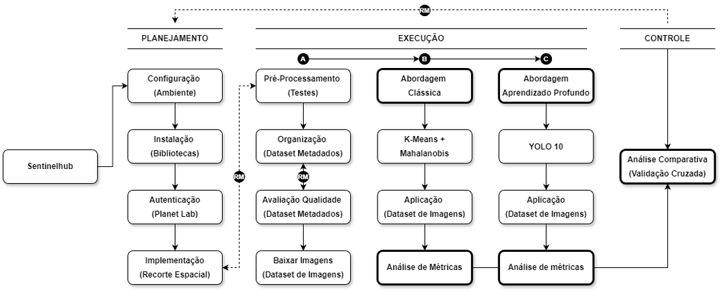

```python
# Exibir o pipeline
from IPython.display import Image

Image("Pipeline_VC.png", width=1400)
```

```python
# ========================================================================================================================
# BLOCO 1:      PLANEJAMENTO
#               Configuração Geral do Ambiente
#
# OBJETIVO:     Registrar metadados do ambiente, autor, data e garantir reprodutibilidade total
#               Ciência aberta, auditoria técnica, asseguração e revisão por pares
# ========================================================================================================================

# ETAPA 1: CABEÇALHO INSTITUCIONAL DO PROJETO
# -----------------------------------------------------------------------------------------------------------------------
print("=" * 110)
print("PROJETO: AUDITORIA AMBIENTAL EM USINAS HIDRELÉTRICAS")
print("         Asseguração Independente de Relatórios ESG via Dados Exógenos Satelitais")
print("         Configuação Geral do Ambiente")
print("=" *110)

# ETAPA 2: IMPORTAÇÃO DE MÓDULOS PADRÃO DO PYTHON
# ------------------------------------------------------------------------------------------------------------------------
import sys                              # Acesso ao interpretador Python (versão, caminhos, etc.)
import os                               # Interação com o sistema operacional (pastas, arquivos)
import platform                         # Informações sobre sistema operacional e hardware
import getpass                          # Captura do usuário atual sem exibir senha
from datetime import datetime           # Registro preciso de data e hora da execução
import time                             # Usado para criar pequenas pausas visuais durante a instalação
from datetime import datetime           # Para registrar o horário de término da instalação

inicio = time.time()

# ETAPA 3: REGISTRO DO AMBIENTE DE EXECUÇÃO (essencial para auditoria e ciência aberta)
# -----------------------------------------------------------------------------------------------------------------------
print("-" * 110)
print(f"Usuário.....................: {getpass.getuser()}")
print(f"Data e hora da execução.....: {datetime.now().strftime('%d/%m/%Y %H:%M:%S')}")
print(f"Sistema operacional.........: {platform.system()} {platform.release()} ({platform.version()})")
print(f"Processador.................: {platform.processor()}")
print(f"Python versão...............: {sys.version.split()[0]}")
print(f"Diretório de trabalho.......: {os.getcwd()}")
print(f"Interpretador Python........: {sys.executable}")

# ETAPA 4: VERIFICA SE ESTÁ RODANDO EM JUPYTER (para exibir widgets, caso interesse o executor dos notebook)
# -----------------------------------------------------------------------------------------------------------------------
try:
    from IPython import get_ipython
    jupyter_info = get_ipython().__class__.__name__
    print(f"Ambiente de execução........: Jupyter ({jupyter_info})")
except:
    print(f"Ambiente de execução........: Python padrão (script)")

# ETAPA 5: FINALIZAÇÃO
# -----------------------------------------------------------------------------------------------------------------------
tempo_total = time.time() - inicio               # tempo total em segundos (float)

# Converte para o formato HH:MM:SS
horas = int(tempo_total // 3600)
minutos = int((tempo_total % 3600) // 60)
segundos = tempo_total % 60
tempo_formatado = f"{horas:02d}:{minutos:02d}:{segundos:05.2f}"

print("\n" + "="*110)
print(f"Tempo de execução → {tempo_formatado} (hh:mm:ss)")
print(f"Finalizado em → {datetime.now().strftime('%d/%m/%Y às %H:%M:%S')}")
print("="*110)
```

```
==============================================================================================================
PROJETO: AUDITORIA AMBIENTAL EM USINAS HIDRELÉTRICAS
         Asseguração Independente de Relatórios ESG via Dados Exógenos Satelitais
         Configuação Geral do Ambiente
==============================================================================================================
--------------------------------------------------------------------------------------------------------------
Usuário.....................: renat
Data e hora da execução.....: 07/12/2025 15:47:51
Sistema operacional.........: Windows 11 (10.0.26100)
Processador.................: AMD64 Family 25 Model 80 Stepping 0, AuthenticAMD
Python versão...............: 3.13.7
Diretório de trabalho.......: c:\Users\renat\OneDrive\Mestrado em Contabilidade\2025\2025.2c Visão Computacional\VC_TF
Interpretador Python........: c:\Program Files\Python313\python.exe
Ambiente de execução........: Jupyter (ZMQInteractiveShell)

==============================================================================================================
Tempo de execução → 00:00:00.00 (hh:mm:ss)
Finalizado em → 07/12/2025 às 15:47:51
==============================================================================================================
```

```python
# =======================================================================================================================
# BLOCO 1:  PLANEJAMENTO
#           Instalação de Bibliotecas Essenciais (versão 2025 – YOLOv11 + HDBSCAN)
#
# Objetivo: Instalar/verificar todas as dependências do projeto de forma automática, garantindo reprodutibilidade
#           evitando conflitos de versão.
#           Cada linha tem comentário explicando para que serve.
# =======================================================================================================================

# ETAPA 1: CABEÇALHO INSTITUCIONAL DO PROJETO
# -----------------------------------------------------------------------------------------------------------------------
print("=" * 110)
print("PROJETO: AUDITORIA AMBIENTAL EM USINAS HIDRELÉTRICAS")
print("         Asseguração Independente de Relatórios ESG via Dados Exógenos Satelitais")
print("         Instalação Automática de Bibliotecas Essenciais (2025)")
print("=" * 110)

# ETAPA 2: IMPORTAÇÃO DE MÓDULOS PADRÃO DO PYTHON
# -----------------------------------------------------------------------------------------------------------------------
import subprocess                            # permite executar comandos do sistema (ex: pip install)
import sys                                   # acessa o caminho do Python atual (evita problemas em ambientes virtuais)
import time                                  # usado para pausas visuais e cronometrar o tempo total
from datetime import datetime                # para mostrar data e hora no final

# ETAPA 3: FUNÇÃO QUE INSTALA PACOTES AUTOMATICAMENTE
# Se o pacote já existir → só avisa. Se não existir → instala com pip automaticamente.
# -----------------------------------------------------------------------------------------------------------------------
import importlib.util                        # necessário para detecção 100% confiável de pacotes

def instalar_pacote(nome):
    """Verifica com importlib se o pacote está realmente instalado. Só instala se faltar."""
    nome_modulo = nome.replace('-', '_').split('.')[0]
    if nome_modulo in sys.modules or importlib.util.find_spec(nome_modulo) is not None:
        return True, "já instalada"
    else:
        print(f"   → Instalando {nome}...", end=" ")
        try:
            subprocess.check_call([sys.executable, "-m", "pip", "install", nome, "--quiet"],
                                  stdout=subprocess.DEVNULL, stderr=subprocess.DEVNULL)
            print("OK")
            return True, "instalada agora"
        except:
            print("FALHOU")
            return False, "FALHA"

# ETAPA 4: BARRA DE PROGRESSO (Só funciona no Jupyter/Colab)
# -----------------------------------------------------------------------------------------------------------------------
instalar_pacote("ipywidgets")
from IPython.display import display, HTML
import ipywidgets as widgets

# Criação da barra de progresso azul
progress_bar = widgets.FloatProgress(value=0, min=0, max=100, description='Progresso:',
                                     style={'bar_color': '#0066cc'}, layout=widgets.Layout(width='80%'))
status_label = widgets.HTML(value="<b>Iniciando instalação de todas as dependências...</b>")
display(widgets.VBox([status_label, progress_bar]))

# ETAPA 5: LISTA COMPLETA DE TODAS AS BIBLIOTECAS DO PROJETO (2025)
# -----------------------------------------------------------------------------------------------------------------------
bibliotecas = [
    # ─────────────────────────────── GEOESPACIAL & SATÉLITE ───────────────────────────────
    'sentinelhub',
    'rasterio',
    'geopandas',
    'shapely',
    'pyproj',
    'rtree',
    'folium',
    'earthpy',

    # ─────────────────────────────── ANÁLISE DE DADOS ───────────────────────────────
    'numpy',
    'pandas',
    'scipy',
    'scikit-learn',

    # ─────────────────────────────── VISÃO COMPUTACIONAL ───────────────────────────────
    'opencv-python',
    'Pillow',

    # ─────────────────────────────── DEEP LEARNING & YOLOv11 (ESSENCIAIS) ───────────────────────────────
    'torch',                # PyTorch – framework principal
    'torchvision',          # transforms e datasets
    'ultralytics',          # PACOTE OFICIAL DO YOLOv11 (2024-2025) – contém yolov11n/s/m/l/x
    'hdbscan',              # ← CLUSTERING NÃO SUPERVISIONADO (o que tu precisava!)
    'supervision',          # (OPCIONAL) anotações bonitas pós-YOLO

    # ─────────────────────────────── VISUALIZAÇÃO ───────────────────────────────
    'matplotlib',
    'seaborn',
    'plotly',

    # ─────────────────────────────── UTILIDADES GERAIS ───────────────────────────────
    'tqdm',
    'requests',
    'boto3',                # (OPCIONAL) AWS S3
    'openpyxl',
    'xlsxwriter',
]

# ETAPA 6: LOOP QUE INSTALA TUDO COM BARRA DE PROGRESSO
# -----------------------------------------------------------------------------------------------------------------------
total = len(bibliotecas)
concluidas = 0
inicio = time.time()

for pkg in bibliotecas:
    sucesso, msg = instalar_pacote(pkg)
    concluidas += 1
    progresso_percent = (concluidas / total) * 100
    progress_bar.value = progresso_percent
    status_label.value = f"<b>{concluidas}/{total} → {pkg.ljust(25)} {msg}</b>"
    time.sleep(0.07)

# ETAPA 7: IMPORTS DE TODAS AS BIBLIOTECAS (só roda depois que tudo está garantido)
# -----------------------------------------------------------------------------------------------------------------------
print("Carregando módulos e validando ambiente...")

# --- 1. Imports: Utilitários de Sistema e Excel ---
from openpyxl import load_workbook                   # Permite carregar e editar arquivos Excel (.xlsx) existentes
from openpyxl.styles import Font, PatternFill        # Classes para aplicar negrito, cores e estilos nas células do Excel
from openpyxl.styles import Alignment                # Classe para centralizar ou alinhar textos nas células
from openpyxl.utils import get_column_letter         # Converte números de índice (1, 2) em letras de coluna (A, B)
from pathlib import Path                             # Manipulação robusta de caminhos de arquivos (compatível Windows/Linux)
import os                                            # Interação com o Sistema Operacional (criar pastas, listar arquivos)
import json                                          # Manipulação de arquivos JSON (formatos de configuração)
import math                                          # Funções matemáticas básicas (teto, piso, raiz quadrada)
import requests                                      # Biblioteca para fazer requisições HTTP (download da web)
from glob import glob                                # Busca de arquivos usando padrões curinga (ex: *.png)
from datetime import datetime, timedelta             # Manipulação de datas, horas e intervalos de tempo

# --- 2. Imports: Dados Numéricos e Geoespaciais ---
import numpy as np                                   # Computação numérica de alta performance (arrays e matrizes)
import pandas as pd                                  # Manipulação de tabelas de dados (DataFrames)
import geopandas as gpd                              # Extensão do Pandas para dados geográficos (shapefiles)
from shapely.geometry import Point, Polygon          # Criação de geometrias vetoriais (pontos GPS, áreas de polígonos)
import rasterio                                      # Leitura e escrita de imagens de satélite (GeoTIFF)
from rasterio.plot import show as rio_show           # Função específica para plotar imagens raster do rasterio
from rasterio.transform import from_bounds           # Criação de transformações afins a partir de coordenadas geográficas
import pyproj                                        # Biblioteca para conversão entre sistemas de coordenadas (CRS)
import boto3                                         # SDK da Amazon AWS (para acessar buckets S3 se necessário)

# --- 3. Imports: Machine Learning Clássico & Estatística ---
from numpy.linalg import inv                         # Álgebra linear: cálculo de inversa de matrizes
from sklearn.cluster import KMeans                   # Algoritmo de clusterização (K-Médias) para agrupar dados
from sklearn.metrics import confusion_matrix         # Gera a matriz de erros (Verdadeiro Positivo, Falso Negativo, etc.)
from sklearn.metrics import classification_report    # Gera relatório completo de métricas (Precision, Recall, F1)
from sklearn.metrics import precision_score          # Função isolada para cálculo de Precisão
from sklearn.metrics import recall_score             # Função isolada para cálculo de Recall (Sensibilidade)
from sklearn.metrics import f1_score                 # Função isolada para cálculo do F1-Score

# --- 4. Imports: Deep Learning & YOLO (O "Core Business") ---
import torch                                         # Framework base de Deep Learning (PyTorch)
import torchvision                                   # Utilitários de visão computacional do ecossistema PyTorch
from ultralytics import YOLO                         # Classe principal para carregar e treinar modelos YOLOv11
from ultralytics.utils.metrics import box_iou        # Função para calcular Intersection over Union (IoU) entre caixas
from ultralytics.utils.plotting import Annotator     # Ferramenta para desenhar caixas delimitadoras nas imagens
import hdbscan                                       # Algoritmo de Clustering Hierárquico (alternativa robusta ao KMeans)
import supervision as sv                             # Biblioteca auxiliar para visualização avançada de detecções

# --- 5. Imports: Visualização de Dados e Imagens ---
import cv2                                           # OpenCV: Biblioteca padrão da indústria para processamento de imagem
import matplotlib.pyplot as plt                      # Biblioteca padrão para plotagem de gráficos 2D
import seaborn as sns                                # Biblioteca de visualização estatística (gráficos mais bonitos)
import plotly.express as px                          # Biblioteca para gráficos interativos (HTML/Web)
import folium                                        # Biblioteca para criação de mapas interativos (tipo Google Maps)
from tqdm import tqdm                                # Cria barras de progresso visuais em loops longos

print("SUCESSO: Todas as bibliotecas foram carregadas e estão prontas para uso!")

# ETAPA 8: FINALIZAÇÃO
# -----------------------------------------------------------------------------------------------------------------------
tempo_total = time.time() - inicio
horas = int(tempo_total // 3600)
minutos = int((tempo_total % 3600) // 60)
segundos = tempo_total % 60
tempo_formatado = f"{horas:02d}:{minutos:02d}:{segundos:05.2f}"

progress_bar.bar_style = 'success'
progress_bar.value = 100
status_label.value = f"<b>INSTALAÇÃO CONCLUÍDA → {total} pacotes em {tempo_formatado}</b>"

print("\n" + "="*110)
print(f"Tempo de execução → {tempo_formatado} (hh:mm:ss)")
print(f"Finalizado em → {datetime.now().strftime('%d/%m/%Y às %H:%M:%S')}")
print("="*110)
```

```
==============================================================================================================
PROJETO: AUDITORIA AMBIENTAL EM USINAS HIDRELÉTRICAS
         Asseguração Independente de Relatórios ESG via Dados Exógenos Satelitais
         Instalação Automática de Bibliotecas Essenciais (2025)
==============================================================================================================
```

```
VBox(children=(HTML(value='<b>Iniciando instalação de todas as dependências...</b>'), FloatProgress(value=0.0,…
```

```
   → Instalando scikit-learn... OK
   → Instalando opencv-python... OK
   → Instalando Pillow... OK
Carregando módulos e validando ambiente...
SUCESSO: Todas as bibliotecas foram carregadas e estão prontas para uso!

==============================================================================================================
Tempo de execução → 00:00:10.08 (hh:mm:ss)
Finalizado em → 07/12/2025 às 15:48:06
==============================================================================================================
```

```python
# ========================================================================================================================
# BLOCO 1:      PLANEJAMENTO
#               Autenticação e Configuração do Sentinel Hub
#
# OBJETIVO:     Estabelecer conexão segura e funcional com a API do Sentinel Hub
#               Permite acesso programático a imagens Sentinel-2
# ========================================================================================================================

# ETAPA 1: CABEÇALHO INSTITUCIONAL DO PROJETO
# ------------------------------------------------------------------------------------------------------------------------
print("=" * 110)
print("PROJETO: AUDITORIA AMBIENTAL EM USINAS HIDRELÉTRICAS")
print("         Asseguração Independente de Relatórios ESG via Dados Exógenos Satelitais")
print("         Autenticação e Configuração do Sentinel Hub")
print("=" *110)

# ETAPA 2: IMPORTAÇÃO DE MÓDULOS DAS CLASSES OFICIAIS DO PACOTE SENTINEL HUB (instalado na célula pregressa)
# ------------------------------------------------------------------------------------------------------------------------
from sentinelhub import (
    SHConfig,                   # classe para montar a configuração da conta (client_id + secret)
    SentinelHubCatalog,         # objeto que faz busca no catálogo STAC (essencial pro Bloco 2)
    SentinelHubRequest,         # classe principal da Process API – monta e executa download de imagens
    SentinelHubDownloadClient,  # cliente para downloads paralelos (várias imagens ao mesmo tempo)
    DataCollection,             # escolhe a coleção: SENTINEL2_L2A, SENTINEL2_L1C, LANDSAT etc.
    MimeType,                   # define formato de saída: TIFF, PNG, JPEG2000 etc.
    CRS,                        # sistemas de coordenada → CRS.WGS84, CRS.POP_WEB etc.
    BBox,                       # bounding box retangular (o que tu usa na AOI)
    bbox_to_dimensions,         # função que calcula (width, height) em pixels a partir do BBox + resolução
    Geometry,                   # para usar polígonos irregulares no lugar de bbox (futuro)
    parse_time,                 # converte strings "2025-01-01" em datetime que o Sentinel Hub aceita
    DownloadFailedException     # exceção específica quando o download falhar – pra tratar com try/except
)

# ETAPA 3: BARRA DE PROGRESSO (Só funciona no Jupyter/Colab)
# -----------------------------------------------------------------------------------------------------------------------
try:
    from IPython.display import display  # Função para exibir componentes gráficos no Jupyter
    import ipywidgets as widgets         # Biblioteca para criar barra de progresso e rótulos
    use_widgets = True                   # Flag indicando suporte a widgets
except ImportError:
    use_widgets = False                  # Se não houver suporte, desativa uso de widgets

# Cria barra de progresso estilizada
if use_widgets:
    progress_bar = widgets.FloatProgress(
        value=0,                                            # Inicia a barra em 0%
        min=0, max=100,                                     # Valores mínimo e máximo (0 a 100%)
        description='Progresso:',                           # Texto exibido ao lado da barra
        bar_style='info',                                   # Estilo visual (cor padrão informativa)
        style={'bar_color': '#1f77b4'},                   # Cor azul personalizada para a barra
        layout=widgets.Layout(width='80%', height='30px')   # Tamanho da barra
    )
    status_text = widgets.HTML(                             # Campo de texto dinâmico para mensagens de status
        value="<b>Iniciando configuração do Sentinel Hub...</b>"
    )
    display(widgets.VBox([status_text, progress_bar]))      # Exibe barra + texto empilhados verticalmente

# Definição das etapas do processo com peso percentual (para barra de progresso)
etapas_configuracao = {
    'carregar configuração': 30,         # Etapa 1: montar objeto de configuração com credenciais
    'registrar área de interesse': 20,   # Etapa 2: definir a área geográfica (AOI)
    'criar evalscript': 50               # Etapa 3: criar o script principal de 7 bandas
}

# Variáveis de controle do progresso
total_etapas = len(etapas_configuracao)  # Número total de etapas planejadas
etapa_atual = 0                          # Contador da etapa em execução
progresso_acumulado = 0                  # Acúmulo percentual para a barra
inicio = time.time()                     # Marca o instante inicial (para calcular tempo total)

# ETAPA 4: CARREGAR CONFIGURAÇÃO COM CREDENCIALS DO SENTINEL HUB
# ------------------------------------------------------------------------------------------------------------------------
etapa_atual += 1                                                     # Avança contador de etapa para 1/3
progresso_acumulado += etapas_configuracao['carregar configuração']  # Soma peso da etapa

if use_widgets:
    progress_bar.value = progresso_acumulado                          # Atualiza barra de progresso
    status_text.value = (                                             # Atualiza texto de status
        f"<b>({etapa_atual}/{total_etapas}) Carregando credenciais do Sentinel Hub...</b>"
    )

# Preenche credenciais específicas da sua conta (obtidas no painel Sentinel Hub)
config = SHConfig()                                               # Cria o próprio objeto config
config.sh_client_id     = 'ac94a503-6386-43d5-b20b-449a40bfd9dd'  # ID do cliente OAuth2
config.sh_client_secret = 'HUyyF2J7jOr2YBf3LrTwQthMrc2hKPpV'      # Segredo do cliente OAuth2
config.instance_id      = '3cce22e4-9b1e-454c-8f3e-d52f813c07bb'  # ID da configuração (Instance ID)

# Verificação simples: garante que nenhum dos campos obrigatórios está vazio
if not (config.sh_client_id and config.sh_client_secret and config.instance_id):
    raise ValueError("❌ Credenciais do Sentinel Hub ausentes ou incompletas. Verifique client_id, secret e instance_id.")

time.sleep(1.0)                          # Pequena pausa apenas para feedback visual

# ETAPA 5: REGISTRAR A ÁREA DE INTERESSE (AOI)
# ------------------------------------------------------------------------------------------------------------------------
etapa_atual += 1                                                            # Avança contador de etapa para 2/3
progresso_acumulado += etapas_configuracao['registrar área de interesse']   # Atualiza progresso

if use_widgets:
    progress_bar.value = progresso_acumulado                           # Atualiza barra de progresso
    status_text.value = (                                              # Atualiza texto de status
        f"<b>({etapa_atual}/{total_etapas}) Definindo área de interesse (BBox)...</b>"
    )

# Define a área de interesse — aqui usamos um pequeno quadrado em torno da UHE Pery
lat_centro = -27.45545                    # Latitude aproximada da usina (graus decimais)
lon_centro = -50.64181                    # Longitude aproximada da usina (graus decimais)
raio_km = 2.0                             # Tamanho do raio (~2 km, ordem de grandeza)

# Cálculo do Buffer em graus
dlat = raio_km / 110.574
dlon = raio_km / (111.320 * abs(math.cos(math.radians(lat_centro))))

# Monta as coordenadas da bbox (bounding box) da AOI (Área de Interesse)
bbox_coords = [
    lon_centro - dlon,
    lat_centro - dlat,
    lon_centro + dlon,
    lat_centro + dlat
]

# Cria objeto BBox com CRS WGS84 (latitude/longitude)
aoi_bbox = BBox(bbox=bbox_coords, crs=CRS.WGS84)

time.sleep(1.0)                          # Pequena pausa para estabilidade visual

# ------------------------------------------------------------------------------------------------------------------------
# DEFINIÇÃO DO EVALSCRIPT PRINCIPAL DO PROJETO (7 bandas + dataMask)
# ------------------------------------------------------------------------------------------------------------------------
etapa_atual += 1
progresso_acumulado += etapas_configuracao['criar evalscript']

if use_widgets:
    progress_bar.value = progresso_acumulado
    status_text.value = "<b>Criando evalscript principal...</b>"

EVALSCRIPT_7_BANDAS = """
//VERSION=3
function setup() {
  return {
    input: [{ bands: ["B02","B03","B04","B08","B11","B12","dataMask"] }],
    output: { bands: 7, sampleType: "FLOAT32" }
  };
}
function evaluatePixel(s) {
  return [s.B02, s.B03, s.B04, s.B08, s.B11, s.B12, s.dataMask];
}
"""

if use_widgets:
    status_text.value = "<b style='color:green;'>✅ Configuração concluída!</b>"
    progress_bar.bar_style = 'success'  # Muda a cor para verde

time.sleep(1.0)                                                       # Pausa mínima para estabilidade visual

# ETAPA 7: FINALIZAÇÃO
# -----------------------------------------------------------------------------------------------------------------------
tempo_total = time.time() - inicio                          # tempo total em segundos (float)

# Converte para o formato HH:MM:SS
horas = int(tempo_total // 3600)
minutos = int((tempo_total % 3600) // 60)
segundos = tempo_total % 60
tempo_formatado = f"{horas:02d}:{minutos:02d}:{segundos:05.2f}"

print("\n" + "="*110)
print(f"Tempo de execução → {tempo_formatado} (hh:mm:ss)")
print(f"Finalizado em → {datetime.now().strftime('%d/%m/%Y às %H:%M:%S')}")
print("="*110)
```

```
==============================================================================================================
PROJETO: AUDITORIA AMBIENTAL EM USINAS HIDRELÉTRICAS
         Asseguração Independente de Relatórios ESG via Dados Exógenos Satelitais
         Autenticação e Configuração do Sentinel Hub
==============================================================================================================
```

```
VBox(children=(HTML(value='<b>Iniciando configuração do Sentinel Hub...</b>'), FloatProgress(value=0.0, bar_st…
```

```
==============================================================================================================
Tempo de execução → 00:00:03.02 (hh:mm:ss)
Finalizado em → 06/12/2025 às 18:54:16
==============================================================================================================
```

```python
# ========================================================================================================================
# BLOCO 1:  PLANEJAMENTO
#           Implementação do Recorte Espacial (Área de interesse)
#
# OBJETIVO: Definir apenas a geometria (AOI) e o período temporal de análise.
#           Variáveis criadas aqui serão usadas em TODAS as células do Bloco 2 (Execução).
# =======================================================================================================================

# ETAPA 1: CABEÇALHO INSTITUCIONAL DO PROJETO
# -----------------------------------------------------------------------------------------------------------------------
print("=" * 110)
print("PROJETO: AUDITORIA AMBIENTAL EM USINAS HIDRELÉTRICAS")
print("         Asseguração Independente de Relatórios ESG via Dados Exógenos Satelitais")
print("         Implementação do Recorte Espacial (Área de interesse)")
print("         → Buffer circular de 2 km centrado nas coordenadas")    # Descrição do recorte espacial
print("=" *110)

# ETAPA 2: BARRA DE PROGRESSO (Só funciona no Jupyter/Colab)
# -----------------------------------------------------------------------------------------------------------------------
try:
    progress = widgets.FloatProgress(                     # Cria widget de barra de progresso
        value=0,                                          # Valor inicial (0% concluído)
        min=0,                                            # Limite inferior da barra
        max=100,                                          # Limite superior da barra
        description='Progresso:',                         # Rótulo exibido à esquerda
        style={'bar_color': '#1f77b4'},                 # Cor azul profissional da barra
        layout=widgets.Layout(width='85%', height='30px') # Tamanho da barra
    )
    status = widgets.HTML(
        value="<b>Iniciando definição do recorte espacial...</b>" # Texto HTML para mensagens de status
    )
    display(widgets.VBox([status, progress]))   # Exibe barra + texto empilhados verticalmente
    use_widgets = True                          # Flag indicando que widgets estão ativos
except ImportError:                             # Caso rode em ambiente sem suporte a widgets
    use_widgets = False                         # Desabilita uso de widgets

inicio = time.time()                            # Inicia contagem de tempo total da célula

# ETAPA 3: DEFINIÇÃO DA GEOMETRIA DA USINA HIDRELÉTRICA PERY (AOI)
# ------------------------------------------------------------------------------------------------------------------------
if use_widgets:
    progress.value = 50                      # Atualiza barra para 50% na etapa 1
    status.value = "<b>(1/2) Definindo coordenadas da UHE Pery...</b>"  # Mensagem ao usuário

# Dicionário com metadados da usina — útil para relatórios, pôster e artigo
usina_info = {
    'nome': 'Usina Hidrelétrica Pery',          # Nome oficial da usina
    'operador': 'CELESC Geração S.A.',          # Empresa operadora
    'municipio': 'Curitibanos | Campos Novos',  # Municípios envolvidos
    'estado': 'Santa Catarina',                 # Estado da federação
    'rio': 'Rio Canoas',                        # Rio em que a usina está localizada
    'raio_buffer_km': raio_km,                  # Raio do buffer circular conceitual (km)
    'centro_lat': lat_centro,                   # Latitude do centro da AOI
    'centro_lon': lon_centro,                   # Longitude do centro da AOI
    'bbox_wgs84': aoi_bbox.geometry             # Coordenadas da bounding box em WGS84
}

time.sleep(1.0)                                 # Pequena pausa para o usuário perceber o progresso

# ETAPA 4: DEFINIÇÃO DO PERÍODO TEMPORAL DE ANÁLISE
# ------------------------------------------------------------------------------------------------------------------------
if use_widgets:
    progress.value = 100                     # Atualiza barra para 100% na etapa 2
    progress.bar_style = 'success'          # Muda cor da barra para verde (sucesso)
    status.value = "<b style='color:green;'>(2/2) Período definido → pronto!</b>"

# Período completo de análise do projeto (5 anos completos + 2025 parcial)
data_inicio = '2021-01-01'                   # Data inicial no formato ISO 8601 (YYYY-MM-DD)
data_fim    = '2025-10-31'                   # Data final no formato ISO 8601 (YYYY-MM-DD)

# ETAPA 5: DERIVAÇÃO DOS ANOS E DAS ESTAÇÕES DO ANO DENTRO DO PERÍODO TEMPORAL DE ANÁLISE
# ------------------------------------------------------------------------------------------------------------------------
# Lista de anos efetivamente cobertos pelo período do projeto
ano_ini = int(data_inicio[:4])               # Extrai ano inicial como inteiro
ano_fim = int(data_fim[:4])                  # Extrai ano final como inteiro
anos_projeto = list(range(ano_ini, ano_fim + 1))  # Cria lista de anos de ano_ini até ano_fim (inclusive)

# Função auxiliar: gera estações "teóricas" para um ano, em formato datetime.date
def _gerar_estacoes_para_ano(ano: int):
    from datetime import date
    return [
        ("primavera", date(ano,  9, 23), date(ano, 12, 21)),   # Primavera: 23/set a 21/dez
        ("verão",     date(ano, 12, 22), date(ano + 1, 3, 20)),# Verão: 22/dez a 20/mar (cruza ano seguinte)
        ("outono",    date(ano,  3, 21), date(ano,  6, 20)),   # Outono: 21/mar a 20/jun
        ("inverno",   date(ano,  6, 21), date(ano,  9, 22)),   # Inverno: 21/jun a 22/set
    ]

# Converte limites globais em objetos datetime.date
_limite_ini = datetime.fromisoformat(data_inicio).date()  # Converte string → objeto date
_limite_fim = datetime.fromisoformat(data_fim).date()     # Converte string → objeto date

# Dicionário principal: para cada ano, lista de tuplas (estação, data_ini, data_fim) em string ISO
estacoes_projeto = {}                       # Inicializa dicionário vazio

for ano in anos_projeto:                    # Itera sobre cada ano coberto pelo projeto
    estacoes_ano = []                       # Lista local para armazenar estações válidas do ano
    for nome, ini_est, fim_est in _gerar_estacoes_para_ano(ano):  # Gera estações teóricas
        # "Corta" a estação para não sair do período global do projeto
        ini_clip = max(ini_est, _limite_ini)  # Data inicial da estação limitada pelo início global
        fim_clip = min(fim_est, _limite_fim)  # Data final da estação limitada pelo fim global
        if ini_clip <= fim_clip:           # Garante que a estação ainda faça sentido temporalmente
            estacoes_ano.append(
                (nome, ini_clip.isoformat(), fim_clip.isoformat())  # Armazena como strings ISO
            )
    if estacoes_ano:                       # Se o ano tiver pelo menos uma estação válida
        estacoes_projeto[ano] = estacoes_ano  # Registra no dicionário principal

# Resumo para conferência das estações definidas
print("\nEstações definidas para o período do projeto:")
for ano in sorted(estacoes_projeto.keys()):   # Itera anos em ordem crescente
    linhas = [f"{nome}: {ini} → {fim}" for (nome, ini, fim) in estacoes_projeto[ano]]  # Formata cada estação
    print(f"  • {ano}: " + " | ".join(linhas))  # Imprime linha resumida por ano

# ETAPA 6: VALIDAÇÃO E RESUMO DAS VARIÁVEIS
# ------------------------------------------------------------------------------------------------------------------------
# Cálculo conceitual da área do buffer circular (π · r²), em km²
area_km2 = math.pi * (raio_km ** 2)        # Área aproximada do buffer circular (2 km de raio)

print("\n" + " RECORTE ESPACIAL ".center(110, "-"))
print(f"  • Usina: {usina_info['nome']} ({usina_info['operador']})")  # Nome + operador
print(f"  • Localização: {usina_info['municipio']}, {usina_info['estado']}")  # Município + estado
print(f"  • Rio: {usina_info['rio']}")                                 # Rio principal
print(f"  • Área de interesse (AOI): {area_km2:.2f} km²")              # Área conceitual do buffer circular
print(f"  • Período de análise: {data_inicio[:4]} → {data_fim[:4]}")   # Anos inicial e final

# ETAPA 7: FINALIZAÇÃO
# -----------------------------------------------------------------------------------------------------------------------
tempo_total = time.time() - inicio                          # tempo total em segundos (float)

# Converte para o formato HH:MM:SS
horas = int(tempo_total // 3600)
minutos = int((tempo_total % 3600) // 60)
segundos = tempo_total % 60
tempo_formatado = f"{horas:02d}:{minutos:02d}:{segundos:05.2f}"

print("\n" + "="*110)
print(f"Tempo de execução → {tempo_formatado} (hh:mm:ss)")
print(f"Finalizado em → {datetime.now().strftime('%d/%m/%Y às %H:%M:%S')}")
print("="*110)
```

```
==============================================================================================================
PROJETO: AUDITORIA AMBIENTAL EM USINAS HIDRELÉTRICAS
         Asseguração Independente de Relatórios ESG via Dados Exógenos Satelitais
         Implementação do Recorte Espacial (Área de interesse)
         → Buffer circular de 2 km centrado nas coordenadas
==============================================================================================================
```

```
VBox(children=(HTML(value='<b>Iniciando definição do recorte espacial...</b>'), FloatProgress(value=0.0, descr…
```

```
Estações definidas para o período do projeto:
  • 2021: primavera: 2021-09-23 → 2021-12-21 | verão: 2021-12-22 → 2022-03-20 | outono: 2021-03-21 → 2021-06-20 | inverno: 2021-06-21 → 2021-09-22
  • 2022: primavera: 2022-09-23 → 2022-12-21 | verão: 2022-12-22 → 2023-03-20 | outono: 2022-03-21 → 2022-06-20 | inverno: 2022-06-21 → 2022-09-22
  • 2023: primavera: 2023-09-23 → 2023-12-21 | verão: 2023-12-22 → 2024-03-20 | outono: 2023-03-21 → 2023-06-20 | inverno: 2023-06-21 → 2023-09-22
  • 2024: primavera: 2024-09-23 → 2024-12-21 | verão: 2024-12-22 → 2025-03-20 | outono: 2024-03-21 → 2024-06-20 | inverno: 2024-06-21 → 2024-09-22
  • 2025: primavera: 2025-09-23 → 2025-10-31 | outono: 2025-03-21 → 2025-06-20 | inverno: 2025-06-21 → 2025-09-22

---------------------------------------------- RECORTE ESPACIAL ----------------------------------------------
  • Usina: Usina Hidrelétrica Pery (CELESC Geração S.A.)
  • Localização: Curitibanos | Campos Novos, Santa Catarina
  • Rio: Rio Canoas
  • Área de interesse (AOI): 12.57 km²
  • Período de análise: 2021 → 2025

==============================================================================================================
Tempo de execução → 00:00:01.01 (hh:mm:ss)
Finalizado em → 06/12/2025 às 18:54:40
==============================================================================================================
```

```python
# ========================================================================================================================
# BLOCO 2:     EXECUÇÃO - LETRA A
#              Pré-processamento (Testes)
#
# OBJETIVO:    Testar as imagens de satélite com garantia de visualização de imagens
#              Requer BLOCO 1 executado
# ========================================================================================================================

# ETAPA 1: CABEÇALHO INSTITUCIONAL DO PROJETO
# -----------------------------------------------------------------------------------------------------------------------
print("=" * 110)
print("PROJETO: AUDITORIA AMBIENTAL EM USINAS HIDRELÉTRICAS")
print("         Asseguração Independente de Relatórios ESG via Dados Exógenos Satelitais")
print("         Pré-processamento das imagens de satélite para testar a visualização")
print("=" *110)

# ETAPA 2: BARRA DE PROGRESSO (Só funciona no Jupyter/Colab)
# -----------------------------------------------------------------------------------------------------------------------
try:
    progress = widgets.FloatProgress(                          # Cria a barra de progresso flutuante
        value=0,                                               # Valor inicial = 0%
        min=0, max=100,                                        # Escala de 0 a 100%
        description='Progresso:',                              # Texto fixo à esquerda da barra
        style={'bar_color': '#1f77b4', 'description_width': 'initial'},  # Cor azul padrão + texto alinhado
        layout=widgets.Layout(width='80%', height='30px')      # Tamanho fixo e bonito (80% da largura)
    )
    status = widgets.HTML(value="<b>Iniciando pré-processamento...</b>")  # Texto dinâmico acima da barra
    display(widgets.VBox([status, progress]))                  # Exibe texto + barra empilhados verticalmente
    use_widgets = True                                         # Flag indicando que os widgets estão disponíveis
except Exception:                                              # Caso não esteja em Jupyter/Colab
    use_widgets = False                                        # Desativa a barra silenciosamente

inicio = time.time()                                           # Inicia cronômetro do bloco

# ETAPA 3: PARÂMETROS DE PROCESSAMENTO
# ------------------------------------------------------------------------------------------------------------------------
colecao_imagens = DataCollection.SENTINEL2_L2A                # Coleção Sentinel-2 nível 2A (refletância corrigida)
anos = sorted(anos_projeto)                                   # Ordena os anos vindos do BLOCO 1
total_anos = len(anos)                                        # ← total de anos para a barra
processados = 0                                               # ← contador para progresso
raio_km_local = raio_km                                       # Lê raio do buffer do dicionário, se existir
area_km2 = math.pi * (raio_km_local ** 2)                     # Área aproximada do buffer circular (π·r²)

# Cria pasta de saída para o grid de imagens, se ainda não existir
os.makedirs("RESULTADOS/GRID_SENTINEL", exist_ok=True)        # Pasta para salvar PNGs do grid

# Evalscript com 7 bandas brutas (FLOAT32) + dataMask separada
# Isso permite baixar os dados brutos e ter máscara de nuvens/dados válidos
evalscript_multispectral_bruto = EVALSCRIPT_7_BANDAS

# ETAPA 4: GRID DE IMAGENS POR ESTAÇÃO DO ANO
# ------------------------------------------------------------------------------------------------------------------------
try:
    todas_imagens = []                                           # Lista agregadora com tuplas por ano
    ano_ref = anos[0]                                            # Ano de referência (primeiro ano do projeto)
    estacoes_ref = estacoes_projeto[ano_ref]                     # Lista de (nome, ini_iso, fim_iso) para ano_ref
    estacoes_labels = [nome for (nome, _, _) in estacoes_ref]    # Apenas nomes das estações (para cabeçalho)
    num_estacoes = len(estacoes_labels)                          # Quantidade de colunas no grid

    for i, ano in enumerate(anos):                               # Loop principal por ano
        if use_widgets:
            processados += 1                                                            # Incrementa contador de anos concluídos
            progress.value = (processados / total_anos) * 100                           # Avança suavemente até 100%
            status.value = f"<b>Processando ano {ano} ({processados}/{total_anos})</b>" # Mostra progresso real

        imagens_ano = []                                         # Lista de caminhos de imagens PNG salvas localmente
        datas_ano = []                                           # Lista de rótulos de datas/intervalos
        urls_validas = []                                        # Lista booleana de sucesso (para compatibilidade)

        estacoes_ano = estacoes_projeto.get(ano, [])             # Recupera estações desse ano
        limite_estacoes = min(len(estacoes_ano), num_estacoes)   # Garante mesmo número de colunas

        for idx in range(limite_estacoes):                       # Itera pelas estações disponíveis para o ano
            estacao, data_inicio_estacao, data_fim_estacao = estacoes_ano[idx]  # Desempacota tupla

            try:
                # Monta requisição Sentinel Hub para a estação específica
                req_estacao = SentinelHubRequest(
                    evalscript=evalscript_multispectral_bruto,
                    input_data=[
                        SentinelHubRequest.input_data(
                            colecao_imagens,
                            time_interval=(data_inicio_estacao, data_fim_estacao),
                            other_args={"dataFilter": {"maxCloudCoverage": 30}}
                        )
                    ],
                    responses=[
                        SentinelHubRequest.output_response("default", MimeType.TIFF)
                    ],
                    bbox=aoi_bbox,
                    size=(400, 400),
                    config=config
                )
```

```python
                # Download dos dados brutos (7 canais: 6 bandas + dataMask)
                dados = req_estacao.get_data()[0]                        # (400, 400, 7)

                # Separa bandas e máscara
                bandas = dados[:, :, :6].astype(np.float32)              # 6 bandas espectrais
                mask_raw = dados[:, :, 6]                                # dataMask (0.0 ou 1.0)
                mask = mask_raw > 0.5                                    # True = pixel válido

                # Rejeita imagem com menos de 30% de pixels válidos
                percentual_valido = mask.mean()
                if percentual_valido < 0.3:
                    raise ValueError(f"Poucos pixels válidos: {percentual_valido:.1%}")

                # Extrai RGB (B04, B03, B02) e normaliza
                rgb = bandas[:, :, [2, 1, 0]]                            # True color: B04, B03, B02
                rgb = rgb / 10000.0                                      # L2A → refletância 0–1

                # APLICAÇÃO CORRETA DO CONTRASTE
                # Calcula percentis para normalização robusta
                p_low, p_high = np.percentile(rgb[mask], (2, 98), axis=0)

                # Normaliza cada banda individualmente
                rgb_norm = np.zeros_like(rgb)
                for band in range(3):
                    band_data = rgb[:, :, band]
                    band_norm = (band_data - p_low[band]) / (p_high[band] - p_low[band] + 1e-10)
                    rgb_norm[:, :, band] = np.clip(band_norm, 0, 1)

                # Aplica gamma para melhorar visualização
                rgb_gamma = np.power(rgb_norm, 0.7)  # Gamma 0.7 para realçar cores

                # Converte para uint8
                img_rgb = (rgb_gamma * 255).astype(np.uint8)

                # Aplica a máscara (pixels inválidos = preto)
                img_rgb[~mask] = [0, 0, 0]  # RGB preto para nuvens/água/outros inválidos

                # SALVA PNG VISUAL (OpenCV usa BGR, converte corretamente)
                caminho_png = os.path.join("RESULTADOS/GRID_SENTINEL", f"S2_{ano}_{estacao}.png")
                # Converte RGB para BGR para OpenCV
                img_bgr = cv2.cvtColor(img_rgb, cv2.COLOR_RGB2BGR)
                cv2.imwrite(caminho_png, img_bgr)

                # SALVA GEOTIFF com 6 bandas + máscara original
                dados_geotiff = np.concatenate([bandas, mask_raw[..., np.newaxis]], axis=-1)
                caminho_tif = os.path.join("RESULTADOS/GRID_SENTINEL", f"S2_{ano}_{estacao}_6bandas.tif")

                west, south, east, north = aoi_bbox
                transform = from_bounds(west, south, east, north, 400, 400)

                with rasterio.open(
                    caminho_tif, 'w',
                    driver='GTiff',
                    height=400, width=400,
                    count=7, dtype='float32',
                    crs='EPSG:4326',
                    transform=transform,
                    compress='deflate'
                ) as dst:
                    for b in range(7):
                        dst.write(dados_geotiff[:, :, b], b + 1)

                # Alimenta o grid com o PNG visual
                imagens_ano.append(caminho_png)
                urls_validas.append(True)
                datas_ano.append(f"{data_inicio_estacao} → {data_fim_estacao}")

            except Exception as e:
                print(f"    ❌ FAILED {ano} - {estacao} → {e}")
                imagens_ano.append(None)
                urls_validas.append(False)
                datas_ano.append("sem dados")

        # Se o ano tiver menos estações do que o cabeçalho, preenche com espaços vazios
        while len(imagens_ano) < num_estacoes:
            imagens_ano.append(None)
            urls_validas.append(False)
            datas_ano.append("sem imagem")

        todas_imagens.append((ano, imagens_ano, datas_ano, urls_validas))

    # Grid HTML
    print("\n" + "=" * 110)
    print("GRID DE IMAGENS POR ESTAÇÃO DO ANO - GARANTIA DE VISUALIZAÇÃO")
    print("=" * 110)

    # Cabeçalho do grid (linha com ANO + nome das estações)
    header_html = """
    <div style='display: flex; align-items: center; margin-bottom: 20px; background: #f8f9fa; padding: 15px; border-radius: 10px;'>
        <div style='width: 100px; font-weight: bold; text-align: center; font-size: 16px;'>ANO</div>
    """
    for nome_estacao in estacoes_labels:                        # Itera sobre nomes de estações
        header_html += f"<div style='width: 180px; font-weight: bold; text-align: center; font-size: 16px; margin: 0 5px; text-transform: uppercase;'>{nome_estacao}</div>"
    header_html += "</div>"
    display(HTML(header_html))                                  # Exibe linha de cabeçalho

    # Linhas do grid, uma por ano
    for ano_grid, imagens, datas, validas in todas_imagens:     # Itera sobre cada ano
        linha_html = f"""
        <div style='display: flex; align-items: center; margin: 20px 0; padding: 15px; background: {"#f0f7ff" if ano_grid % 2 == 0 else "#ffffff"}; border-radius: 8px;'>
            <div style='width: 100px; font-weight: bold; text-align: center; font-size: 18px; color: #1f77b4;'>{ano_grid}</div>
        """

        for caminho_img, data, eh_valida in zip(imagens, datas, validas):  # Itera colunas (estações)
            linha_html += "<div style='width: 180px; text-align: center; margin: 0 5px;'>"

            if caminho_img and eh_valida:                    # Caso haja imagem válida salva em disco
                linha_html += f"""
                <div style='border: 3px solid #28a745; border-radius: 8px; padding: 5px; background: white;'>
                    <img src='{caminho_img}'
                         style='width: 150px; height: 150px; object-fit: cover; display: block; margin: 0 auto;' />
                    <div style='font-size: 11px; margin-top: 8px; color: #495057; font-weight: bold;'>{data}</div>
                    <div style='font-size: 9px; color: #28a745;'>✓ Disponível</div>
                </div>
                """
            else:                                            # Caso não haja imagem (ou erro)
                linha_html += """
                <div style='width: 150px; height: 150px; border: 3px dashed #6c757d; border-radius: 8px;
                            display: flex; align-items: center; justify-content: center; color: #6c757d;
                            background: #f8f9fa; margin: 0 auto; font-size: 12px; text-align: center;'>
                    Nenhuma imagem<br>disponível
                </div>
                """
```

```python
            linha_html += "</div>"                          # Fecha célula individual

        linha_html += "</div>"                              # Fecha linha do ano
        display(HTML(linha_html))                           # Exibe HTML da linha

    # Estatísticas finais do grid
    total_imagens = sum(sum(validas) for _, _, _, validas in todas_imagens)  # Soma de todas as células válidas
    print(f"\n• ESTATÍSTICAS: {total_imagens}/{len(anos) * num_estacoes} imagens carregadas com sucesso")
    print(f"• Período (anos efetivos): {anos[0]} a {anos[-1]} ({len(anos)} anos)")

except Exception as e:                                       # Tratamento de erros na etapa do grid
    print(f"• ERRO NO GRID: {e}")
    import traceback
    traceback.print_exc()

time.sleep(1)                                                # Pausa simbólica entre etapas

# Finalização limpa da barra de progresso
if use_widgets:
    progress.value = 100                                                   # Força 100% (evita 99.8% por arredondamento)
    status.value = "<b>Pré-processamento concluído – todos os anos processados</b>"

# ETAPA 5: FINALIZAÇÃO
# -----------------------------------------------------------------------------------------------------------------------
tempo_total = time.time() - inicio                          # tempo total em segundos (float)

# Converte para o formato HH:MM:SS
horas = int(tempo_total // 3600)
minutos = int((tempo_total % 3600) // 60)
segundos = tempo_total % 60
tempo_formatado = f"{horas:02d}:{minutos:02d}:{segundos:05.2f}"

print("\n" + "="*110)
print(f"Tempo de execução → {tempo_formatado} (hh:mm:ss)")
print(f"Finalizado em → {datetime.now().strftime('%d/%m/%Y às %H:%M:%S')}")
print("="*110)
```

```
==============================================================================================================
PROJETO: AUDITORIA AMBIENTAL EM USINAS HIDRELÉTRICAS
         Asseguração Independente de Relatórios ESG via Dados Exógenos Satelitais
         Pré-processamento das imagens de satélite para testar a visualização
==============================================================================================================
```

```
VBox(children=(HTML(value='<b>Iniciando pré-processamento...</b>'), FloatProgress(value=0.0, description='Prog…
```

```
==============================================================================================================
GRID DE IMAGENS POR ESTAÇÃO DO ANO - GARANTIA DE VISUALIZAÇÃO
==============================================================================================================
```

ANO

primavera

verão

outono

inverno

2021

[figure not shown]

2021-09-23 → 2021-12-21

✓ Disponível

[figure not shown]

2021-12-22 → 2022-03-20

✓ Disponível

[figure not shown]

2021-03-21 → 2021-06-20

✓ Disponível

[figure not shown]

2021-06-21 → 2021-09-22

✓ Disponível

2022

[figure not shown]

2022-09-23 → 2022-12-21

✓ Disponível

[figure not shown]

2022-12-22 → 2023-03-20

✓ Disponível

[figure not shown]

2022-03-21 → 2022-06-20

✓ Disponível

[figure not shown]

2022-06-21 → 2022-09-22

✓ Disponível

2023

[figure not shown]

2023-09-23 → 2023-12-21

✓ Disponível

[figure not shown]

2023-12-22 → 2024-03-20

✓ Disponível

[figure not shown]

2023-03-21 → 2023-06-20

✓ Disponível

[figure not shown]

2023-06-21 → 2023-09-22

✓ Disponível

2024

[figure not shown]

2024-09-23 → 2024-12-21

✓ Disponível

[figure not shown]

2024-12-22 → 2025-03-20

✓ Disponível

[figure not shown]

2024-03-21 → 2024-06-20

✓ Disponível

[figure not shown]

2024-06-21 → 2024-09-22

✓ Disponível

2025

[figure not shown]

2025-09-23 → 2025-10-31

✓ Disponível

[figure not shown]

2025-03-21 → 2025-06-20

✓ Disponível

[figure not shown]

2025-06-21 → 2025-09-22

✓ Disponível

Nenhuma imagem  
disponível

```
• ESTATÍSTICAS: 19/20 imagens carregadas com sucesso
• Período (anos efetivos): 2021 a 2025 (5 anos)

==============================================================================================================
Tempo de execução → 00:01:12.84 (hh:mm:ss)
Finalizado em → 06/12/2025 às 18:56:20
==============================================================================================================
```

```python
# ========================================================================================================================
# BLOCO 2:      EXECUÇÃO - Letra A
#               Organização do Dataset (Metadados + Índices Espectrais)
#
# OBJETIVO:     Montar um dataset tabular com as N melhores imagens por estação/ano (até 20),
#               contendo: data, estação, nuvem, bandas médias e índices espectrais (NDVI, NDWI,
#               NBR2, EVI, SAVI), pronto para Mahalanobis e escolha posterior das imagens YOLO.
#               Requer BLOCO 1 executado
# ========================================================================================================================

# ETAPA 1: CABEÇALHO INSTITUCIONAL DO PROJETO
# -----------------------------------------------------------------------------------------------------------------------
print("=" * 110)
print("PROJETO: AUDITORIA AMBIENTAL EM USINAS HIDRELÉTRICAS")
print("         Asseguração Independente de Relatórios ESG via Dados Exógenos Satelitais")
print("         Organização do Dataset tabular com até 20 melhores imagens por estação/ano")
print("         Arquivo em Excel com Metadados e Índices Espectrais")
print("=" *110)

# ETAPA 2: BARRA DE PROGRESSO (Só funciona no Jupyter/Colab)
# -----------------------------------------------------------------------------------------------------------------------
try:
    progresso = widgets.FloatProgress(                    # cria barra contínua de 0 a 100%
        value=0, min=0, max=100,
        description='Progresso:',
        style={'bar_color': '#1f77b4'},                 # azul consistente com blocos anteriores
        layout=widgets.Layout(width='80%', height='30px')
    )
    status = widgets.HTML(
        value="<b>Iniciando organização do dataset Sentinel-2...</b>" # texto explicativo logo acima da barra
    )
    display(widgets.VBox([status, progresso]))            # empilha texto + barra verticalmente
    use_widgets = True                                    # marca que widgets estão disponíveis
except Exception:
    use_widgets = False                                   # em ambiente sem widgets (ex: script puro)

inicio = time.time()                                      # início da contagem do tempo total

# ETAPA 3: RECORTE ESPACIAL (Área de interesse)
# ------------------------------------------------------------------------------------------------------------------------
# Já foi criado anteriormente, só vamos renomear pra ficar mais claro aqui
aoi_sentinel = aoi_bbox                       # mesmo objeto, nome mais semântico pro que vem agora
buffer_km    = usina_info['raio_buffer_km']   # já existia
resolution_m = 10

MAX_IMAGENS_POR_ESTACAO = 20                  # máximo de imagens a baixar por estação do ano

# Calcula tamanho da imagem em pixels (10m de resolução)
size_x, size_y = bbox_to_dimensions(aoi_sentinel, resolution_m)

print(f"AOI Sentinel-2 pronta → buffer de", buffer_km, f"km | {size_x}×{size_y} pixels ({resolution_m}m)")

# ETAPA 4: REUTILIZA AOI E TAMANHO JÁ DEFINIDOS NO BLOCO 1
# ------------------------------------------------------------------------------------------------------------------------
bbox        = aoi_sentinel                     # BBox já criado → reutiliza sem repetir cálculo
SIZE_X      = size_x                           # largura em pixels (10 m de resolução)
SIZE_Y      = size_y                           # altura em pixels (10 m de resolução)
evalscript = EVALSCRIPT_7_BANDAS               # variável global

# ETAPA 5: BUSCAR IMAGENS NO CATÁLOGO
# ------------------------------------------------------------------------------------------------------------------------
if use_widgets:
    progresso.value = 10                                                # Atualiza barra para 10%
    status.value = "<b>Buscando imagens no catálogo Sentinel-2...</b>"  # Atualiza mensagem

print("Buscando imagens no catálogo Sentinel-2...")                     # Log no console

# Cria cliente do catálogo Sentinel Hub usando a configuração já definida
catalog = SentinelHubCatalog(config=config)                             # config vem do Bloco 1 (Autenticação)

# CORREÇÃO: As variáveis data_inicio e data_fim vêm do Bloco 1 (Recorte Espacial)
# Elas estão no formato 'YYYY-MM-DD', mas o Sentinel Hub precisa do formato ISO 8601 completo
# Solução: usar a função parse_time do sentinelhub para converter corretamente
# Importa a função parse_time (se já não estiver importada)
# from sentinelhub import parse_time  # ← Se precisar, adicione no início do bloco

# Converte as strings para objetos datetime no formato correto
data_inicio_dt = parse_time(data_inicio)                              # Converte '2021-01-01' → datetime
data_fim_dt = parse_time(data_fim)                                    # Converte '2025-10-31' → datetime

print(f"    Período de busca: {data_inicio} até {data_fim}")           # Mostra período original

# Busca cenas Sentinel-2 L2A no catálogo com os parâmetros definidos
search_iterator = catalog.search(
    collection=DataCollection.SENTINEL2_L2A,                       # Coleção: Sentinel-2 nível 2A
    bbox=aoi_sentinel,                                             # Área de interesse (do Bloco 1)
    time=(data_inicio_dt, data_fim_dt),                            # Período temporal (datetime objects)
    filter="eo:cloud_cover<20",                                    # Filtro: máximo 20% de cobertura de nuvens
    # fields="id,properties,bbox,geometry,assets"                  # Campos a retornar (string com vírgulas) - OPIONAL
    # Se não especificar fields, retorna todos os campos
)

# Converte o iterador em lista para processamento
todas_cenas = list(search_iterator)                                             # Lista de todas as cenas encontradas
print(f"Encontradas {len(todas_cenas)} cenas com menos de 20% de nuvens")       # Resumo da busca

# ETAPA 6: PROCESSAR TODAS AS CENAS ENCONTRADAS NO CATÁLOGO SEM APLICAR O LIMITE DE 20 IMAGEMS POR ESTAÇÃO
# ------------------------------------------------------------------------------------------------------------------------
if use_widgets:
    progresso.value = 20                                                # Avança para 20% (já passou pelas etapas iniciais)
    status.value = "<b>Processando cenas e calculando índices...</b>"   # Informa que está processando
```

```python
# Cria uma lista vazia para armazenar TODAS as cenas processadas, sem aplicar o limite de 20 por estação/ano
todas_processadas = []                                             # Esta lista conterá todas as imagens válidas encontradas

# Inicia o loop para processar cada cena encontrada no catálogo
for i, cena in enumerate(todas_cenas):                             # 'enumerate' dá um índice (i) e o valor (cena)
    # Atualiza a barra de progresso proporcionalmente ao número de cenas processadas
    if use_widgets:
        # Fórmula: começa em 20% e vai até 90% conforme processa as cenas
        # (i / len(todas_cenas)) * 70 → percentual do processamento atual
        progresso.value = 20 + (i / len(todas_cenas)) * 70          # 20% a 90%

    try:
        # Extrai as propriedades da cena do Sentinel Hub
        props = cena["properties"]                                  # Contém metadados como data, cobertura de nuvens, etc.

        # Data da imagem - converte de string ISO para objeto datetime do Python
        data_img = datetime.fromisoformat(props["datetime"].replace("Z", ""))  # Remove 'Z' (UTC) e converte
        ano = data_img.year                                          # Extrai o ano (ex: 2023)
        mes = data_img.month                                         # Extrai o mês (1-12)

        # Determinar estação do ano com base nas definições do projeto
        estacao = None                                              # Inicializa como None (será preenchida se encontrar)
        ordem_estacao = None                                        # Ordem numérica para classificação posterior (1-4)
        # Percorre a lista de estações definidas para este ano específico
        for est_nome, ini_str, fim_str in estacoes_projeto.get(ano, []):  # estacoes_projeto vem do Bloco 1
            ini = datetime.fromisoformat(ini_str).date()            # Data de início da estação
            fim = datetime.fromisoformat(fim_str).date()            # Data de fim da estação
            # Verifica se a data da imagem está dentro do intervalo desta estação
            if ini <= data_img.date() <= fim:
                estacao = est_nome                                  # Define o nome da estação (ex: "verão")
                # Define ordem numérica para facilitar ordenação posterior
                if est_nome == "primavera": ordem_estacao = 1
                elif est_nome == "verão": ordem_estacao = 2
                elif est_nome == "outono": ordem_estacao = 3
                elif est_nome == "inverno": ordem_estacao = 4
                break                                               # Sai do loop assim que encontrar a estação

        # Se não encontrou estação (data fora dos intervalos definidos), pula esta cena
        if not estacao:
            continue                                                # Vai para a próxima iteração do loop

        # Extrai a cobertura de nuvens da cena (valor entre 0 e 100%)
        cloud_cover = props.get("eo:cloud_cover", 0)                # Usa 0 como padrão se não houver informação

        # Baixar dados espectrais da imagem via Sentinel Hub Request
        # Cria uma requisição para obter os valores das 6 bandas + máscara
        request = SentinelHubRequest(
            evalscript=evalscript,                                   # Script que define quais bandas extrair (7 bandas)
            input_data=[
                SentinelHubRequest.input_data(
                    DataCollection.SENTINEL2_L2A,                    # Usa Sentinel-2 nível 2A (corrigido atmosfericamente)
                    time_interval=(data_img - timedelta(hours=1), data_img + timedelta(hours=1)),  # Janela de 1 hora
                )
            ],
            responses=[SentinelHubRequest.output_response("default", MimeType.TIFF)],  # Retorna como TIFF
            bbox=aoi_sentinel,                                       # Área de interesse definida
            size=(SIZE_X, SIZE_Y),                                   # Tamanho em pixels (definido anteriormente)
            config=config                                            # Configuração de autenticação
        )

        # Executa a requisição e obtém os dados
        dados = request.get_data()[0]                                # Array 3D: (altura, largura, 7 bandas)

        # Calcular médias das bandas (ignorando pixels inválidos usando a máscara)
        mask_valido = dados[:, :, 6] > 0.5                           # Band 7 é a dataMask (0=inválido, 1=válido)
        bandas_medias = []                                           # Lista para armazenar as médias das 6 bandas espectrais
        for b in range(6):                                           # Loop pelas 6 primeiras bandas (0 a 5)
            banda = dados[:, :, b]                                   # Extrai uma banda específica
            # Calcula média apenas nos pixels válidos (onde mask_valido é True)
            # np.nanmean ignora valores NaN, se houver
            media = np.nanmean(banda[mask_valido]) if np.any(mask_valido) else np.nan
            bandas_medias.append(media)                              # Adiciona à lista

        # Desempacota as médias das bandas em variáveis individuais com nomes semânticos
        B02, B03, B04, B08, B11, B12 = bandas_medias                 # B02=Azul, B03=Verde, B04=Vermelho, B08=NIR, B11=SWIR1, B12=SWIR2

        # Função auxiliar para evitar divisão por zero nos cálculos dos índices
        def safe_div(a, b):
            return a / b if abs(b) > 1e-10 else np.nan               # Retorna NaN se denominador for próximo de zero

        # Calcula os índices espectrais usando as médias das bandas
        ndvi = safe_div(B08 - B04, B08 + B04)                        # NDVI: Índice de Vegetação
        ndwi = safe_div(B03 - B08, B03 + B08)                        # NDWI: Índice de Água
        nbr2 = safe_div(B12 - B11, B12 + B11)                        # NBR2: Índice de Áreas Queimadas
        evi = 2.5 * safe_div(B08 - B04, B08 + 6*B04 - 7.5*B02 + 1)   # EVI: Índice de Vegetação Ajustado
        savi = 1.5 * safe_div(B08 - B04, B08 + B04 + 0.5)            # SAVI: Índice de Vegetação Ajustado ao Solo
```

```python
        # Cria dicionário com todos os metadados e valores calculados
        registro = {
            "DATA_IMG": data_img.strftime("%Y-%m-%d"),              # Data no formato string
            "ANO": ano,                                             # Ano numérico
            "MES": mes,                                             # Mês numérico
            "ESTACAO": estacao,                                     # Nome da estação
            "ORDEM_ESTACAO": ordem_estacao,                         # Ordem numérica da estação
            "CLOUD_PCT": cloud_cover,                               # Porcentagem de nuvens
            "B02_MEAN": B02,                                        # Média banda Azul
            "B03_MEAN": B03,                                        # Média banda Verde
            "B04_MEAN": B04,                                        # Média banda Vermelha
            "B08_MEAN": B08,                                        # Média banda NIR
            "B11_MEAN": B11,                                        # Média banda SWIR1
            "B12_MEAN": B12,                                        # Média banda SWIR2
            "NDVI": ndvi,                                           # Índice NDVI
            "NDWI": ndwi,                                           # Índice NDWI
            "NBR2": nbr2,                                           # Índice NBR2
            "EVI": evi,                                             # Índice EVI
            "SAVI": savi,                                           # Índice SAVI
            "BUFFER_KM": buffer_km,                                 # Tamanho do buffer da AOI
            "RES_M": resolution_m,                                  # Resolução espacial
            "SCENE_ID": cena["id"]                                  # ID único da cena Sentinel-2
        }

        todas_processadas.append(registro)                           # Adiciona à lista de todas processadas
        # Log no console para acompanhamento
        print(f"  ✓ {data_img.strftime('%Y-%m-%d')} | {estacao} | Nuvem: {cloud_cover:.1f}% | NDVI: {ndvi:.3f}")

    except Exception as e:
        # Se ocorrer qualquer erro no processamento desta cena, registra e continua com a próxima
        print(f"  ✗ Erro na cena: {str(e)[:100]}...")                # Mostra apenas os primeiros 100 caracteres do erro
        continue                                                     # Vai para a próxima cena

# ETAPA 7: FILTRAR AS MELHORES 20 IMAGENS POR ESTAÇÃO/ANO (menos nuvem)
# -----------------------------------------------------------------------------------------------------------------------
if use_widgets:
    progresso.value = 95                                                      # Ajusta barra para 95%
    status.value = "<b>Selecionando melhores imagens por estação/ano...</b>"  # Informa nova etapa

# Converte a lista de dicionários para DataFrame do pandas para facilitar manipulação
df_temp = pd.DataFrame(todas_processadas)

# Log informativo: mostra quantas cenas foram processadas antes do filtro
print(f"\nTotal de cenas processadas (antes do filtro): {len(df_temp)}")

# Lista para armazenar os DataFrames filtrados de cada grupo
registros_filtrados = []

# Agrupa as imagens por combinação de ANO e ESTACAO
for (ano, estacao), grupo in df_temp.groupby(["ANO", "ESTACAO"]):
    # Ordena cada grupo por cobertura de nuvem (menor para maior)
    grupo_sorted = grupo.sort_values(by="CLOUD_PCT")                # Menos nuvem primeiro

    # Seleciona apenas as primeiras 20 imagens (com menos nuvens) deste grupo
    selecionadas = grupo_sorted.head(MAX_IMAGENS_POR_ESTACAO)       # MAX_IMAGENS_POR_ESTACAO = 20

    registros_filtrados.append(selecionadas)                        # Adiciona à lista

# Junta todos os grupos selecionados em um único DataFrame
if registros_filtrados:                                             # Se há registros selecionados
    df = pd.concat(registros_filtrados, ignore_index=True)          # Concatena todos, resetando índices
else:
    df = pd.DataFrame()                                             # Cria DataFrame vazio se nenhum registro

# ETAPA 8: MONTAGEM DO DATAFRAME E EXPORTAÇÃO PARA O EXCEL
# ------------------------------------------------------------------------------------------------------------------------
# Verifica se o DataFrame está vazio (nenhuma imagem válida)
if len(df) == 0:
    raise RuntimeError("Nenhuma imagem válida foi processada. Verifique filtros de nuvem/período.")

# Ordena o dataset final por: 1) Ano, 2) Ordem da estação, 3) Data da imagem
df.sort_values(by=["ANO", "ORDEM_ESTACAO", "DATA_IMG"], inplace=True)

# Completa a barra de progresso para 100%
if use_widgets:
    progresso.value = 100                                           # Barra completa em 100%
    status.value = "<b>Processamento concluído!</b>"                # Mensagem final

# Caminho onde o arquivo Excel será salvo
caminho_excel = "RESULTADOS/DATASET_S2_USINA_PERY.xlsx"

# Salva o DataFrame em Excel, criando uma planilha chamada "Dataset"
df.to_excel(caminho_excel, index=False, sheet_name="Dataset")       # index=False não salva o índice do pandas

print(f"\n Dataset salvo em: {caminho_excel}")                      # Log do caminho do arquivo
print(f"   Total de imagens processadas: {len(df)}")                # Log do total de imagens no dataset final


# ETAPA 9: CRIAR UMA PLANILHA CHAMADA SUMÁRIO COM AS SIGLAS E DESCRIÇÕES
# ------------------------------------------------------------------------------------------------------------------------
# Dicionário com as principais siglas usadas no dataset, descrição e métrica resumida
linhas_sumario = [
    {"SIGLA": "B02_MEAN", "DESCRICAO": "Reflectância média banda Azul (Sentinel-2 B02, ~490 nm)",
     "METRICA": "Média dos pixels válidos na AOI (valor unitário 0–1)"},
    {"SIGLA": "B03_MEAN", "DESCRICAO": "Reflectância média banda Verde (Sentinel-2 B03, ~560 nm)",
     "METRICA": "Média dos pixels válidos na AOI (valor unitário 0–1)"},
    {"SIGLA": "B04_MEAN", "DESCRICAO": "Reflectância média banda Vermelha (Sentinel-2 B04, ~665 nm)",
     "METRICA": "Média dos pixels válidos na AOI (valor unitário 0–1)"},
    {"SIGLA": "B08_MEAN", "DESCRICAO": "Reflectância média banda NIR (Sentinel-2 B08, ~842 nm)",
     "METRICA": "Média dos pixels válidos na AOI (valor unitário 0–1)"},
    {"SIGLA": "B11_MEAN", "DESCRICAO": "Reflectância média banda SWIR1 (Sentinel-2 B11, ~1610 nm)",
     "METRICA": "Média dos pixels válidos na AOI (valor unitário 0–1)"},
    {"SIGLA": "B12_MEAN", "DESCRICAO": "Reflectância média banda SWIR2 (Sentinel-2 B12, ~2190 nm)",
     "METRICA": "Média dos pixels válidos na AOI (valor unitário 0–1)"},
    {"SIGLA": "NDVI", "DESCRICAO": "Índice de Vegetação por Diferença Normalizada",
     "METRICA": "(NIR − RED) / (NIR + RED)"},
    {"SIGLA": "NDWI", "DESCRICAO": "Índice Normalizado de Água (McFeeters)",
     "METRICA": "(GREEN − NIR) / (GREEN + NIR)"},
    {"SIGLA": "NBR2", "DESCRICAO": "Índice Normalizado de Burn Ratio 2",
     "METRICA": "(SWIR2 − SWIR1) / (SWIR2 + SWIR1)"},
    {"SIGLA": "EVI", "DESCRICAO": "Enhanced Vegetation Index",
     "METRICA": "2.5 × (NIR − RED) / (NIR + 6×RED − 7.5×BLUE + 1)"},
    {"SIGLA": "SAVI", "DESCRICAO": "Soil Adjusted Vegetation Index (L=0,5)",
     "METRICA": "[(NIR − RED) / (NIR + RED + L)] × (1 + L)"},
    {"SIGLA": "CLOUD_PCT", "DESCRICAO": "Cobertura de nuvens na cena Sentinel-2",
     "METRICA": "Porcentagem de nuvem reportada pelo provedor (%)"},
    {"SIGLA": "BUFFER_KM", "DESCRICAO": "Raio do buffer circular da AOI",
     "METRICA": "Quilômetros a partir da barragem da UHE Pery"},
    {"SIGLA": "RES_M", "DESCRICAO": "Resolução espacial nominal",
     "METRICA": "Tamanho de pixel em metros (10 m)"},
]
```

```python
wb = load_workbook(caminho_excel)       # Abre o workbook recém-criado
ws_dataset = wb["Dataset"]              # Obtém a aba principal de dados
ws_sumario = wb.create_sheet("Sumario") # Cria a aba Sumario

# Escreve cabeçalhos da aba Sumario
ws_sumario["A1"] = "SIGLA"
ws_sumario["B1"] = "DESCRICAO"
ws_sumario["C1"] = "METRICA"

# Preenche as linhas com as informações de cada sigla
for i, linha in enumerate(linhas_sumario, start=2):
    ws_sumario[f"A{i}"] = linha["SIGLA"]
    ws_sumario[f"B{i}"] = linha["DESCRICAO"]
    ws_sumario[f"C{i}"] = linha["METRICA"]

# ETAPA 10: FORMATAÇÃO DAS PLANILHAS DO ARQUIVO
# ------------------------------------------------------------------------------------------------------------------------
# Define estilos comuns
fonte_cabecalho = Font(name="Calibri", size=12, bold=True)                  # cabeçalho negrito
fonte_corpo = Font(name="Calibri", size=12, bold=False)                     # células comuns
fundo_cabecalho = PatternFill("solid", fgColor="DDDDDD")                    # cinza claro
alinhamento_esq = Alignment(horizontal="left", vertical="center", indent=1) # alinhado à esquerda

def aplica_estilo_planilha(ws):
    """Aplica estilo padrão a uma planilha (cabeçalho e corpo)."""
    max_col = ws.max_column                                       # número total de colunas
    max_row = ws.max_row                                          # número total de linhas

    # Estiliza cabeçalhos (linha 1)
    for col in range(1, max_col + 1):
        cell = ws.cell(row=1, column=col)
        cell.font = fonte_cabecalho
        cell.fill = fundo_cabecalho
        cell.alignment = alinhamento_esq
        col_letra = get_column_letter(col)
        ws.column_dimensions[col_letra].width = 15                # largura fixa 15 para todas

    # Estiliza o restante das células (corpo da tabela)
    for row in range(2, max_row + 1):
        for col in range(1, max_col + 1):
            cell = ws.cell(row=row, column=col)
            cell.font = fonte_corpo
            cell.alignment = alinhamento_esq

# Aplica o estilo à aba Dataset e à aba Sumario
aplica_estilo_planilha(ws_dataset)
aplica_estilo_planilha(ws_sumario)

# Salva o workbook com todas as modificações
wb.save(caminho_excel)

# ETAPA 11: FINALIZAÇÃO
# -----------------------------------------------------------------------------------------------------------------------
tempo_total = time.time() - inicio                          # tempo total em segundos (float)

# Converte para o formato HH:MM:SS
horas = int(tempo_total // 3600)
minutos = int((tempo_total % 3600) // 60)
segundos = tempo_total % 60
tempo_formatado = f"{horas:02d}:{minutos:02d}:{segundos:05.2f}"

print("\n" + "="*110)
print(f"Tempo de execução → {tempo_formatado} (hh:mm:ss)")
print(f"Finalizado em → {datetime.now().strftime('%d/%m/%Y às %H:%M:%S')}")
print("="*110)
```

```
==============================================================================================================
PROJETO: AUDITORIA AMBIENTAL EM USINAS HIDRELÉTRICAS
         Asseguração Independente de Relatórios ESG via Dados Exógenos Satelitais
         Organização do Dataset tabular com até 20 melhores imagens por estação/ano
         Arquivo em Excel com Metadados e Índices Espectrais
==============================================================================================================
```

```
VBox(children=(HTML(value='<b>Iniciando organização do dataset Sentinel-2...</b>'), FloatProgress(value=0.0, d…
```

```
AOI Sentinel-2 pronta → buffer de 2.0 km | 401×400 pixels (10m)
Buscando imagens no catálogo Sentinel-2...
    Período de busca: 2021-01-01 até 2025-10-31
Encontradas 205 cenas com menos de 20% de nuvens
  ✓ 2025-10-15 | primavera | Nuvem: 0.0% | NDVI: 0.665
  ✓ 2025-10-15 | primavera | Nuvem: 0.1% | NDVI: 0.665
  ✓ 2025-09-23 | primavera | Nuvem: 4.6% | NDVI: 0.567
  ✓ 2025-09-13 | inverno | Nuvem: 0.0% | NDVI: 0.642
  ✓ 2025-09-10 | inverno | Nuvem: 0.1% | NDVI: 0.647
  ✓ 2025-08-21 | inverno | Nuvem: 0.0% | NDVI: 0.648
  ✓ 2025-08-14 | inverno | Nuvem: 5.8% | NDVI: 0.343
  ✓ 2025-08-14 | inverno | Nuvem: 7.5% | NDVI: 0.343
  ✓ 2025-08-13 | inverno | Nuvem: 3.0% | NDVI: 0.622
  ✓ 2025-07-30 | inverno | Nuvem: 0.0% | NDVI: 0.674
  ✓ 2025-07-22 | inverno | Nuvem: 3.5% | NDVI: 0.529
  ✓ 2025-07-20 | inverno | Nuvem: 8.9% | NDVI: 0.091
  ✓ 2025-07-15 | inverno | Nuvem: 12.5% | NDVI: 0.119
  ✓ 2025-07-07 | inverno | Nuvem: 2.2% | NDVI: 0.449
  ✓ 2025-07-02 | inverno | Nuvem: 10.8% | NDVI: 0.044
  ✓ 2025-06-12 | outono | Nuvem: 0.3% | NDVI: 0.781
  ✓ 2025-05-18 | outono | Nuvem: 0.0% | NDVI: 0.762
  ✓ 2025-05-18 | outono | Nuvem: 8.7% | NDVI: 0.762
  ✓ 2025-05-11 | outono | Nuvem: 0.7% | NDVI: 0.777
  ✓ 2025-05-06 | outono | Nuvem: 1.0% | NDVI: 0.266
  ✓ 2025-05-01 | outono | Nuvem: 0.8% | NDVI: 0.719
  ✓ 2025-04-28 | outono | Nuvem: 2.9% | NDVI: 0.706
  ✓ 2025-04-28 | outono | Nuvem: 2.9% | NDVI: 0.706
  ✓ 2025-04-06 | outono | Nuvem: 2.7% | NDVI: 0.676
  ✓ 2025-03-22 | outono | Nuvem: 5.4% | NDVI: 0.690
  ✓ 2024-12-27 | verão | Nuvem: 0.9% | NDVI: 0.803
  ✓ 2024-12-17 | primavera | Nuvem: 2.5% | NDVI: 0.600
  ✓ 2024-11-17 | primavera | Nuvem: 0.0% | NDVI: 0.651
  ✓ 2024-10-30 | primavera | Nuvem: 18.6% | NDVI: 0.513
  ✓ 2024-10-28 | primavera | Nuvem: 5.1% | NDVI: 0.449
  ✓ 2024-10-25 | primavera | Nuvem: 0.0% | NDVI: 0.687
  ✓ 2024-10-13 | primavera | Nuvem: 0.1% | NDVI: 0.669
  ✓ 2024-09-30 | primavera | Nuvem: 19.4% | NDVI: 0.662
  ✓ 2024-09-28 | primavera | Nuvem: 12.4% | NDVI: 0.361
  ✓ 2024-09-18 | inverno | Nuvem: 15.0% | NDVI: 0.572
  ✓ 2024-09-10 | inverno | Nuvem: 4.8% | NDVI: 0.598
```

[output cut: 109 more lines]

```
  ✓ 2021-04-27 | outono | Nuvem: 0.1% | NDVI: 0.672
  ✓ 2021-04-22 | outono | Nuvem: 3.0% | NDVI: 0.368
  ✓ 2021-04-19 | outono | Nuvem: 7.8% | NDVI: 0.661
  ✓ 2021-04-09 | outono | Nuvem: 9.2% | NDVI: 0.656
  ✓ 2021-04-02 | outono | Nuvem: 19.5% | NDVI: 0.440

Total de cenas processadas (antes do filtro): 150

 Dataset salvo em: RESULTADOS/DATASET_S2_USINA_PERY.xlsx
   Total de imagens processadas: 150

==============================================================================================================
Tempo de execução → 00:08:59.75 (hh:mm:ss)
Finalizado em → 06/12/2025 às 19:15:28
==============================================================================================================
```

```python
# ========================================================================================================================
# BLOCO 2:  EXECUÇÃO - LETRA A
#           Avaliação da Qualidade do Dataset
#           Classifica os dados em A, B, C, D por scores ponderados
#           (70% Nuvens + 30% Neblina)
#
# OBJETIVO: Geração de Scores e Classes para decisão de Download
# ========================================================================================================================

# ETAPA 1: CABEÇALHO INSTITUCIONAL DO PROJETO
# -----------------------------------------------------------------------------------------------------------------------
print("=" * 110)
print("PROJETO: AUDITORIA AMBIENTAL EM USINAS HIDRELÉTRICAS")
print("         Processamento Estatístico: Classificação de Qualidade (Mahalanobis + Scores)")
print("         Avaliação da Qualidade do Dataset para tomada de decisão de Download")
print("=" * 110)

# importação perdida que ficou faltando
from scipy.spatial.distance import mahalanobis
from scipy.stats import chi2

# ETAPA 2: BARRA DE PROGRESSO (Jupyter/Colab)
# -----------------------------------------------------------------------------------------------------------------------
try:
    progresso = widgets.FloatProgress(
        value=0, min=0, max=100,
        description='Progresso:',
        style={'bar_color': '#1f77b4'},
        layout=widgets.Layout(width='80%', height='30px')
    )
    status = widgets.HTML(value="<b>Lendo planilha e preparando downloads A/B/C...</b>")
    display(widgets.VBox([status, progresso]))
    use_widgets = True
except Exception:
    use_widgets = False
    print("Widgets não disponíveis - executando em modo texto")

inicio_geral = time.time()

# ETAPA 3: CARREGAR O DATASET (Gerado no passo anterior)
# -----------------------------------------------------------------------------------------------------------------------
caminho_arquivo = "RESULTADOS/DATASET_S2_USINA_PERY.xlsx"
if not os.path.exists(caminho_arquivo):
    # Fallback se estiver na raiz
    caminho_arquivo = "DATASET_S2_USINA_PERY.xlsx"

if not os.path.exists(caminho_arquivo):
    raise FileNotFoundError("Erro: O arquivo Excel do dataset não foi encontrado. Rode o Bloco 2 (Organização) primeiro.")

print(f"Lendo dados de: {caminho_arquivo}")
df = pd.read_excel(caminho_arquivo, sheet_name="Dataset")
total_imgs = len(df)
print(f"Total de imagens para análise: {total_imgs}")

# ETAPA 3: CÁLCULO DA DISTÂNCIA DE MAHALANOBIS (O "Q_HAZE_SCORE")
# -----------------------------------------------------------------------------------------------------------------------
if use_widgets:
    progresso.value = 20
    status.value = "<b>Calculando assinaturas espectrais (Mahalanobis)...</b>"

# Features usadas para definir a "assinatura" da imagem (Bandas visíveis + Índices)
cols_analise = ['B02_MEAN', 'B03_MEAN', 'B04_MEAN', 'B08_MEAN', 'NDVI', 'NDWI']

# Remove linhas com dados faltantes para o cálculo (serão D)
df_valid = df.dropna(subset=cols_analise).copy()

# Inicializa colunas
df_valid['MAHALANOBIS'] = 0.0
df_valid['P_VALUE'] = 0.0

# Loop por Estação (O padrão de "imagem boa" muda conforme a estação)
estacoes = df_valid['ESTACAO'].unique()

print("\n--- Análise de Outliers por Estação ---")
for estacao in estacoes:
    # Pega apenas imagens dessa estação
    mask = df_valid['ESTACAO'] == estacao
    sub_data = df_valid[mask][cols_analise]

    # Precisamos de imagens suficientes para inverter a matriz de covariância
    if len(sub_data) < len(cols_analise) + 2:
        print(f"  ⚠️ Estação {estacao}: Poucas imagens ({len(sub_data)}). Usando distância Euclidiana simplificada.")
        # Fallback simplificado (Z-score do NDVI)
        ndvi_mean = sub_data['NDVI'].mean()
        ndvi_std = sub_data['NDVI'].std()
        dists = abs(sub_data['NDVI'] - ndvi_mean) / (ndvi_std + 1e-6)
        df_valid.loc[mask, 'MAHALANOBIS'] = dists
        df_valid.loc[mask, 'P_VALUE'] = 0.5 # Neutro
        continue

    # 1. Matriz de Covariância e Inversa
    cov_matrix = np.cov(sub_data.values.T)
    try:
        inv_cov_matrix = inv(cov_matrix)
    except:
        inv_cov_matrix = np.linalg.pinv(cov_matrix) # Pseudo-inversa se singular

    # 2. Média (Centróide)
    mean_dist = np.mean(sub_data.values, axis=0)

    # 3. Calcula Distância para cada imagem
    dists = []
    for i, row in sub_data.iterrows():
        p = row.values
        d = mahalanobis(p, mean_dist, inv_cov_matrix)
        dists.append(d)

    df_valid.loc[mask, 'MAHALANOBIS'] = dists

    # 4. Converte distância em P-Valor (Probabilidade Chi-Quadrado)
    # P-valor baixo (< 0.01) significa que é um Outlier (Haze, Sombra, Erro)
    df_valid.loc[mask, 'P_VALUE'] = 1 - chi2.cdf(np.array(dists)**2, df=len(cols_analise))

    print(f"  ✓ {estacao}: {len(sub_data)} imagens processadas.")

# ETAPA 4: CÁLCULO DOS SCORES (A MATEMÁTICA DA SUA IMAGEM)
# -----------------------------------------------------------------------------------------------------------------------
if use_widgets:
    progresso.value = 60
    status.value = "<b>Calculando Scores (Nuvens vs Haze)...</b>"

# Junta os cálculos de volta no DF principal
df = df.merge(df_valid[['SCENE_ID', 'MAHALANOBIS', 'P_VALUE']], on='SCENE_ID', how='left')

# 1. SCORE DE NUVENS (0 a 100)
# Quanto menos nuvem, maior a nota.
# Fórmula: 100 - (Porcentagem * Fator). Se nuvem > 20%, nota cai rápido.
def calc_nuvem_score(pct):
    if pd.isna(pct): return 0
    score = 100 - (pct * 2.5) # Ex: 10% nuvem = 75 score. 0% = 100 score.
    return max(0, min(100, score))

df['Q_NUVENS_SCORE'] = df['CLOUD_PCT'].apply(calc_nuvem_score).round(1)

# 2. SCORE DE HAZE (0 a 100) - Baseado no Mahalanobis P-Value
# Se P-Value > 0.001 (imagem estatisticamente normal), ganha 100.
# Se for outlier extremo, ganha nota baixa.
def calc_haze_score(pval):
    if pd.isna(pval): return 0
    if pval > 0.001: return 100 # É uma imagem "da turma", normal.
    # Se for outlier, penaliza logaritmicamente ou linear
    return max(0, 100 - (100 * (0.001 - pval) * 1000)) # Penalidade severa para outliers

df['Q_HAZE_SCORE'] = df['P_VALUE'].apply(calc_haze_score).round(1)

# 3. SCORE FINAL (PONDERADO)
# Conforme engenharia reversa da sua imagem: 70% NUVEM + 30% HAZE
df['QUALIDADE_SCORE'] = (df['Q_NUVENS_SCORE'] * 0.7) + (df['Q_HAZE_SCORE'] * 0.3)
df['QUALIDADE_SCORE'] = df['QUALIDADE_SCORE'].round(1)

# ETAPA 5: CLASSIFICAÇÃO (A, B, C, D)
# -----------------------------------------------------------------------------------------------------------------------
if use_widgets:
    progresso.value = 80
    status.value = "<b>Atribuindo classes A/B/C/D...</b>"

def classificar(row):
    score = row['QUALIDADE_SCORE']
    nuvem = row['CLOUD_PCT']

    # Regra Hard: Se tiver muita nuvem, nunca será A ou B
    if nuvem > 20: return 'D'

    # Classificação pelo Score Ponderado
    if score >= 90: return 'A'      # Excelente
    elif score >= 80: return 'B'    # Muito Boa
    elif score >= 70: return 'C'    # Aceitável/Marginal
    else: return 'D'                # Ruim

df['QUALIDADE_CLASSE'] = df.apply(classificar, axis=1)

# ETAPA 6: VISUALIZAÇÃO E SALVAMENTO
# -----------------------------------------------------------------------------------------------------------------------
if use_widgets:
    progresso.value = 90
    status.value = "<b>Gerando relatório visual...</b>"

# Gráfico de Dispersão (Visualizar a separação das classes)
plt.figure(figsize=(10, 6))
sns.scatterplot(data=df, x='NDVI', y='QUALIDADE_SCORE', hue='QUALIDADE_CLASSE',
                palette={'A': 'green', 'B': 'blue', 'C': 'orange', 'D': 'red'}, s=100)
plt.axhline(90, color='green', linestyle='--', alpha=0.5, label='Limite A')
plt.axhline(80, color='blue', linestyle='--', alpha=0.5, label='Limite B')
plt.title('Classificação Final das Imagens (Score vs NDVI)')
plt.grid(True, alpha=0.3)
plt.savefig("RESULTADOS/grafico_classificacao_final.png")
plt.close()

# Salva o Excel atualizado (Sobrescreve o anterior)
df.to_excel(caminho_arquivo, index=False, sheet_name="Dataset")

# Relatório Final no Console
counts = df['QUALIDADE_CLASSE'].value_counts().sort_index()
print("\n" + "="*60)
print("RESUMO DA CLASSIFICAÇÃO FINAL:")
print("-" * 60)
print(f"{'CLASSE':<10} | {'QTD':<10} | {'DESCRIÇÃO'}")
print("-" * 60)
descricoes = {'A': 'Excelente (Download Prioritário)', 'B': 'Boa', 'C': 'Marginal', 'D': 'Descartar'}
for cls in ['A', 'B', 'C', 'D']:
    qtd = counts.get(cls, 0)
    print(f"{cls:<10} | {qtd:<10} | {descricoes[cls]}")
print("=" * 60)

# ETAPA 7: FINALIZAÇÃO
# -----------------------------------------------------------------------------------------------------------------------
tempo_total = time.time() - inicio_geral

horas = int(tempo_total // 3600)
minutos = int((tempo_total % 3600) // 60)
segundos = tempo_total % 60
tempo_formatado = f"{horas:02d}:{minutos:02d}:{segundos:05.2f}"

print("\n" + "="*110)
print(f"Tempo de execução → {tempo_formatado} (hh:mm:ss)")
print(f"Finalizado em → {datetime.now().strftime('%d/%m/%Y às %H:%M:%S')}")
print("="*110)
```

```
==============================================================================================================
PROJETO: AUDITORIA AMBIENTAL EM USINAS HIDRELÉTRICAS
         Processamento Estatístico: Classificação de Qualidade (Mahalanobis + Scores)
         Avaliação da Qualidade do Dataset para tomada de decisão de Download
==============================================================================================================
```

```
VBox(children=(HTML(value='<b>Lendo planilha e preparando downloads A/B/C...</b>'), FloatProgress(value=0.0, d…
```

```
Lendo dados de: RESULTADOS/DATASET_S2_USINA_PERY.xlsx
Total de imagens para análise: 150

--- Análise de Outliers por Estação ---
  ✓ primavera: 32 imagens processadas.
  ⚠️ Estação verão: Poucas imagens (7). Usando distância Euclidiana simplificada.
  ✓ outono: 50 imagens processadas.
  ✓ inverno: 61 imagens processadas.

============================================================
RESUMO DA CLASSIFICAÇÃO FINAL:
------------------------------------------------------------
CLASSE     | QTD        | DESCRIÇÃO
------------------------------------------------------------
A          | 97         | Excelente (Download Prioritário)
B          | 29         | Boa
C          | 13         | Marginal
D          | 11         | Descartar
============================================================

==============================================================================================================
Tempo de execução → 00:00:00.33 (hh:mm:ss)
Finalizado em → 06/12/2025 às 19:27:37
==============================================================================================================
```

```python
# ===================================================================================================================
# BLOCO 2:      EXECUÇÃO – LETRA A
#               Download das imagens Classe A, B e C (com preview PNG)
# OBJETIVO:     Ler a planilha consolidada, filtrar A/B/C
#               Baixar apenas as imagens válidas da planilha
#               Criar pastas: RESULTADOS/ANO/ESTACAO/
#               Salvar GeoTIFF 7 bandas (B02,B03,B04,B08,B11,B12 + dataMask) + preview PNG com contraste
# ===================================================================================================================

# ETAPA 1: CABEÇALHO INSTITUCIONAL DO PROJETO
# -----------------------------------------------------------------------------------------------------------------------
print("=" * 110)
print("PROJETO: AUDITORIA AMBIENTAL EM USINAS HIDRELÉTRICAS")
print("         Asseguração Independente de Relatórios ESG via Dados Exógenos Satelitais")
print("         Download das imagens Sentinel-2 – Classe A B C (via planilha consolidada)")
print("=" * 110)

# ETAPA 2: BARRA DE PROGRESSO (Jupyter/Colab)
# -----------------------------------------------------------------------------------------------------------------------
try:
    progresso = widgets.FloatProgress(
        value=0, min=0, max=100,
        description='Progresso:',
        style={'bar_color': '#1f77b4'},
        layout=widgets.Layout(width='80%', height='30px')
    )
    status = widgets.HTML(value="<b>Lendo planilha e preparando downloads A/B/C...</b>")
    display(widgets.VBox([status, progresso]))
    use_widgets = True
except Exception:
    use_widgets = False
    print("Widgets não disponíveis - executando em modo texto")

inicio_geral = time.time()

# ETAPA 3: CARREGAR PLANILHA E FILTRAR CLASSES A/B/C
# -----------------------------------------------------------------------------------------------------------------------
df = pd.read_excel("RESULTADOS/DATASET_S2_USINA_PERY.xlsx", sheet_name="Dataset")
df['DATA_IMG'] = pd.to_datetime(df['DATA_IMG'], errors='coerce')
df_abc = df[df['QUALIDADE_CLASSE'].isin(['A','B','C'])].copy().reset_index(drop=True)

total_linhas = len(df_abc)
processados = 0

evalscript_multispectral_bruto = EVALSCRIPT_7_BANDAS        # Evalscript 7 bandas + dataMask (mesmo do grid)

# ETAPA 4: LOOP POR LINHA DA PLANILHA
# -----------------------------------------------------------------------------------------------------------------------
for idx, row in df_abc.iterrows():

    # barra de progresso
    if use_widgets:
        processados += 1
        progresso.value = (processados / total_linhas) * 100
        status.value = f"<b>Baixando imagem {processados}/{total_linhas} ({row['DATA_IMG'].date()})</b>"

    ano = int(row['ANO'])
    estacao = row['ESTACAO']
    cena_id = row['SCENE_ID']

    # cria pasta destino RESULTADOS/ANO/ESTACAO/
    pasta_destino = os.path.join("RESULTADOS", str(ano), estacao)
    os.makedirs(pasta_destino, exist_ok=True)

    # intervalo de busca = ±1 dia da data exata
    data_ini = (row['DATA_IMG'] - pd.Timedelta(days=1)).strftime("%Y-%m-%d")
    data_fim = (row['DATA_IMG'] + pd.Timedelta(days=1)).strftime("%Y-%m-%d")

    try:
        req = SentinelHubRequest(
            evalscript=evalscript_multispectral_bruto,
            input_data=[
                SentinelHubRequest.input_data(
                    DataCollection.SENTINEL2_L2A,
                    time_interval=(data_ini, data_fim),
                    other_args={"dataFilter": {"maxCloudCoverage": 30}}
                )
            ],
            responses=[SentinelHubRequest.output_response("default", MimeType.TIFF)],
            bbox=aoi_bbox,
            size=(400, 400),
            config=config
        )

        dados = req.get_data()[0]

        bandas = dados[:, :, :6].astype(np.float32)
        mask_raw = dados[:, :, 6]
        mask = mask_raw > 0.5

        percentual_valido = mask.mean()
        if percentual_valido < 0.3:
            raise ValueError(f"Poucos pixels válidos: {percentual_valido:.1%}")

        # RGB (B04,B03,B02)
        rgb = bandas[:, :, [2,1,0]] / 10000.0

        p_low, p_high = np.percentile(rgb[mask], (2, 98), axis=0)
        rgb_norm = np.zeros_like(rgb)
        for b in range(3):
            x = rgb[:, :, b]
            x = (x - p_low[b]) / (p_high[b] - p_low[b] + 1e-10)
            rgb_norm[:, :, b] = np.clip(x, 0, 1)

        rgb_gamma = np.power(rgb_norm, 0.7)
        img_rgb = (rgb_gamma * 255).astype(np.uint8)
        img_rgb[~mask] = [0,0,0]

        # salvar PNG
        path_png = os.path.join(pasta_destino, f"{cena_id}.png")
        img_bgr = cv2.cvtColor(img_rgb, cv2.COLOR_RGB2BGR)
        cv2.imwrite(path_png, img_bgr)

        # salvar TIF
        dados_geotiff = np.concatenate([bandas, mask_raw[...,None]], axis=-1)
        path_tif = os.path.join(pasta_destino, f"{cena_id}_6bandas.tif")

        west, south, east, north = aoi_bbox
        transform = from_bounds(west, south, east, north, 400, 400)

        with rasterio.open(
            path_tif, 'w',
            driver='GTiff',
            height=400, width=400,
            count=7, dtype='float32',
            crs='EPSG:4326',
            transform=transform,
            compress='deflate'
        ) as dst:
            for b in range(7):
                dst.write(dados_geotiff[:, :, b], b+1)

    except Exception as e:
        print(f"❌ Falhou {row['DATA_IMG'].date()} — {estacao} — {cena_id} → {e}")
        continue

# ETAPA 5: FINALIZAÇÃO
# -----------------------------------------------------------------------------------------------------------------------
tempo_total = time.time() - inicio_geral

horas = int(tempo_total // 3600)
minutos = int((tempo_total % 3600) // 60)
segundos = tempo_total % 60
tempo_formatado = f"{horas:02d}:{minutos:02d}:{segundos:05.2f}"

print("\n" + "="*110)
print(f"Tempo de execução → {tempo_formatado} (hh:mm:ss)")
print(f"Finalizado em → {datetime.now().strftime('%d/%m/%Y às %H:%M:%S')}")
print("="*110)
```

```
==============================================================================================================
PROJETO: AUDITORIA AMBIENTAL EM USINAS HIDRELÉTRICAS
         Asseguração Independente de Relatórios ESG via Dados Exógenos Satelitais
         Download das imagens Sentinel-2 – Classe A B C (via planilha consolidada)
==============================================================================================================
```

```
VBox(children=(HTML(value='<b>Lendo planilha e preparando downloads A/B/C...</b>'), FloatProgress(value=0.0, d…
```

```
==============================================================================================================
Tempo de execução → 00:08:28.70 (hh:mm:ss)
Finalizado em → 06/12/2025 às 19:36:29
==============================================================================================================
```

```python
# ========================================================================================================================
# BLOCO 2:      EXECUÇÃO – LETRA B
#               Teste K-Means (k=4) + Distância de Mahalanobis
# OBJETIVO:     Testar a metodologia com uma imagem para garantir a robustez da análise integral
# ========================================================================================================================
# Import complementar
from PIL import Image as PILImage
import io
import base64

# ETAPA 1: CABEÇALHO INSTITUCIONAL DO PROJETO
# ------------------------------------------------------------------------------------------------------------------------
print("=" * 110)
print("PROJETO: AUDITORIA AMBIENTAL EM USINAS HIDRELÉTRICAS")
print("         Asseguração Independente de Relatórios ESG via Dados Exógenos Satelitais")
print("         Teste K-Means (k=4) + Distância de Mahalanobis")
print("=" * 110)

# ETAPA 2: CAMINHOS DAS IMAGENS DE TESTE (INVERNO 2025)
# -------------------------------------------------------------------------------------------------------------------
caminho_tiff = r"C:\Users\renat\OneDrive\Mestrado em Contabilidade\2025\2025.2c Visão Computacional\VC_TF\RESULTADOS\2025\inverno\S2C_MSIL2A_20250821T132251_N0511_R038_T22JEQ_20250821T170915_6bandas.tif"
caminho_png = r"C:\Users\renat\OneDrive\Mestrado em Contabilidade\2025\2025.2c Visão Computacional\VC_TF\RESULTADOS\2025\inverno\S2C_MSIL2A_20250821T132251_N0511_R038_T22JEQ_20250821T170915.png"

inicio = time.time()      # Iniciar cronômetro

# ETAPA 3: CARREGAR E PROCESSAR OS DADOS
# ------------------------------------------------------------------------------------------------------------------------
# Carregar imagem TIFF (dados multibanda do satélite)
with rasterio.open(caminho_tiff) as src:
    arr = src.read().astype(np.float32)  # Lê todas as bandas do arquivo TIFF e converte para float32 (precisão numérica)

# Transpor as dimensões: de (bandas, altura, largura) para (altura, largura, bandas)
arr = np.transpose(arr, (1, 2, 0))

# Obter dimensões da imagem
H, W, B = arr.shape  # H = altura em pixels, W = largura em pixels, B = número de bandas espectrais

# Tentar carregar imagem PNG (se existir, serve como referência visual)
try:
    img_png = cv2.imread(caminho_png)  # Carrega imagem PNG usando OpenCV
    img_png_rgb = cv2.cvtColor(img_png, cv2.COLOR_BGR2RGB)  # Converte de BGR (padrão OpenCV) para RGB
    png_loaded = True  # Flag indicando que PNG foi carregado com sucesso
except:
    # Se PNG não existir ou falhar, criar uma imagem alternativa usando a primeira banda do TIFF
    img_alt = (arr[:, :, 0] - arr[:, :, 0].min()) / (arr[:, :, 0].max() - arr[:, :, 0].min()) * 255
    img_png_rgb = np.stack([img_alt, img_alt, img_alt], axis=-1).astype(np.uint8)  # Cria imagem RGB em tons de cinza
    png_loaded = False  # Flag indicando que PNG não foi carregado

# Preparar dados para processamento
px = arr.reshape(-1, B)  # Redimensiona para matriz 2D: (pixels_totais × bandas)

# Criar máscara de pixels válidos (remove valores NaN ou infinitos)
mask_valid = np.all(np.isfinite(px), axis=1)  # True para pixels com todos os valores finitos

# Filtrar apenas pixels válidos
px_valid = px[mask_valid]

# Calcular estatísticas de contagem
total_pixels = H * W  # Número total de pixels na imagem
total_valid = len(px_valid)  # Número de pixels com valores válidos (sem NaN/infinitos)

# Normalizar os dados (importante para K-Means e Mahalanobis)
mean_b = px_valid.mean(axis=0)  # Calcula média por banda
std_b = px_valid.std(axis=0) + 1e-10  # Calcula desvio padrão por banda (+ epsilon para evitar divisão por zero)
px_norm = (px_valid - mean_b) / std_b  # Normalização z-score: (valor - média) / desvio_padrão

# ETAPA 4: PROCESSAR K-MEANS
# ------------------------------------------------------------------------------------------------------------------------
k = 4       # Definir número de clusters (classes) para o K-Means

# Inicializar algoritmo K-Means com 4 clusters, seed fixa para reprodução, 10 inicializações
km = KMeans(n_clusters=k, random_state=42, n_init=10)

# Ajustar modelo K-Means aos dados normalizados (encontrar clusters)
km.fit(px_norm)

# Obter rótulos de cluster para cada pixel válido (0, 1, 2, ou 3)
labels_valid = km.labels_

# Criar mapa completo de rótulos (incluindo pixels inválidos marcados como -1)
labels_map = np.full(H * W, -1, int)  # Inicializa com -1 em todos os pixels
labels_map[mask_valid] = labels_valid  # Atribui rótulos apenas aos pixels válidos
labels_map = labels_map.reshape(H, W)  # Remodela para formato 2D da imagem

# Calcular propriedades espectrais médias por classe (para identificar semanticamente cada cluster)
class_properties = []
for cls in range(k):
    idx = (labels_valid == cls)  # Máscara booleana para pixels desta classe
    if idx.sum() == 0:  # Se classe vazia, pular
        class_properties.append([0, 0, 0, 0])
        continue

    # Usar valores originais (não normalizados) das bandas para análise espectral
    px_cls = px_valid[idx]

    # Calcular média por banda (assumindo bandas Sentinel-2: B2=Blue, B3=Green, B4=Red, B8=NIR)
    mean_b2 = px_cls[:, 0].mean() if B > 0 else 0  # Banda Azul (Blue)
    mean_b3 = px_cls[:, 1].mean() if B > 1 else 0  # Banda Verde (Green)
    mean_b4 = px_cls[:, 2].mean() if B > 2 else 0  # Banda Vermelha (Red)
    mean_b8 = px_cls[:, 3].mean() if B > 3 else 0  # Banda Infravermelho Próximo (NIR)

    # Calcular NDVI aproximado (Normalized Difference Vegetation Index)
    # NDVI = (NIR - Red) / (NIR + Red) - alto para vegetação saudável
    ndvi = (mean_b8 - mean_b4) / (mean_b8 + mean_b4 + 1e-10) if (mean_b8 + mean_b4) > 0 else 0

    # Calcular NDWI aproximado (Normalized Difference Water Index)
    # NDWI = (Green - NIR) / (Green + NIR) - alto para corpos d'água
    ndwi = (mean_b3 - mean_b8) / (mean_b3 + mean_b8 + 1e-10) if (mean_b3 + mean_b8) > 0 else 0

    # Armazenar propriedades: [NDVI, NDWI, valor médio NIR, contagem de pixels]
    class_properties.append([ndvi, ndwi, mean_b8, idx.sum()])
```

```python
# Criar sistema de pontuação para identificar semanticamente cada cluster
scores = []
for i, props in enumerate(class_properties):
    ndvi, ndwi, nir, count = props  # Desempacotar propriedades

    # Pontuação para Água: alto NDWI, baixo NDVI
    score_agua = ndwi - ndvi

    # Pontuação para Vegetação densa: alto NDVI, alto NIR
    score_veg_densa = ndvi + (nir / 10000 if nir > 0 else 0)

    # Pontuação para Vegetação rasteira: NDVI médio (70% do valor)
    score_veg_rasteira = ndvi * 0.7

    # Pontuação para Solo: baixo NDVI e baixo NDWI
    score_solo = -ndvi - ndwi

    # Armazenar pontuações para esta classe
    scores.append({
        'original_idx': i,  # Índice original do cluster
        'agua': score_agua,
        'veg_densa': score_veg_densa,
        'veg_rasteira': score_veg_rasteira,
        'solo': score_solo,
        'count': count  # Número de pixels na classe
    })

# Ordenar e mapear cada cluster para uma classe semântica baseado nas pontuações
# Identificar classe com maior pontuação para ÁGUA
scores_sorted = sorted(scores, key=lambda x: x['agua'], reverse=True)
agua_idx = scores_sorted[0]['original_idx']

# Identificar classe com maior pontuação para VEGETAÇÃO DENSA
scores_sorted = sorted(scores, key=lambda x: x['veg_densa'], reverse=True)
veg_densa_idx = scores_sorted[0]['original_idx']
if veg_densa_idx == agua_idx:  # Evitar duplicação
    veg_densa_idx = scores_sorted[1]['original_idx']

# Identificar classe com maior pontuação para SOLO
scores_sorted = sorted(scores, key=lambda x: x['solo'], reverse=True)
solo_idx = scores_sorted[0]['original_idx']
if solo_idx in [agua_idx, veg_densa_idx]:  # Evitar duplicação
    solo_idx = scores_sorted[1]['original_idx']

# A quarta classe restante é Vegetação Rasteira
restantes = [i for i in range(k) if i not in [agua_idx, veg_densa_idx, solo_idx]]
veg_rasteira_idx = restantes[0] if restantes else 2  # Fallback se não encontrar

# Criar mapeamento de cores: cluster original → classe semântica (0-3)
color_mapping = {
    agua_idx: 0,           # 0 = Água (Azul)
    veg_densa_idx: 1,      # 1 = Vegetação Densa (Verde)
    veg_rasteira_idx: 2,   # 2 = Vegetação Rasteira (Amarelo)
    solo_idx: 3           # 3 = Solo Exposto (Marrom)
}

# Reordenar rótulos para usar as cores corretas (mapeamento semântico)
labels_map_corrigido = np.full_like(labels_map, -1)  # Novo mapa com -1
for cls_original, cls_corrigido in color_mapping.items():
    # Substituir índice do cluster original pelo índice semântico corrigido
    labels_map_corrigido[labels_map == cls_original] = cls_corrigido

# Substituir mapa original pelo corrigido
labels_map = labels_map_corrigido

# Atualizar também o vetor de rótulos válidos (1D)
labels_valid_corrigido = np.full_like(labels_valid, -1)
for cls_original, cls_corrigido in color_mapping.items():
    labels_valid_corrigido[labels_valid == cls_original] = cls_corrigido
labels_valid = labels_valid_corrigido  # Atualizar variável

# Definir nomes e cores RGB para cada classe semântica
class_names = ["Água", "Vegetação Densa", "Vegetação Rasteira", "Solo Exposto"]
class_colors_rgb = [[0, 71, 171], [35, 139, 69], [255, 215, 0], [150, 75, 0]]

# Calcular estatísticas por classe (agora com mapeamento semântico correto)
class_stats = []
for cls in range(k):
    n_class = (labels_valid == cls).sum()  # Contar pixels desta classe
    perc_class = n_class / total_valid * 100  # Calcular porcentagem
    class_stats.append((cls, n_class, perc_class))  # Armazenar tupla (índice, contagem, %)

# Criar imagem colorida para visualização do resultado do K-Means
mapa_kmeans = np.zeros((H, W, 3), dtype=np.uint8)  # Imagem vazia 3 canais (RGB)
for cls in range(k):
    # Pintar todos os pixels desta classe com a cor RGB correspondente
    mapa_kmeans[labels_map == cls] = class_colors_rgb[cls]

# ETAPA 5: PROCESSAR MAHALANOBIS
# ------------------------------------------------------------------------------------------------------------------------
stats = {}      # Dicionário para armazenar estatísticas de Mahalanobis por classe

# Para cada classe (0=Água, 1=Vegetação densa, 2=Vegetação rasteira, 3=Solo)
for cls in range(k):
    # Identificar pixels que pertencem a esta classe
    idx = (labels_valid == cls)

    # Extrair dados normalizados dos pixels desta classe
    px_cls = px_norm[idx]

    # Contar quantos pixels pertencem a esta classe
    N_cls = len(px_cls)

    # Calcular vetor média (centroide) dos pixels desta classe
    mu = px_cls.mean(axis=0)  # Média por banda

    # Verificar se há pixels suficientes para calcular matriz de covariância
    if N_cls > 1:
        # Calcular matriz de covariância dos dados da classe
        # rowvar=False significa que cada linha é uma observação (pixel), cada coluna é uma banda
        cov = np.cov(px_cls, rowvar=False)

        # Regularização: adicionar pequeno valor à diagonal para evitar matriz singular
        cov_reg = cov + np.eye(B) * 1e-6

        try:
            # Tentar calcular inversa da matriz de covariância
            cov_inv = inv(cov_reg)
        except:
            # Se falhar (matriz singular), usar pseudoinversa como fallback
            cov_inv = np.linalg.pinv(cov_reg)
    else:
        # Se só há 1 pixel na classe, usar matriz identidade (não há variabilidade)
        cov_inv = np.eye(B)

    # Armazenar estatísticas: (vetor média, matriz de covariância inversa, número de pixels)
    stats[cls] = (mu, cov_inv, N_cls)

# Inicializar mapa binário de anomalias (0=normal, 1=anômalo)
anom_map = np.zeros((H, W), int)

# Lista para armazenar detalhes estatísticos de cada classe
anom_details = []

# Para cada classe, calcular distâncias de Mahalanobis e identificar anomalias
for cls in range(k):
    # Verificar se classe existe no dicionário stats
    if cls not in stats:
        continue

    # Criar máscara 2D para pixels desta classe na imagem completa
    mask = (labels_map == cls)

    # Criar máscara 1D para pixels válidos desta classe
    mask_valid_cls = (labels_valid == cls)
```

```python
    # Pular se não houver pixels nesta classe
    if mask_valid_cls.sum() == 0:
        continue

    # Extrair dados normalizados dos pixels desta classe
    px_cls = px_norm[mask_valid_cls]

    # Recuperar estatísticas calculadas anteriormente
    mu, cov_inv, N_cls = stats[cls]

    # Calcular diferenças entre cada pixel e o centroide da classe
    diff = px_cls - mu  # Shape: (N_cls, B)

    # Calcular produto matricial: diff × cov_inv
    temp = diff @ cov_inv  # Shape: (N_cls, B)

    # Calcular distância de Mahalanobis quadrada e depois raiz quadrada
    # Fórmula: sqrt((x - μ)ᵀ Σ⁻¹ (x - μ))
    md_vals = np.sqrt(np.sum(temp * diff, axis=1))  # Shape: (N_cls,)

    # Verificar se há dados suficientes para calcular percentil
    if len(md_vals) > 5:
        # Definir limiar como percentil 95 (5% mais extremos são anomalias)
        limiar = np.percentile(md_vals, 95)

        # Identificar quais pixels são anômalos (distância > limiar)
        anom_local = md_vals > limiar

        # Contar anomalias nesta classe
        n_anom = anom_local.sum()

        # Calcular porcentagem de anomalias na classe
        perc_anom = n_anom / N_cls * 100

        # Converter máscara de anomalias local (1D) para mapa completo (2D)
        anom_full = np.zeros(H * W, bool)  # Vetor 1D do tamanho da imagem

        # Encontrar índices lineares dos pixels desta classe
        idx_flat = np.where(mask.flatten())[0]

        # Atribuir anomalias nas posições corretas
        anom_full[idx_flat] = anom_local

        # Remodelar para formato 2D da imagem
        anom_full = anom_full.reshape(H, W)

        # Adicionar anomalias desta classe ao mapa global (operador OR binário)
        anom_map = anom_map | anom_full

        # Armazenar detalhes estatísticos para esta classe
        # (índice classe, n_pixels, média distâncias, desvio padrão, limiar, n_anomalias, %_anomalias)
        anom_details.append((cls, N_cls, md_vals.mean(), md_vals.std(), limiar, n_anom, perc_anom))

# Criar mapa visual de anomalias (sobreposição sobre classificação K-Means)
mapa_anomalias = mapa_kmeans.copy()  # Começar com cópia do mapa K-Means colorido

# Pintar pixels anômalos de vermelho [R=255, G=0, B=0]
mapa_anomalias[anom_map == 1] = [255, 0, 0]

# Define o diretório geral para salvar tudo junto
diretorio_saida = r"C:\Users\renat\OneDrive\Mestrado em Contabilidade\2025\2025.2c Visão Computacional\VC_TF\RESULTADOS"

# Pega apenas o nome do arquivo original (sem o caminho todo)
nome_arquivo_base = os.path.splitext(os.path.basename(caminho_png))[0]

# 1. Salva a imagem do K-Means (Essa será o "professor" do YOLO)
arquivo_kmeans = os.path.join(diretorio_saida, f"{nome_arquivo_base}_KMEANS.png")
PILImage.fromarray(mapa_kmeans).save(arquivo_kmeans)
print(f"   [SALVO] Gabarito K-Means: {arquivo_kmeans}")

# 2. Salva a imagem do Mahalanobis (Para comparação visual)
arquivo_mahal = os.path.join(diretorio_saida, f"{nome_arquivo_base}_MAHALANOBIS.png")
PILImage.fromarray(mapa_anomalias).save(arquivo_mahal)
print(f"   [SALVO] Anomalias Mahalanobis: {arquivo_mahal}")

# ETAPA 6: EXIBIR IMAGENS EM GRID
# -------------------------------------------------------------------------------------------------------------------
# Função para converter imagem numpy para base64 (para exibir no HTML)
def img_to_base64(img_array):
    img_pil = PILImage.fromarray(img_array)
    buffered = io.BytesIO()
    img_pil.save(buffered, format="PNG")
    return base64.b64encode(buffered.getvalue()).decode()

# Converter imagens para base64
img_original_base64 = img_to_base64(img_png_rgb)
img_kmeans_base64 = img_to_base64(mapa_kmeans)
img_anomalias_base64 = img_to_base64(mapa_anomalias)

# Separadores de casa de milhar
def formatar_numero_br(num):
    """Formata número com separador de milhar como PONTO e decimal como VÍRGULA"""
    # Primeiro formata no padrão americano
    formato_us = f"{num:,.0f}"
    # Inverte: vírgula -> ponto, ponto -> vírgula
    return formato_us.replace(",", "X").replace(".", ",").replace("X", ".")

def formatar_percentual_br(num):
    """Formata percentual com VÍRGULA decimal"""
    return f"{num:.1f}".replace(".", ",")

# Criar HTML para grade de imagens
grid_html = f"""
<div style="display: flex; justify-content: space-between; flex-wrap: wrap; gap: 20px; margin: 20px 0;">

    <!-- IMAGEM ORIGINAL -->
    <div style="border: 2px solid #1f77b4; border-radius: 10px; padding: 15px; background: white; flex: 1; min-width: 300px; max-width: 32%; text-align: center; box-sizing: border-box;">
        <h4 style="color: #1f77b4; margin-bottom: 10px; font-size: 16px;">IMAGEM ORIGINAL</h4>
        <img src="data:…"
             style="width: 100%; height: auto; border-radius: 5px; max-height: 300px; object-fit: contain;"/>
        <div style="margin-top: 10px; font-size: 12px; text-align: left;">
            <div style="margin: 5px 0;">
                <span style="font-weight: bold;">Dimensões:</span> {H} × {W} pixels
            </div>
            <div style="margin: 5px 0;">
                <span style="font-weight: bold;">Tipo:</span> {'PNG original' if png_loaded else 'Gerado do TIFF'}
            </div>
            <div style="margin: 5px 0;">
                <span style="font-weight: bold;">Pixels totais:</span> {formatar_numero_br(H*W)} px
            </div>
            <div style="margin: 5px 0;">
                <span style="font-weight: bold;">Pixels válidos:</span> {formatar_numero_br(total_valid)} px
            </div>
            <div style="margin: 5px 0; padding: 8px; background: #f0f8ff; border-radius: 5px;">
                <span style="font-weight: bold;">Resolução:</span> 10m/pixel (Sentinel-2)<br>
                <span style="font-weight: bold;">Área aproximada:</span> {(H*10)*(W*10)/10000:.1f} hectares
            </div>
        </div>
    </div>

    <!-- K-MEANS -->
    <div style="border: 2px solid #2ca02c; border-radius: 10px; padding: 15px; background: white; flex: 1; min-width: 300px; max-width: 32%; text-align: center; box-sizing: border-box;">
        <h4 style="color: #2ca02c; margin-bottom: 10px; font-size: 16px;">CLASSIFICAÇÃO K-MEANS (k=4)</h4>
        <img src="data:…"
            style="width: 100%; height: auto; border-radius: 5px; max-height: 300px; object-fit: contain;"/>
        <div style="margin-top: 10px; font-size: 12px; text-align: left;">
            <!-- LEGENDA -->
            <div style="margin-bottom: 10px; padding-bottom: 8px; border-bottom: 1px solid #eee;">
                <div style="display: flex; align-items: center; margin: 4px 0;">
                    <div style="width: 15px; height: 15px; background: rgb(0,71,171); margin-right: 8px; border-radius: 3px; flex-shrink: 0;"></div>
                    <span>Água</span>
                </div>
                <div style="display: flex; align-items: center; margin: 4px 0;">
                    <div style="width: 15px; height: 15px; background: rgb(35,139,69); margin-right: 8px; border-radius: 3px; flex-shrink: 0;"></div>
                    <span>Vegetação densa</span>
                </div>
                <div style="display: flex; align-items: center; margin: 4px 0;">
                    <div style="width: 15px; height: 15px; background: rgb(255,215,0); margin-right: 8px; border-radius: 3px; flex-shrink: 0;"></div>
                    <span>Vegetação rasteira</span>
                </div>
                <div style="display: flex; align-items: center; margin: 4px 0;">
                    <div style="width: 15px; height: 15px; background: rgb(150,75,0); margin-right: 8px; border-radius: 3px; flex-shrink: 0;"></div>
                    <span>Solo exposto</span>
                </div>
            </div>
```

```python
            <!-- ESTATÍSTICAS -->
            <div style="margin: 8px 0;">
                <div style="display: flex; justify-content: space-between; margin: 4px 0;">
                    <span>Água:</span>
                    <span style="font-weight: bold;">{formatar_numero_br(class_stats[0][1])} px ({formatar_percentual_br(class_stats[0][2])}%)</span>
                </div>
                <div style="display: flex; justify-content: space-between; margin: 4px 0;">
                    <span>Vegetação densa:</span>
                    <span style="font-weight: bold;">{formatar_numero_br(class_stats[1][1])} px ({formatar_percentual_br(class_stats[1][2])}%)</span>
                </div>
                <div style="display: flex; justify-content: space-between; margin: 4px 0;">
                    <span>Vegetação rasteira:</span>
                    <span style="font-weight: bold;">{formatar_numero_br(class_stats[2][1])} px ({formatar_percentual_br(class_stats[2][2])}%)</span>
                </div>
                <div style="display: flex; justify-content: space-between; margin: 4px 0;">
                    <span>Solo exposto:</span>
                    <span style="font-weight: bold;">{formatar_numero_br(class_stats[3][1])} px ({formatar_percentual_br(class_stats[3][2])}%)</span>
                </div>
            </div>

            <!-- TOTAL -->
            <div style="margin-top: 8px; padding-top: 8px; border-top: 1px solid #2ca02c;">
                <div style="display: flex; justify-content: space-between; font-weight: bold;">
                    <span>TOTAL:</span>
                    <span>{formatar_numero_br(total_valid)} px (100,0%)</span>
                </div>
            </div>
        </div>
    </div>

    <!-- ANOMALIAS MAHALANOBIS -->
    <div style="border: 2px solid #d62728; border-radius: 10px; padding: 15px; background: white; flex: 1; min-width: 300px; max-width: 32%; text-align: center; box-sizing: border-box;">
        <h4 style="color: #d62728; margin-bottom: 10px; font-size: 16px;">ANOMALIAS MAHALANOBIS</h4>
        <img src="data:…"
             style="width: 100%; height: auto; border-radius: 5px; max-height: 300px; object-fit: contain;"/>
        <div style="margin-top: 10px; font-size: 12px; text-align: left;">
            <!-- LEGENDA -->
            <div style="margin-bottom: 10px; padding-bottom: 8px; border-bottom: 1px solid #eee;">
                <div style="display: flex; align-items: center; margin: 4px 0;">
                    <div style="width: 15px; height: 15px; background: rgb(255,0,0); margin-right: 8px; border-radius: 3px; border: 1px solid #990000; flex-shrink: 0;"></div>
                    <span>Pixel anômalo (detectado)</span>
                </div>
                <div style="display: flex; align-items: center; margin: 4px 0;">
                    <div style="width: 15px; height: 15px; background: linear-gradient(45deg, #0047AB 25%, #238B45 25%, #238B45 50%, #FFD700 50%, #FFD700 75%, #964B00 75%); margin-right: 8px; border-radius: 3px; flex-shrink: 0;"></div>
                    <span>Cores de fundo (classes K-Means)</span>
                </div>
            </div>

            <!-- ESTATÍSTICAS -->
            <div style="margin: 8px 0;">
                <div style="display: flex; justify-content: space-between; margin: 4px 0;">
                    <span>Anomalias detectadas:</span>
                    <span style="font-weight: bold;">{formatar_numero_br(anom_map.sum())} px</span>
                </div>
                <div style="display: flex; justify-content: space-between; margin: 4px 0;">
                    <span>Percentual da imagem:</span>
                    <span style="font-weight: bold;">{formatar_percentual_br(anom_map.sum()/total_valid*100)}%</span>
                </div>
                <div style="display: flex; justify-content: space-between; margin: 4px 0;">
                    <span>Limiar de detecção:</span>
                    <span style="font-weight: bold;">Percentil 95</span>
                </div>
                <div style="display: flex; justify-content: space-between; margin: 4px 0;">
                    <span>Método estatístico:</span>
                    <span style="font-weight: bold;">Mahalanobis</span>
                </div>
            </div>

            <!-- INFORMAÇÃO ADICIONAL -->
            <div style="margin-top: 10px; padding: 8px; background: #fff5f5; border-radius: 5px; font-size: 11px;">
                <div style="font-weight: bold; color: #d62728; margin-bottom: 4px;">Interpretação:</div>
                Pontos vermelhos indicam pixels estatisticamente atípicos dentro de suas respectivas classes, possivelmente representando erros de classificação do K-Means ou áreas de transição entre classes.
            </div>
        </div>
    </div>

</div>
"""

display(HTML(grid_html))

# ETAPA 7: TABELA DAS ANOMALIAS POR CLASSE
# -----------------------------------------------------------------------------------------------------------------------
# Analisar ONDE estão os pontos vermelhos (anomalias)
coords_anomalias = np.where(anom_map == 1)
classes_das_anomalias = labels_map[coords_anomalias]
contagem_por_classe = np.bincount(classes_das_anomalias, minlength=4)

# Criar tabela formatada
tabela_anomalias = f"""
<div style="background: #f8f9fa; border-left: 5px solid #6f42c1; padding: 15px; margin: 20px 0; border-radius: 5px;">
    <h4 style="margin-top: 0; color: #6f42c1;">📊 DISTRIBUIÇÃO DAS ANOMALIAS POR CLASSE</h4>
    <p style="margin-bottom: 15px; color: #666;">Anomalias totais: <b>{formatar_numero_br(anom_map.sum())} px</b> ({formatar_percentual_br(anom_map.sum()/total_valid*100)}% da imagem)</p>

    <table style="width: 100%; border-collapse: collapse; margin-top: 10px; font-size: 13px;">
        <tr style="background: #e9ecef;">
            <th style="padding: 10px; text-align: left; border: 1px solid #dee2e6;">Classe</th>
            <th style="padding: 10px; text-align: right; border: 1px solid #dee2e6;">Total Pixels</th>
            <th style="padding: 10px; text-align: right; border: 1px solid #dee2e6;">Anomalias</th>
            <th style="padding: 10px; text-align: right; border: 1px solid #dee2e6;">% da Classe</th>
        </tr>
"""
```

```
==============================================================================================================
PROJETO: AUDITORIA AMBIENTAL EM USINAS HIDRELÉTRICAS
         Asseguração Independente de Relatórios ESG via Dados Exógenos Satelitais
         Teste K-Means (k=4) + Distância de Mahalanobis
==============================================================================================================
   [SALVO] Gabarito K-Means: C:\Users\renat\OneDrive\Mestrado em Contabilidade\2025\2025.2c Visão Computacional\VC_TF\RESULTADOS\S2C_MSIL2A_20250821T132251_N0511_R038_T22JEQ_20250821T170915_KMEANS.png
   [SALVO] Anomalias Mahalanobis: C:\Users\renat\OneDrive\Mestrado em Contabilidade\2025\2025.2c Visão Computacional\VC_TF\RESULTADOS\S2C_MSIL2A_20250821T132251_N0511_R038_T22JEQ_20250821T170915_MAHALANOBIS.png
```

IMAGEM ORIGINAL

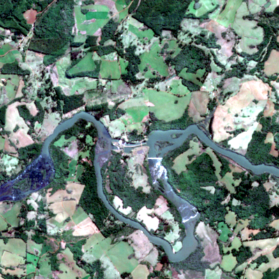

Dimensões: 400 × 400 pixels

Tipo: PNG original

Pixels totais: 160.000 px

Pixels válidos: 160.000 px

Resolução: 10m/pixel (Sentinel-2)  
Área aproximada: 1600.0 hectares

CLASSIFICAÇÃO K-MEANS (k=4)

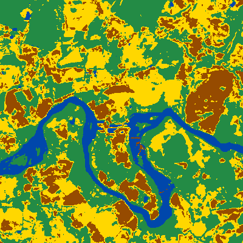

Água

Vegetação densa

Vegetação rasteira

Solo exposto

Água: 12.573 px (7,9%)

Vegetação densa: 67.968 px (42,5%)

Vegetação rasteira: 53.134 px (33,2%)

Solo exposto: 26.325 px (16,5%)

TOTAL: 160.000 px (100,0%)

ANOMALIAS MAHALANOBIS

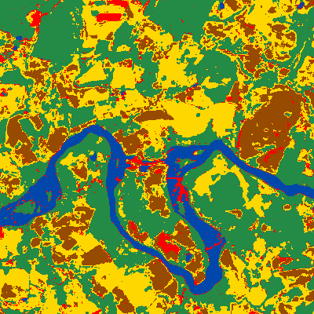

Pixel anômalo (detectado)

Cores de fundo (classes K-Means)

Anomalias detectadas: 8.002 px

Percentual da imagem: 5,0%

Limiar de detecção: Percentil 95

Método estatístico: Mahalanobis

Interpretação:

Pontos vermelhos indicam pixels estatisticamente atípicos dentro de suas respectivas classes, possivelmente representando erros de classificação do K-Means ou áreas de transição entre classes.

📊 DISTRIBUIÇÃO DAS ANOMALIAS POR CLASSE

Anomalias totais: **8.002 px** (5,0% da imagem)

| Classe | Total Pixels | Anomalias | % da Classe |
| --- | --- | --- | --- |
| Água | 12.573 | 629 | 5,0% |
| Vegetação Densa | 67.968 | 3.399 | 5,0% |
| Vegetação Rasteira | 53.134 | 2.657 | 5,0% |
| Solo Exposto | 26.325 | 1.317 | 5,0% |
| TOTAL | 160.000 | 8.002 | 5,0% |

**Interpretação:** A tabela mostra como as 8.002 anomalias estão distribuídas entre as 4 classes. Isso ajuda a identificar em quais classes o K-Means teve mais dificuldade de classificação.

```
==============================================================================================================
Tempo de execução → 00:00:01.28 (hh:mm:ss)
Finalizado em → 07/12/2025 às 13:02:12
==============================================================================================================
```

```python
for cls in range(4):
    total_classe = (labels_map == cls).sum()
    anomalias_classe = contagem_por_classe[cls]
    percentual_classe = anomalias_classe / total_classe * 100 if total_classe > 0 else 0

    tabela_anomalias += f"""
        <tr>
            <td style="padding: 10px; border: 1px solid #dee2e6; font-weight: bold; color: rgb({class_colors_rgb[cls][0]}, {class_colors_rgb[cls][1]}, {class_colors_rgb[cls][2]});">
                {class_names[cls]}
            </td>
            <td style="padding: 10px; border: 1px solid #dee2e6; text-align: right;">{formatar_numero_br(total_classe)}</td>
            <td style="padding: 10px; border: 1px solid #dee2e6; text-align: right; font-weight: bold;">{formatar_numero_br(anomalias_classe)}</td>
            <td style="padding: 10px; border: 1px solid #dee2e6; text-align: right;">{formatar_percentual_br(percentual_classe)}%</td>
        </tr>
    """

tabela_anomalias += f"""
        <tr style="background: #343a40; color: white; font-weight: bold;">
            <td style="padding: 10px; border: 1px solid #dee2e6;">TOTAL</td>
            <td style="padding: 10px; border: 1px solid #dee2e6; text-align: right;">{formatar_numero_br(total_valid)}</td>
            <td style="padding: 10px; border: 1px solid #dee2e6; text-align: right;">{formatar_numero_br(anom_map.sum())}</td>
            <td style="padding: 10px; border: 1px solid #dee2e6; text-align: right;">{formatar_percentual_br(anom_map.sum()/total_valid*100)}%</td>
        </tr>
    </table>

    <div style="margin-top: 15px; padding: 10px; background: #e9ecef; border-radius: 5px; font-size: 12px;">
        <b>Interpretação:</b> A tabela mostra como as {formatar_numero_br(anom_map.sum())} anomalias estão distribuídas entre as 4 classes.
        Isso ajuda a identificar em quais classes o K-Means teve mais dificuldade de classificação.
    </div>
</div>
"""

display(HTML(tabela_anomalias))

# ETAPA 8: FINALIZAÇÃO
# -----------------------------------------------------------------------------------------------------------------------
tempo_total = time.time() - inicio                          # tempo total em segundos (float)

# Converte para o formato HH:MM:SS
horas = int(tempo_total // 3600)
minutos = int((tempo_total % 3600) // 60)
segundos = tempo_total % 60
tempo_formatado = f"{horas:02d}:{minutos:02d}:{segundos:05.2f}"

print("\n" + "="*110)
print(f"Tempo de execução → {tempo_formatado} (hh:mm:ss)")
print(f"Finalizado em → {datetime.now().strftime('%d/%m/%Y às %H:%M:%S')}")
print("="*110)
```

```python
# ========================================================================================================================
# BLOCO 2:      EXECUÇÃO – LETRA B
#               Calculo K-Means (k=4) + Distância de Mahalanobis no Dataset
#
# OBJETIVO:     Aplicar a metodologia no Dataset
# ========================================================================================================================

# ETAPA 1: CABEÇALHO INSTITUCIONAL DO PROJETO
# ------------------------------------------------------------------------------------------------------------------------
print("=" * 110)
print("PROJETO: AUDITORIA AMBIENTAL EM USINAS HIDRELÉTRICAS")
print("         Asseguração Independente de Relatórios ESG via Dados Exógenos Satelitais")
print("         Calculo K-Means (k=4) + Distância de Mahalanobis no Dataset")
print("=" * 110)

# ETAPA 2: CAMINHOS DAS IMAGENS DE TESTE
# ------------------------------------------------------------------------------------------------------------------------
BASE_PATH = "RESULTADOS"  # Pasta raiz com os dados
K_CLUSTERS = 4  # Mesmo k=4 do script anterior
CLASS_NAMES = ["Água", "Vegetação Densa", "Vegetação Rasteira", "Solo Exposto"]
MAHALANOBIS_PERCENTIL = 95  # Percentil para limiar de anomalias

inicio = time.time()      # Iniciar cronômetro

# ETAPA 3: BARRA DE PROGRESSO (Só funciona no Jupyter/Colab)
# -----------------------------------------------------------------------------------------------------------------------
# Configurações para não truncar o console
from IPython.core.interactiveshell import InteractiveShell
InteractiveShell.ast_node_interactivity = "all"  # MOSTRA TUDO

# CONFIGURAR PARA MOSTRAR TODO O OUTPUT
pd.set_option('display.max_rows', None)
pd.set_option('display.max_columns', None)
pd.set_option('display.width', None)
pd.set_option('display.max_colwidth', None)

# Criação da barra de progresso azul
progress_bar = widgets.FloatProgress(value=0, min=0, max=100, description='Progresso:',
                                     style={'bar_color': '#0066cc'}, layout=widgets.Layout(width='80%'))
status_label = widgets.HTML(value="<b>Iniciando processamento do dataset de imagens...</b>")
display(widgets.VBox([status_label, progress_bar]))

# Função para atualizar a barra de progresso
def atualizar_progresso(percentual, mensagem):
    progress_bar.value = percentual
    status_label.value = f"<b>{mensagem}</b> ({percentual:.0f}%)"

# ETAPA 4: FUNÇÕES AUXILIARES (reutilizadas do script anterior)
# ------------------------------------------------------------------------------------------------------------------------
def carregar_processar_imagem(caminho_tiff, caminho_png=None):
    """Carrega e processa imagem TIFF e PNG similar ao script anterior."""
    with rasterio.open(caminho_tiff) as src:
        arr = src.read().astype(np.float32)
    arr = np.transpose(arr, (1, 2, 0))
    H, W, B = arr.shape

    # Carregar PNG ou criar alternativa
    if caminho_png and os.path.exists(caminho_png):
        img_png = cv2.imread(caminho_png)
        img_png_rgb = cv2.cvtColor(img_png, cv2.COLOR_BGR2RGB) if img_png is not None else None
    else:
        img_png_rgb = None

    # Preparar dados
    px = arr.reshape(-1, B)
    mask_valid = np.all(np.isfinite(px), axis=1)
    px_valid = px[mask_valid]

    # Normalizar
    mean_b = px_valid.mean(axis=0)
    std_b = px_valid.std(axis=0) + 1e-10
    px_norm = (px_valid - mean_b) / std_b

    return {
        'px_norm': px_norm,
        'px_valid': px_valid,
        'mask_valid': mask_valid,
        'H': H, 'W': W, 'B': B,
        'total_valid': len(px_valid),
        'total_pixels': H * W,
        'img_png': img_png_rgb
    }

def processar_kmeans(dados, k=4):
    """Executa K-Means e mapeamento semântico similar ao script anterior."""
    px_norm = dados['px_norm']
    H, W = dados['H'], dados['W']
    mask_valid = dados['mask_valid']
    B = dados['B']
    px_valid = dados['px_valid']

    # K-Means
    km = KMeans(n_clusters=k, random_state=42, n_init=10)
    km.fit(px_norm)
    labels_valid = km.labels_

    # Mapa 2D
    labels_map = np.full(H * W, -1, int)
    labels_map[mask_valid] = labels_valid
    labels_map = labels_map.reshape(H, W)

    # IDENTIFICAÇÃO SEMÂNTICA DAS CLASSES (igual ao script anterior)
    # Calcular propriedades médias por classe
    class_properties = []
    for cls in range(k):
        idx = (labels_valid == cls)
        if idx.sum() == 0:
            class_properties.append([0, 0, 0, 0])
            continue

        px_cls = px_valid[idx]

        # Médias por banda (assumindo bandas Sentinel-2)
        mean_b2 = px_cls[:, 0].mean() if B > 0 else 0  # Blue
        mean_b3 = px_cls[:, 1].mean() if B > 1 else 0  # Green
        mean_b4 = px_cls[:, 2].mean() if B > 2 else 0  # Red
        mean_b8 = px_cls[:, 3].mean() if B > 3 else 0  # NIR

        # Calcular NDVI e NDWI
        ndvi = (mean_b8 - mean_b4) / (mean_b8 + mean_b4 + 1e-10) if (mean_b8 + mean_b4) > 0 else 0
        ndwi = (mean_b3 - mean_b8) / (mean_b3 + mean_b8 + 1e-10) if (mean_b3 + mean_b8) > 0 else 0

        class_properties.append([ndvi, ndwi, mean_b8, idx.sum()])

    # Criar pontuação para cada classe
    scores = []
    for i, props in enumerate(class_properties):
        ndvi, ndwi, nir, count = props

        score_agua = ndwi - ndvi
        score_veg_densa = ndvi + (nir / 10000 if nir > 0 else 0)
        score_veg_rasteira = ndvi * 0.7
        score_solo = -ndvi - ndwi

        scores.append({
            'original_idx': i,
            'agua': score_agua,
            'veg_densa': score_veg_densa,
            'veg_rasteira': score_veg_rasteira,
            'solo': score_solo,
            'count': count
        })

    # Ordenar e mapear
    # Água
    scores_sorted = sorted(scores, key=lambda x: x['agua'], reverse=True)
    agua_idx = scores_sorted[0]['original_idx']

    # Vegetação densa
    scores_sorted = sorted(scores, key=lambda x: x['veg_densa'], reverse=True)
    veg_densa_idx = scores_sorted[0]['original_idx']
    if veg_densa_idx == agua_idx:
        veg_densa_idx = scores_sorted[1]['original_idx']
```

```python
    # Solo
    scores_sorted = sorted(scores, key=lambda x: x['solo'], reverse=True)
    solo_idx = scores_sorted[0]['original_idx']
    if solo_idx in [agua_idx, veg_densa_idx]:
        solo_idx = scores_sorted[1]['original_idx']

    # Vegetação rasteira (restante)
    restantes = [i for i in range(k) if i not in [agua_idx, veg_densa_idx, solo_idx]]
    veg_rasteira_idx = restantes[0] if restantes else 2

    # Criar mapeamento de cores
    color_mapping = {
        agua_idx: 0,           # Azul
        veg_densa_idx: 1,      # Verde
        veg_rasteira_idx: 2,   # Amarelo
        solo_idx: 3            # Marrom
    }

    # Reordenar labels para cores corretas
    labels_map_corrigido = np.full_like(labels_map, -1)
    for cls_original, cls_corrigido in color_mapping.items():
        labels_map_corrigido[labels_map == cls_original] = cls_corrigido

    labels_map = labels_map_corrigido

    # Atualizar labels_valid também
    labels_valid_corrigido = np.full_like(labels_valid, -1)
    for cls_original, cls_corrigido in color_mapping.items():
        labels_valid_corrigido[labels_valid == cls_original] = cls_corrigido
    labels_valid = labels_valid_corrigido

    # CALCULAR ESTATÍSTICAS DAS CLASSES
    class_stats = []
    for cls in range(k):
        n_class = (labels_valid == cls).sum()
        perc_class = n_class / dados['total_valid'] * 100
        class_stats.append((cls, n_class, perc_class))

    return {
        'labels_map': labels_map,
        'labels_valid': labels_valid,
        'class_stats': class_stats,  # [(cls, n_pixels, %), ...]
        'total_valid': dados['total_valid']
    }

def processar_mahalanobis(dados_kmeans, dados_imagem, percentil=95):
    """Calcula anomalias de Mahalanobis similar ao script anterior."""
    px_norm = dados_imagem['px_norm']
    labels_map = dados_kmeans['labels_map']
    labels_valid = dados_kmeans['labels_valid']
    H, W = dados_imagem['H'], dados_imagem['W']
    B = dados_imagem['B']
    k = len(dados_kmeans['class_stats'])

    # CÁLCULO DE ESTATÍSTICAS MAHALANOBIS POR CLASSE
    stats = {}
    for cls in range(k):
        idx = (labels_valid == cls)
        px_cls = px_norm[idx]
        N_cls = len(px_cls)

        mu = px_cls.mean(axis=0)

        if N_cls > 1:
            cov = np.cov(px_cls, rowvar=False)
            cov_reg = cov + np.eye(B) * 1e-6
            try:
                cov_inv = inv(cov_reg)
            except:
                cov_inv = np.linalg.pinv(cov_reg)
        else:
            cov_inv = np.eye(B)

        stats[cls] = (mu, cov_inv, N_cls)

    # IDENTIFICAÇÃO DE ANOMALIAS
    anom_map = np.zeros((H, W), int)
    anom_details = []

    for cls in range(k):
        if cls not in stats:
            continue

        mask = (labels_map == cls)
        mask_valid_cls = (labels_valid == cls)

        if mask_valid_cls.sum() == 0:
            continue

        px_cls = px_norm[mask_valid_cls]
        mu, cov_inv, N_cls = stats[cls]

        diff = px_cls - mu
        temp = diff @ cov_inv
        md_vals = np.sqrt(np.sum(temp * diff, axis=1))

        if len(md_vals) > 5:
            limiar = np.percentile(md_vals, percentil)
            anom_local = md_vals > limiar
            n_anom = anom_local.sum()
            perc_anom = n_anom / N_cls * 100

            anom_full = np.zeros(H * W, bool)
            idx_flat = np.where(mask.flatten())[0]
            anom_full[idx_flat] = anom_local
            anom_full = anom_full.reshape(H, W)

            anom_map = anom_map | anom_full
            anom_details.append((cls, N_cls, md_vals.mean(), md_vals.std(), limiar, n_anom, perc_anom))

    return {
        'anom_map': anom_map,
        'anom_details': anom_details,
        'total_anomalias': anom_map.sum()
    }

# ETAPA 5: FUNÇÃO PRINCIPAL DE PROCESSAMENTO POR IMAGEM
# ------------------------------------------------------------------------------------------------------------------------
def processar_imagem_completa(caminho_tiff, caminho_png=None):
    """
    Processa uma única imagem com todo o pipeline K-Means + Mahalanobis.
    Retorna dicionário com todas as métricas.
    """
    # Carregar dados
    dados_imagem = carregar_processar_imagem(caminho_tiff, caminho_png)

    # K-Means
    dados_kmeans = processar_kmeans(dados_imagem, k=K_CLUSTERS)

    # Mahalanobis
    dados_mahal = processar_mahalanobis(dados_kmeans, dados_imagem, percentil=MAHALANOBIS_PERCENTIL)

    # Compilar métricas
    metricas = {
        'arquivo': os.path.basename(caminho_tiff),
        'dimensoes': f"{dados_imagem['H']}x{dados_imagem['W']}",
        'total_pixels': dados_imagem['total_pixels'],
        'pixels_validos': dados_imagem['total_valid'],
        'percentual_validos': (dados_imagem['total_valid'] / dados_imagem['total_pixels'] * 100),
    }

    # Estatísticas por classe
    for cls, (_, n_pixels, perc) in enumerate(dados_kmeans['class_stats']):
        metricas[f'classe_{cls}_pixels'] = n_pixels
        metricas[f'classe_{cls}_percentual'] = perc

    # Anomalias
    metricas['anomalias_totais'] = dados_mahal['total_anomalias']
    metricas['anomalias_percentual'] = (dados_mahal['total_anomalias'] / dados_imagem['total_valid'] * 100)

    # Detalhes Mahalanobis por classe
    for detalhe in dados_mahal['anom_details']:
        cls, N_cls, md_mean, md_std, limiar, n_anom, perc_anom = detalhe
        metricas[f'classe_{cls}_md_media'] = md_mean
        metricas[f'classe_{cls}_md_desvio'] = md_std
        metricas[f'classe_{cls}_md_limiar'] = limiar
        metricas[f'classe_{cls}_anomalias'] = n_anom
        metricas[f'classe_{cls}_anomalias_%'] = perc_anom

    return metricas

# ETAPA 6: VARRER DIRETÓRIOS
# ------------------------------------------------------------------------------------------------------------------------
def varrer_e_processar_pastas(base_path):
    """
    Varre a estrutura de pastas e processa todas as imagens.
    Retorna lista de dicionários com métricas.
    """
    todos_resultados = []

    # Contar total de arquivos para calcular progresso
    total_arquivos = 0
    arquivos_por_estacao = {}
```

```python
    for ano in sorted(os.listdir(base_path)):
        ano_path = os.path.join(base_path, ano)
        if not os.path.isdir(ano_path):
            continue

        for estacao in sorted(os.listdir(ano_path)):
            estacao_path = os.path.join(ano_path, estacao)
            if not os.path.isdir(estacao_path):
                continue

            arquivos_tiff = [f for f in os.listdir(estacao_path) if f.lower().endswith(('.tiff', '.tif'))]
            total_arquivos += len(arquivos_tiff)
            arquivos_por_estacao[(ano, estacao)] = len(arquivos_tiff)

    if total_arquivos == 0:
        atualizar_progresso(100, "Nenhum arquivo encontrado")
        return []

    # Iniciar processamento
    arquivos_processados = 0
    atualizar_progresso(0, "Iniciando varredura de pastas")

    # Percorrer anos
    for ano_idx, ano in enumerate(sorted(os.listdir(base_path))):
        ano_path = os.path.join(base_path, ano)
        if not os.path.isdir(ano_path):
            continue

        # Percorrer estações
        for estacao_idx, estacao in enumerate(sorted(os.listdir(ano_path))):
            estacao_path = os.path.join(ano_path, estacao)
            if not os.path.isdir(estacao_path):
                continue

            # Atualizar status
            atualizar_progresso(
                (arquivos_processados / total_arquivos * 100),
                f"Processando {ano}/{estacao}"
            )

            # Listar arquivos TIFF na pasta da estação
            arquivos_tiff = [f for f in os.listdir(estacao_path) if f.lower().endswith(('.tiff', '.tif'))]

            if not arquivos_tiff:
                continue

            # Processar cada TIFF
            for tiff_idx, tiff_file in enumerate(sorted(arquivos_tiff)):
                tiff_path = os.path.join(estacao_path, tiff_file)

                # Atualizar status detalhado
                atualizar_progresso(
                    (arquivos_processados / total_arquivos * 100),
                    f"Processando {ano}/{estacao}: {tiff_file}"
                )

                # Encontrar PNG correspondente
                nome_base = os.path.splitext(tiff_file)[0]
                png_file = nome_base + '.png'
                png_path = os.path.join(estacao_path, png_file) if os.path.exists(os.path.join(estacao_path, png_file)) else None

                try:
                    # Processar imagem (SEM PRINT DESNECESSÁRIO)
                    metricas = processar_imagem_completa(tiff_path, png_path)

                    # Adicionar metadados
                    metricas['ano'] = ano
                    metricas['estacao'] = estacao
                    metricas['caminho_tiff'] = tiff_path
                    metricas['caminho_png'] = png_path if png_path else 'N/A'

                    todos_resultados.append(metricas)

                except Exception as e:
                    # Apenas registra erro sem parar o processamento
                    print(f"    ✗ ERRO em {tiff_file}: {str(e)}")

                arquivos_processados += 1

    # Finalizar
    atualizar_progresso(100, "Processamento concluído!")

    return todos_resultados

# ETAPA 7: FORMATAÇÃO DA PLANILHA 1 (NOME: DETALHADO)
# -----------------------------------------------------------------------------------------------------------------------
def formatar_planilha_detalhado(writer, df_detalhado):
    HEADER_FILL = "D9D9D9"  # Cinza claro para cabeçalho
    FONT_NAME = "Calibri"
    FONT_SIZE = 12

    # Formato: (nome_coluna, largura, alinhamento, formato_numero, nome_amigavel)
    config_detalhado = [
        # Metadados
        ("ano", 6, "center", "0", "Ano"),
        ("estacao", 12, "center", "@", "Estação"),
        ("arquivo", 25, "left", "@", "Arquivo"),
        ("dimensoes", 12, "center", "@", "Dimensões"),
        ("total_pixels", 12, "right", "#,##0", "Total Pixels"),
        ("pixels_validos", 12, "right", "#,##0", "Pixels Válidos"),
        ("percentual_validos", 14, "right", "0.0%", "% Válidos"),

        # Anomalias gerais
        ("anomalias_totais", 16, "right", "#,##0", "Anomalias Totais"),
        ("anomalias_percentual", 16, "right", "0.0%", "% Anomalias"),

        # Classes - Água (0)
        ("classe_0_pixels", 12, "right", "#,##0", "Água (pixels)"),
        ("classe_0_percentual", 14, "right", "0.0%", "Água (%)"),
        ("classe_0_anomalias", 14, "right", "#,##0", "Água Anomalias"),
        ("classe_0_anomalias_%", 14, "right", "0.0%", "Água % Anomalias"),
        ("classe_0_md_media", 12, "right", "0.000", "Água MD Média"),
        ("classe_0_md_desvio", 12, "right", "0.000", "Água MD Desvio"),
        ("classe_0_md_limiar", 12, "right", "0.000", "Água MD Limiar"),

        # Classes - Vegetação Densa (1)
        ("classe_1_pixels", 12, "right", "#,##0", "Veg. Densa (pixels)"),
        ("classe_1_percentual", 14, "right", "0.0%", "Veg. Densa (%)"),
        ("classe_1_anomalias", 14, "right", "#,##0", "Veg. Densa Anomalias"),
        ("classe_1_anomalias_%", 14, "right", "0.0%", "Veg. Densa % Anomalias"),
        ("classe_1_md_media", 12, "right", "0.000", "Veg. Densa MD Média"),
        ("classe_1_md_desvio", 12, "right", "0.000", "Veg. Densa MD Desvio"),
        ("classe_1_md_limiar", 12, "right", "0.000", "Veg. Densa MD Limiar"),

        # Classes - Vegetação Rasteira (2)
        ("classe_2_pixels", 12, "right", "#,##0", "Veg. Rasteira (pixels)"),
        ("classe_2_percentual", 14, "right", "0.0%", "Veg. Rasteira (%)"),
        ("classe_2_anomalias", 14, "right", "#,##0", "Veg. Rasteira Anomalias"),
        ("classe_2_anomalias_%", 14, "right", "0.0%", "Veg. Rasteira % Anomalias"),
        ("classe_2_md_media", 12, "right", "0.000", "Veg. Rasteira MD Média"),
        ("classe_2_md_desvio", 12, "right", "0.000", "Veg. Rasteira MD Desvio"),
        ("classe_2_md_limiar", 12, "right", "0.000", "Veg. Rasteira MD Limiar"),

        # Classes - Solo Exposto (3)
        ("classe_3_pixels", 12, "right", "#,##0", "Solo (pixels)"),
        ("classe_3_percentual", 14, "right", "0.0%", "Solo (%)"),
        ("classe_3_anomalias", 14, "right", "#,##0", "Solo Anomalias"),
        ("classe_3_anomalias_%", 14, "right", "0.0%", "Solo % Anomalias"),
        ("classe_3_md_media", 12, "right", "0.000", "Solo MD Média"),
        ("classe_3_md_desvio", 12, "right", "0.000", "Solo MD Desvio"),
        ("classe_3_md_limiar", 12, "right", "0.000", "Solo MD Limiar"),
```

```python
        # Caminhos (últimas colunas)
        ("caminho_tiff", 40, "left", "@", "Caminho TIFF"),
        ("caminho_png", 40, "left", "@", "Caminho PNG")
    ]

    worksheet = writer.sheets['Detalhado']

    # Configurar estilos
    header_font = Font(name=FONT_NAME, size=FONT_SIZE, bold=True)
    header_fill = PatternFill(start_color=HEADER_FILL, end_color=HEADER_FILL, fill_type="solid")
    header_alignment = Alignment(horizontal="center", vertical="center", wrap_text=True)

    cell_font = Font(name=FONT_NAME, size=FONT_SIZE)
    center_alignment = Alignment(horizontal="center", vertical="center")
    right_alignment = Alignment(horizontal="right", vertical="center")
    left_alignment = Alignment(horizontal="left", vertical="center")

    # Filtrar apenas colunas que existem no DataFrame
    config_existente = [cfg for cfg in config_detalhado if cfg[0] in df_detalhado.columns]

    # Reordenar DataFrame
    df_detalhado = df_detalhado[[cfg[0] for cfg in config_existente]]

    # Aplicar formatação
    for col_idx, (col_name, width, align, num_format, friendly_name) in enumerate(config_existente, 1):
        col_letter = get_column_letter(col_idx)

        # Configurar largura da coluna
        worksheet.column_dimensions[col_letter].width = width

        # Configurar célula do cabeçalho (usa nome amigável)
        cell = worksheet.cell(row=1, column=col_idx)
        cell.value = friendly_name
        cell.font = header_font
        cell.fill = header_fill
        cell.alignment = header_alignment

        # Configurar alinhamento para coluna
        align_obj = center_alignment if align == "center" else (right_alignment if align == "right" else left_alignment)

        # Aplicar a todas as células da coluna
        for row_idx in range(2, len(df_detalhado) + 2):
            cell = worksheet.cell(row=row_idx, column=col_idx)
            cell.font = cell_font
            cell.alignment = align_obj

            # Aplicar formato numérico
            if num_format != "@":
                cell.number_format = num_format

    # Congelar painel e adicionar auto-filtro
    worksheet.freeze_panes = "A2"
    worksheet.auto_filter.ref = worksheet.dimensions

# ETAPA 8: FORMATAÇÃO DA PLANILHA 2 (NOME: RESUMO_ESTAÇÃO)
# -----------------------------------------------------------------------------------------------------------------------
def formatar_planilha_resumo(writer, df_resumo):
    HEADER_FILL = "D9D9D9"  # Cinza claro para cabeçalho
    FONT_NAME = "Calibri"
    FONT_SIZE = 12

    # Formato: (nome_coluna, largura, alinhamento, formato_numero, nome_amigavel)
    config_resumo = [
        ("ano", 6, "center", "0", "Ano"),
        ("estacao", 12, "center", "@", "Estação"),
        ("qtd_imagens", 10, "right", "#,##0", "Qtd. Imagens"),
        ("pixels_validos_medio", 15, "right", "#,##0", "Pixels Válidos (Média)"),
        ("anomalias_%_medio", 14, "right", "0.0%", "Anomalias % (Média)"),
        ("agua_%_medio", 12, "right", "0.0%", "Água % (Média)"),
        ("veg_densa_%_medio", 15, "right", "0.0%", "Veg. Densa % (Média)"),
        ("veg_rasteira_%_medio", 17, "right", "0.0%", "Veg. Rasteira % (Média)"),
        ("solo_%_medio", 13, "right", "0.0%", "Solo % (Média)")
    ]

    worksheet = writer.sheets['Resumo_Estação']

    # Configurar estilos (mesmo do detalhado)
    header_font = Font(name=FONT_NAME, size=FONT_SIZE, bold=True)
    header_fill = PatternFill(start_color=HEADER_FILL, end_color=HEADER_FILL, fill_type="solid")
    header_alignment = Alignment(horizontal="center", vertical="center", wrap_text=True)

    cell_font = Font(name=FONT_NAME, size=FONT_SIZE)
    center_alignment = Alignment(horizontal="center", vertical="center")
    right_alignment = Alignment(horizontal="right", vertical="center")
    left_alignment = Alignment(horizontal="left", vertical="center")

    # Filtrar apenas colunas que existem no DataFrame
    config_existente = [cfg for cfg in config_resumo if cfg[0] in df_resumo.columns]

    # Reordenar DataFrame
    df_resumo = df_resumo[[cfg[0] for cfg in config_existente]]

    # Aplicar formatação
    for col_idx, (col_name, width, align, num_format, friendly_name) in enumerate(config_existente, 1):
        col_letter = get_column_letter(col_idx)

        # Configurar largura da coluna
        worksheet.column_dimensions[col_letter].width = width

        # Configurar célula do cabeçalho
        cell = worksheet.cell(row=1, column=col_idx)
        cell.value = friendly_name
        cell.font = header_font
        cell.fill = header_fill
        cell.alignment = header_alignment

        # Configurar alinhamento
        align_obj = center_alignment if align == "center" else (right_alignment if align == "right" else left_alignment)

        # Aplicar a todas as células da coluna
        for row_idx in range(2, len(df_resumo) + 2):
            cell = worksheet.cell(row=row_idx, column=col_idx)
            cell.font = cell_font
            cell.alignment = align_obj

            # Aplicar formato numérico
            if num_format != "@":
                cell.number_format = num_format

    # Congelar painel e adicionar auto-filtro
    worksheet.freeze_panes = "A2"
    worksheet.auto_filter.ref = worksheet.dimensions

# ETAPA 9: FUNÇÃO ATUALIZADA PARA EXPORTAR EXCEL (USANDO AS DUAS FUNÇÕES)
# ------------------------------------------------------------------------------------------------------------------------
def exportar_excel(resultados, output_path="resultados_classificacao.xlsx"):
    """Exporta resultados para Excel com formatação profissional."""

    if not resultados:
        print("Nenhum resultado para exportar!")
        return

    # Criar DataFrame principal (DETALHADO)
    df_principal = pd.DataFrame(resultados)

    # Converter percentuais para formato Excel (0.05 para 5%)
    percent_cols = [col for col in df_principal.columns if 'percentual' in col or 'anomalias_%' in col]
    for col in percent_cols:
        if col in df_principal.columns:
            df_principal[col] = df_principal[col] / 100
```

```python
    # Criar DataFrame resumido (RESUMO_ESTACAO)
    df_resumo = df_principal.groupby(['ano', 'estacao']).agg({
        'arquivo': 'count',
        'pixels_validos': 'mean',
        'anomalias_percentual': 'mean',
        'classe_0_percentual': 'mean',
        'classe_1_percentual': 'mean',
        'classe_2_percentual': 'mean',
        'classe_3_percentual': 'mean'
    }).round(4)

    df_resumo = df_resumo.rename(columns={
        'arquivo': 'qtd_imagens',
        'pixels_validos': 'pixels_validos_medio',
        'anomalias_percentual': 'anomalias_%_medio',
        'classe_0_percentual': 'agua_%_medio',
        'classe_1_percentual': 'veg_densa_%_medio',
        'classe_2_percentual': 'veg_rasteira_%_medio',
        'classe_3_percentual': 'solo_%_medio'
    }).reset_index()

    # Exportar para Excel
    with pd.ExcelWriter(output_path, engine='openpyxl') as writer:
        # Salvar DataFrames (sem formatação ainda)
        df_principal.to_excel(writer, sheet_name='Detalhado', index=False)
        df_resumo.to_excel(writer, sheet_name='Resumo_Estação', index=False)

        # Aplicar formatação personalizada a cada planilha
        formatar_planilha_detalhado(writer, df_principal)
        formatar_planilha_resumo(writer, df_resumo)

# ETAPA 10: EXECUÇÃO PRINCIPAL
# ------------------------------------------------------------------------------------------------------------------------
# Funções auxiliares para formatação no console
def formatar_numero_br(num):
    """Formata número com separador de milhar como PONTO e decimal como VÍRGULA"""
    formato_us = f"{num:,.0f}"
    return formato_us.replace(",", "X").replace(".", ",").replace("X", ".")

def formatar_percentual_br(num):
    """Formata percentual com VÍRGULA decimal"""
    return f"{num:.1f}".replace(".", ",")

def criar_barra_visual(percentual, largura=50):
    """Cria uma barra visual ASCII para representar percentuais"""
    blocos_preenchidos = int(percentual * largura / 100)
    return "█" * blocos_preenchidos + "░" * (largura - blocos_preenchidos)

# Bloco principal de execução do script
if __name__ == "__main__":

    # Processar todas as pastas de imagens
    resultados = varrer_e_processar_pastas(BASE_PATH)  # Executa a varredura de pastas

    if resultados:
        # Exportar resultados para Excel
        nome_excel = f"resultados_classico_{datetime.now().strftime('%Y%m%d_%H%M%S')}.xlsx"
        exportar_excel(resultados, nome_excel)  # Exporta dados para arquivo Excel

        # Criar DataFrame para análise estatística
        df = pd.DataFrame(resultados)  # Converte lista de dicionários para DataFrame

        # Exibir estatísticas gerais no console
        # Calcular totais gerais
        total_imagens = len(df)
        total_pixels = df['total_pixels'].sum()
        total_anomalias = df['anomalias_totais'].sum()
        percentual_anomalias = (total_anomalias / df['pixels_validos'].sum() * 100)

        print(f"\n{'-'*70}")
        print(" ESTATÍSTICAS GERAIS:")
        print(f"{'-'*70}")
        print(f"   • Imagens processadas: {formatar_numero_br(total_imagens)}")
        print(f"   • Pixels totais: {formatar_numero_br(total_pixels)}")
        print(f"   • Anomalias detectadas: {formatar_numero_br(total_anomalias)}")
        print(f"   • Percentual de anomalias: {formatar_percentual_br(percentual_anomalias)}%")

        # Exibir distribuição média das classes
        print(f"\n{'-'*70}")
        print(" DISTRIBUIÇÃO MÉDIA DAS CLASSES (Dataset completo):")
        print(f"{'-'*70}")

        # Configurações para exibição da tabela
        area_total_km2 = 10000  # Área total hipotética de 10.000 km²
        emojis = ["🔵", "🟢", "🟡", "🟤"]  # Emojis para representação visual

        print(f"{'Classe':<22} {'Cor':<4} {'Área (km²)':<12} {'%':<8} {'Barra'}")
        print("-" * 70)

        total_area = 0
        total_percent = 0

        # Calcular e exibir dados para cada classe
        for cls in range(4):
            nome_classe = CLASS_NAMES[cls]
            media_percentual = df[f'classe_{cls}_percentual'].mean()
            area_km2 = area_total_km2 * (media_percentual / 100)

            total_area += area_km2
            total_percent += media_percentual

            # Criar barra visual proporcional ao percentual
            barra = "█" * int(media_percentual / 2)  # Cada 2% = um bloco

            print(f"{nome_classe:<22} {emojis[cls]:<4} {area_km2:<11.0f} "
                  f"{media_percentual:<7.1f}% {barra}")

        # Linha de total consolidado
        print("-" * 70)
        print(f"{'TOTAL':<22} {'':<4} {total_area:<11.0f} {total_percent:<7.1f}%")

        # GRÁFICO DE LINHA TEMPORAL (COM MATPLOTLIB)
        # FUNÇÃO ISOLADA para criar gráfico sem poluição
        def criar_grafico_temporal(df):
            """Cria gráfico temporal SEM imprimir objetos no console"""
            try:
                import matplotlib.pyplot as plt
                import numpy as np

                # Preparar dados
                anos = sorted(df['ano'].unique())

                dados_grafico = {
                    'Água': [df[df['ano'] == ano]['classe_0_percentual'].mean() for ano in anos],
                    'Vegetação Densa': [df[df['ano'] == ano]['classe_1_percentual'].mean() for ano in anos],
                    'Vegetação Rasteira': [df[df['ano'] == ano]['classe_2_percentual'].mean() for ano in anos],
                    'Solo Exposto': [df[df['ano'] == ano]['classe_3_percentual'].mean() for ano in anos]
                }

                cores = ['#1f77b4', '#2ca02c', '#ff7f0e', '#8c564b']

                # CRIAR FIGURA - COM SILÊNCIO TOTAL
                fig, ax = plt.subplots(figsize=(14, 7))

                # Plotar linhas (SEM RETORNAR VALOR)
                lines = []  # Lista para armazenar objetos de linha
                for idx, (classe, valores) in enumerate(dados_grafico.items()):
                    line = ax.plot(anos, valores,
                                 marker='o',
                                 linewidth=3.0,
                                 markersize=10,
                                 color=cores[idx],
                                 label=classe)
                    lines.append(line[0])  # Armazena, não imprime
```

```python
                # Configurar (SEM RETORNAR VALOR)
                ax.set_title('EVOLUÇÃO TEMPORAL DA COBERTURA DO SOLO',
                           fontsize=18, fontweight='bold', pad=25)
                ax.set_xlabel('Ano', fontsize=14)
                ax.set_ylabel('Porcentagem (%)', fontsize=14)
                ax.grid(True, linestyle='--', alpha=0.3)

                # Legenda (SEM RETORNAR VALOR)
                legend = ax.legend(loc='upper center',
                                 bbox_to_anchor=(0.5, -0.15),
                                 ncol=4,
                                 fontsize=12,
                                 framealpha=0.9)

                ax.set_xticks(anos)
                ax.set_ylim(0, 50)
                ax.tick_params(axis='both', labelsize=12)

                # Anotações (SILENCIOSAS)
                annotations = []  # Lista para armazenar anotações
                for idx, (classe, valores) in enumerate(dados_grafico.items()):
                    for x, y in zip(anos, valores):
                        ann = ax.annotate(f'{y:.1f}%',
                                        (x, y),
                                        textcoords="offset points",
                                        xytext=(0, 12),
                                        ha='center',
                                        fontsize=11,
                                        fontweight='bold',
                                        color=cores[idx],
                                        bbox=dict(boxstyle="round,pad=0.3", facecolor="white", alpha=0.8))
                        annotations.append(ann)  # Armazena, não imprime

                plt.tight_layout(rect=[0, 0.1, 1, 0.95])

                # RETORNAR APENAS A FIGURA - NADA MAIS
                return fig

            except ImportError:
                return None

        # EXECUTAR E EXIBIR GRÁFICO
        try:
            # Criar gráfico de forma isolada
            figura = criar_grafico_temporal(df)

            if figura is not None:
                # Exibir gráfico DIRETAMENTE, sem objetos intermediários
                import matplotlib.pyplot as plt
                plt.show()
                plt.close(figura)  # Fechar para liberar memória
            else:
                # Se matplotlib não estiver disponível, mostrar ASCII
                raise ImportError("Matplotlib não disponível")

        except ImportError as e:
            # FALLBACK ASCII (igual ao anterior)
            print(f"⚠️  Matplotlib não disponível. Exibindo versão ASCII:")
            print(f"\n📊 TENDÊNCIA TEMPORAL (ASCII - ANOS: {', '.join(map(str, sorted(df['ano'].unique())))}):")
            print("-" * 80)

            anos = sorted(df['ano'].unique())

            print(f"\n🔵 ÁGUA:")
            for ano in anos:
                media = df[df['ano'] == ano]['classe_0_percentual'].mean()
                barra = "█" * int(media)
                print(f"  {ano}: {media:5.1f}% {barra}")

            print(f"\n🟢 VEGETAÇÃO DENSA:")
            for ano in anos:
                media = df[df['ano'] == ano]['classe_1_percentual'].mean()
                barra = "█" * int(media / 2)
                print(f"  {ano}: {media:5.1f}% {barra}")

            print(f"\n🟡 VEGETAÇÃO RASTEIRA:")
            for ano in anos:
                media = df[df['ano'] == ano]['classe_2_percentual'].mean()
                barra = "█" * int(media / 2)
                print(f"  {ano}: {media:5.1f}% {barra}")

            print(f"\n🟤 SOLO EXPOSTO:")
            for ano in anos:
                media = df[df['ano'] == ano]['classe_3_percentual'].mean()
                barra = "█" * int(media * 2)
                print(f"  {ano}: {media:5.1f}% {barra}")

            print(f"\n📏 Legenda: Cada '█' representa ~1-2% (varia por classe)")

        # INSIGHTS E RECOMENDAÇÕES
        print(f"\n" + "-"*110)
        print(" INSIGHTS E RECOMENDAÇÕES")
        print("-"*110)

        # Consistência temporal das imagens processadas
        print(f"\n CONSISTÊNCIA TEMPORAL:")
        for ano, grupo_ano in df.groupby('ano'):
            print(f"   • {ano}: {len(grupo_ano)} imagens processadas")

        # Identificar estações com anomalias excessivas
        media_geral_anomalias = df['anomalias_percentual'].mean()
        estacoes_problematicas = []

        for (ano, estacao), grupo in df.groupby(['ano', 'estacao']):
            if grupo['anomalias_percentual'].mean() > (media_geral_anomalias * 1.5):
                estacoes_problematicas.append((ano, estacao, grupo['anomalias_percentual'].mean()))

        # Recomendações para auditoria
        print(f"\n RECOMENDAÇÕES PARA AUDITORIA:")
        print(f"   1. Verificar imagens com anomalias > {media_geral_anomalias * 1.2:.1f}%")

        if estacoes_problematicas:
            print(f"   2. Investigar estações com anomalias elevadas:")
            for ano, estacao, media in estacoes_problematicas[:3]:  # Mostra até 3 estações
                print(f"      • {ano}/{estacao}: {media:.1f}%")
        else:
            print(f"   2. Nenhuma estação com anomalias excessivas detectada")

        print(f"   3. Analisar variações sazonais na distribuição das classes")
        print(f"   4. Validar manualmente {max(1, int(total_imagens * 0.05))} imagens aleatórias")

        # Insights ambientais baseados nas médias
        print(f"\n INSIGHTS AMBIENTAIS:")
        media_veg_densa = df['classe_1_percentual'].mean()
        media_solo = df['classe_3_percentual'].mean()
        media_agua = df['classe_0_percentual'].mean()

        if media_veg_densa > 35:
            print(f"    Vegetação densa adequada: {media_veg_densa:.1f}%")
        else:
            print(f"    ⚠️  Vegetação densa abaixo do ideal: {media_veg_densa:.1f}%")

        if media_solo < 20:
            print(f"    Solo exposto dentro do esperado: {media_solo:.1f}%")
        else:
            print(f"    ⚠️  Solo exposto acima do esperado: {media_solo:.1f}%")

        if media_agua > 5:
            print(f"    Presença hídrica adequada: {media_agua:.1f}%")
        else:
            print(f"    ⚠️  Presença hídrica abaixo do esperado: {media_agua:.1f}%")
```

```
==============================================================================================================
PROJETO: AUDITORIA AMBIENTAL EM USINAS HIDRELÉTRICAS
         Asseguração Independente de Relatórios ESG via Dados Exógenos Satelitais
         Calculo K-Means (k=4) + Distância de Mahalanobis no Dataset
==============================================================================================================
```

```
VBox(children=(HTML(value='<b>Iniciando processamento do dataset de imagens...</b>'), FloatProgress(value=0.0,…
```

```
RuntimeWarning: Mean of empty slice.
RuntimeWarning: invalid value encountered in divide
```

```
----------------------------------------------------------------------
 ESTATÍSTICAS GERAIS:
----------------------------------------------------------------------
   • Imagens processadas: 139
   • Pixels totais: 22.240.000
   • Anomalias detectadas: 1.109.804
   • Percentual de anomalias: 5,0%

----------------------------------------------------------------------
 DISTRIBUIÇÃO MÉDIA DAS CLASSES (Dataset completo):
----------------------------------------------------------------------
Classe                 Cor  Área (km²)   %        Barra
----------------------------------------------------------------------
Água                   🔵    821         8.2    % ████
Vegetação Densa        🟢    4125        41.3   % ████████████████████
Vegetação Rasteira     🟡    3142        31.4   % ███████████████
Solo Exposto           🟤    1889        18.9   % █████████
----------------------------------------------------------------------
TOTAL                       9978        99.8   %
```

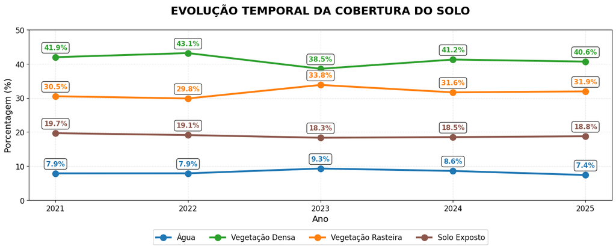

```
--------------------------------------------------------------------------------------------------------------
 INSIGHTS E RECOMENDAÇÕES
--------------------------------------------------------------------------------------------------------------

 CONSISTÊNCIA TEMPORAL:
   • 2021: 27 imagens processadas
   • 2022: 32 imagens processadas
   • 2023: 24 imagens processadas
   • 2024: 32 imagens processadas
   • 2025: 24 imagens processadas

 RECOMENDAÇÕES PARA AUDITORIA:
   1. Verificar imagens com anomalias > 6.0%
   2. Nenhuma estação com anomalias excessivas detectada
   3. Analisar variações sazonais na distribuição das classes
   4. Validar manualmente 6 imagens aleatórias

 INSIGHTS AMBIENTAIS:
    Vegetação densa adequada: 41.3%
    Solo exposto dentro do esperado: 18.9%
    Presença hídrica adequada: 8.2%
💾 Resultados salvos em: resultados_classico_20251206_194314.xlsx

==============================================================================================================
Tempo de execução → 00:01:52.85 (hh:mm:ss)
Finalizado em → 06/12/2025 às 19:43:14
==============================================================================================================
```

```python
        # Informar localização do arquivo de resultados
        print(f"💾 Resultados salvos em: {nome_excel}")

# ETAPA 11: FINALIZAÇÃO
# -----------------------------------------------------------------------------------------------------------------------
tempo_total = time.time() - inicio                          # tempo total em segundos (float)

# Converte para o formato HH:MM:SS
horas = int(tempo_total // 3600)
minutos = int((tempo_total % 3600) // 60)
segundos = tempo_total % 60
tempo_formatado = f"{horas:02d}:{minutos:02d}:{segundos:05.2f}"

print("\n" + "="*110)
print(f"Tempo de execução → {tempo_formatado} (hh:mm:ss)")
print(f"Finalizado em → {datetime.now().strftime('%d/%m/%Y às %H:%M:%S')}")
print("="*110)
```

```python
# ========================================================================================================================
# BLOCO 2:   EXECUÇÃO - LETRA C
#            Aprimoramento de Rede Neural com Yolo 8
#
# OBJETIVO: Gerar anotações pseudo-labels e realizar fine-tuning no modelo Yolo 8 para detecção em imagens específicas
# ========================================================================================================================
# Importações Complementares
import yaml      # Biblioteca para ler e criar arquivos de configuração .yaml (essencial para o YOLO)
import shutil    # Biblioteca para operações de alto nível em arquivos (copiar, mover e deletar pastas)
import random    # Biblioteca para gerar números aleatórios (usada para embaralhar/dividir treino e teste)

# ETAPA 1: CABEÇALHO INSTITUCIONAL
# ------------------------------------------------------------------------------------------------------------------------
print("=" * 110)                                                # Imprime linha de separação
print("PROJETO: AUDITORIA AMBIENTAL EM USINAS HIDRELÉTRICAS")   # Título principal do projeto
print("         Asseguração Independente de Relatórios ESG via Dados Exógenos Satelitais")  # Descrição do projeto
print("         Aprendizado Profundo Fine-Tuning Yolo 8")       # Especificação da técnica utilizada
print("=" * 110)                                                # Imprime linha de separação

inicio = time.time()                                            # Registra o tempo de início para cálculo de duração total no final

# ETAPA 2: BARRA DE PROGRESSO
# ------------------------------------------------------------------------------------------------------------------------
try:
    import ipywidgets as widgets  # Importa biblioteca para widgets interativos (barra de progresso)
    progress = widgets.FloatProgress(  # Cria widget de progresso flutuante
        value=0, min=0, max=100, description='Progresso:',  # Configurações iniciais: valor 0, máx 100, descrição
        style={'bar_color': '#0066cc'}, layout=widgets.Layout(width='85%', height='30px')  # Estilo e layout da barra
    )
    status = widgets.HTML(value="<b>Iniciando configurações...</b>")  # Widget HTML para status textual
    display(widgets.VBox([status, progress]))  # Exibe caixa vertical com status e progresso
    use_widgets = True  # Flag para indicar que widgets estão disponíveis
except ImportError:
    use_widgets = False  # Flag para indicar falha na importação (ex: ambiente sem Jupyter)
    print("Widgets não instalados.")  # Mensagem informativa se widgets não estiverem disponíveis

# ETAPA 3: CONFIGURAÇÕES E PARÂMETROS
# ------------------------------------------------------------------------------------------------------------------------
# Atualização da Barra de Progresso
if use_widgets:
    status.value = "<b>Definindo caminhos e parâmetros do sistema...</b>"       # Atualiza mensagem de status
    progress.value = 10                                                          # Atualiza barra para 10%

# Definição de Caminhos do Sistema de Arquivos
BASE_DIR = Path(r"C:\Users\renat\OneDrive\Mestrado em Contabilidade\2025\2025.2c Visão Computacional\VC_TF")
IMG_ORIGINAL = Path(r"C:\Users\renat\OneDrive\Mestrado em Contabilidade\2025\2025.2c Visão Computacional\VC_TF\RESULTADOS\2025\inverno\S2C_MSIL2A_20250821T132251_N0511_R038_T22JEQ_20250821T170915.png")
MASK_KMEANS = Path(r"C:\Users\renat\OneDrive\Mestrado em Contabilidade\2025\2025.2c Visão Computacional\VC_TF\RESULTADOS\S2C_MSIL2A_20250821T132251_N0511_R038_T22JEQ_20250821T170915_KMEANS.png")

# Configuração de Diretórios de Saída
ID_EXECUCAO = f"Yolo_treino"                                                        # Nome fixo para a pasta de execução
DATASET_DIR = BASE_DIR / f"Yolo_dataset_{ID_EXECUCAO}"                              # Diretório onde o dataset formatado para YOLO será criado
OUTPUT_DIR = BASE_DIR / "Yolo_resultados"                                           # Diretório onde os pesos e gráficos do treino serão salvos

# Definições Semânticas (Classes e Cores)
CLASS_NAMES = {0: 'Agua', 1: 'Veg_Densa', 2: 'Veg_Rasteira', 3: 'Solo'}             # Dicionário mapeando ID numérico para Nome da Classe
COLORS_BGR = {0: (171, 71, 0), 1: (69, 139, 35), 2: (0, 215, 255), 3: (0, 75, 150)} # Cores BGR (padrão OpenCV) para desenhar as máscaras

# ETAPA 4: PREPARAÇÃO DO DATASET (EXTRAÇÃO DE POLÍGONOS E SPLIT)
# ------------------------------------------------------------------------------------------------------------------------
def preparar_dados():
    # Atualização da Barra de Progresso
    if use_widgets:
        status.value = "<b>Processando imagens e gerando anotações (Polígonos)...</b>" # Atualiza status
        progress.value = 20                                                            # Atualiza barra para 20%

    # Criação da estrutura de pastas para o YOLO
    for split in ['train', 'val']:
        os.makedirs(DATASET_DIR / split / "images", exist_ok=True)                     # Cria pasta de imagens (treino/val)
        os.makedirs(DATASET_DIR / split / "labels", exist_ok=True)                     # Cria pasta de rótulos (treino/val)

    # Leitura das Imagens Base
    img = cv2.imread(str(IMG_ORIGINAL))                                                # Lê a imagem original do satélite
    mask = cv2.imread(str(MASK_KMEANS))                                                # Lê a máscara gerada pelo K-Means (Gabarito)
    H, W, _ = img.shape                                                                # Obtém altura e largura para normalização
    todos_poligonos = []                                                               # Lista para armazenar todas as anotações geradas

    # Loop de Extração de Polígonos por Classe
    for cls_id, color_bgr in COLORS_BGR.items():
        # Definição de limites de cor com tolerância (para lidar com compressão)
        lower = np.array([max(0, c-15) for c in color_bgr])                            # Limite inferior da cor
        upper = np.array([min(255, c+15) for c in color_bgr])                          # Limite superior da cor
        binary_mask = cv2.inRange(mask, lower, upper)                                  # Cria máscara binária isolando a cor atual
```

```python
        # Encontra contornos na máscara binária
        contours, _ = cv2.findContours(binary_mask, cv2.RETR_EXTERNAL, cv2.CHAIN_APPROX_SIMPLE)

        conta_classe = 0
        for cnt in contours:
            # Filtragem de Ruído e Simplificação
            if cv2.contourArea(cnt) > 50:                                              # Ignora áreas muito pequenas (< 50 pixels)
                cnt = cv2.approxPolyDP(cnt, 0.005 * cv2.arcLength(cnt, True), True)    # Simplifica a geometria do polígono (reduz vértices)

                # Normalização das Coordenadas (0 a 1) exigida pelo YOLO
                points = [f"{pt[0][0]/W:.6f} {pt[0][1]/H:.6f}" for pt in cnt]          # Converte px para coordenada relativa

                if len(points) > 2:                                                    # Garante que é um polígono válido (mínimo 3 pontos)
                    todos_poligonos.append(f"{cls_id} " + " ".join(points))            # Adiciona ao dataset no formato: ID x1 y1 x2 y2...
                    conta_classe += 1

        print(f"   -> Classe {CLASS_NAMES[cls_id]}: {conta_classe} áreas encontradas.") # Log de contagem por classe

    # Divisão de Dados (Train/Val Split)
    random.seed(42)                                                                    # Semente fixa para reprodutibilidade
    random.shuffle(todos_poligonos)                                                    # Embaralha os polígonos aleatoriamente
    split_idx = int(len(todos_poligonos) * 0.8)                                        # Define ponto de corte (80% para treino)
    train_labels = todos_poligonos[:split_idx]                                         # Fatia de Treino (80%)
    val_labels = todos_poligonos[split_idx:]                                           # Fatia de Validação (20%)

    # Salvamento dos Arquivos
    nome_txt = IMG_ORIGINAL.stem + ".txt"                                              # Nome do arquivo de texto (mesmo da imagem)

    # Conjunto de Treino
    shutil.copy2(IMG_ORIGINAL, DATASET_DIR / "train" / "images" / IMG_ORIGINAL.name)   # Copia imagem para pasta de treino
    with open(DATASET_DIR / "train" / "labels" / nome_txt, "w") as f:                  # Cria arquivo de anotação de treino
        f.write("\n".join(train_labels))                                               # Escreve os polígonos de treino

    # Conjunto de Validação
    shutil.copy2(IMG_ORIGINAL, DATASET_DIR / "val" / "images" / IMG_ORIGINAL.name)     # Copia imagem para pasta de validação
    with open(DATASET_DIR / "val" / "labels" / nome_txt, "w") as f:                    # Cria arquivo de anotação de validação
        f.write("\n".join(val_labels))                                                 # Escreve os polígonos de validação

    # Criação do Arquivo de Configuração (data.yaml)
    yaml_data = {
        'path': str(DATASET_DIR),                                                      # Caminho raiz do dataset
        'train': 'train/images',                                                       # Subpasta de treino
        'val': 'val/images',                                                           # Subpasta de validação
        'names': CLASS_NAMES                                                           # Nomes das classes
    }

    with open(DATASET_DIR / "data.yaml", "w") as f:
        yaml.dump(yaml_data, f)                                                        # Salva o arquivo de configuração YAML

    print(f">> Dataset Pronto! {len(train_labels)} polígonos de treino / {len(val_labels)} de validação.\n")

# ETAPA 5: MONITOR GRÁFICO (COM ATUALIZAÇÃO DA BARRA DE PROGRESSO)
# ------------------------------------------------------------------------------------------------------------------------
from IPython.display import display, clear_output                                # Importa funções para limpar e atualizar a célula do notebook

class LivePlotter:
    def __init__(self):
        self.epochs = []                                                         # Lista para armazenar o histórico de épocas
        self.losses = []                                                         # Lista para armazenar o histórico de erros (Loss)
        self.maps = []                                                           # Lista para armazenar o histórico de acurácia (mAP)

        # Inicialização da Figura Gráfica
        self.fig, (self.ax1, self.ax2) = plt.subplots(1, 2, figsize=(12, 5))     # Cria layout com 2 gráficos lado a lado
        plt.close(self.fig)                                                      # Fecha a figura estática inicial para evitar duplicação na tela

        # Cria um "Handle" (Identificador) para atualizar o gráfico dinamicamente
        self.display_handle = display(self.fig, display_id=True)                 # Exibe o gráfico vazio inicial e guarda o ID dele

        # Impressão do Cabeçalho da Tabela no Console
        print("="*95)
        print(f"{'TREINAMENTO INTENSIVO (MONITORAMENTO EM TEMPO REAL)':^95}")    # Título centralizado
        print("="*95)
        print(f"| {'ÉPOCA':^7} | {'SEG LOSS':^15} | {'ACURÁCIA (mAP)':^18} | {'PRECISÃO':^12} | {'RECALL':^12} | {'STATUS':^10} |")
        print("-" * 95)

    def update(self, trainer):
        # --- ATUALIZAÇÃO DA BARRA DE PROGRESSO (WIDGETS) ---
        if use_widgets:
            total = trainer.args.epochs                                             # Pega o total de épocas configurado
            atual = trainer.epoch + 1                                               # Pega a época atual (soma 1 pois começa em 0)
            progress.value = (atual / total) * 100                                  # Calcula a porcentagem e move a barra azul
            status.value = f"<b>Treinando Rede Neural... Época {atual}/{total}</b>" # Atualiza o texto de status acima da barra

        # Coleta de Métricas do Treinador YOLO
        epoch = trainer.epoch + 1
        metrics = trainer.metrics

        # Extração Segura dos Valores (Loss, mAP, Precision, Recall)
        loss = trainer.loss_items[1].item() if len(trainer.loss_items) > 1 else 0.0         # Pega o erro de segmentação
        map50 = metrics.get("metrics/mAP50(M)", metrics.get("metrics/mAP50(m)", 0.0))       # Pega mAP (tenta maiúsculo e minúsculo)
        prec = metrics.get("metrics/Precision(M)", metrics.get("metrics/Precision(m)", 0.0))
        rec = metrics.get("metrics/Recall(M)", metrics.get("metrics/Recall(m)", 0.0))
```

```python
        # Atualização dos Históricos para o Gráfico
        self.epochs.append(epoch)
        self.losses.append(loss)
        self.maps.append(map50)

        # Redesenho dos Gráficos
        self.ax1.clear()                                                         # Limpa o gráfico de erro anterior
        self.ax2.clear()                                                         # Limpa o gráfico de acurácia anterior

        # Gráfico 1: Curva de Erro (Vermelho)
        self.ax1.plot(self.epochs, self.losses, 'r-o', linewidth=2)              # Plota linha vermelha com bolinhas
        self.ax1.set_title("ERRO (Loss) - Caindo?", color='red', fontweight='bold')
        self.ax1.set_xlabel("Época")
        self.ax1.grid(True, alpha=0.3)                                           # Adiciona grade suave ao fundo

        # Gráfico 2: Curva de Acurácia (Azul)
        self.ax2.plot(self.epochs, self.maps, 'b-o', linewidth=2)                # Plota linha azul com bolinhas
        self.ax2.set_title("ACURÁCIA (mAP) - Subindo?", color='blue', fontweight='bold')
        self.ax2.set_xlabel("Época")
        self.ax2.grid(True, alpha=0.3)

        # Atualiza a imagem na tela sem piscar (usando o Handle criado no init)
        self.display_handle.update(self.fig)

        # Impressão da Linha de Dados na Tabela do Console
        seta = "..."
        if len(self.maps) > 1:
            if map50 > self.maps[-2]: seta = "Sobe ⬆️"                           # Indica melhora visual
            elif loss < self.losses[-2]: seta = "Cai ⬇️"                         # Indica melhora no erro

        print(f"| {epoch:^7} | {loss:^15.4f} | {map50:^18.2%} | {prec:^12.2%} | {rec:^12.2%} | {seta:^10} |")

# Instância Global e Funções de Callback (Ganchos para o YOLO)
plotter = None

def on_train_epoch_end(trainer):                                                 # Função chamada automaticamente ao fim de cada época
    if plotter: plotter.update(trainer)

def on_train_start(trainer):                                                     # Função chamada automaticamente ao iniciar o treino
    global plotter
    plotter = LivePlotter()                                                      # Cria o plotter limpo no início

# ETAPA 6: EXECUÇÃO DO TREINAMENTO
# ------------------------------------------------------------------------------------------------------------------------
def executar_pipeline():
    # 1. Preparação
    if use_widgets:
        status.value = "<b>1/3: Organizando Dataset e Polígonos...</b>"          # Atualiza status visual

    preparar_dados()                                                             # Chama a função da ETAPA 4

    # 2. Configuração do Modelo
    if use_widgets:
        status.value = "<b>2/3: Carregando YOLOv8-Seg e Inicializando Gráficos...</b>"

    print(f"\n--- 2. INICIANDO MOTOR (YOLOv8-SEG) ---")
    model = YOLO('yolov8n-seg.pt')                                               # Carrega o modelo base

    # Conecta o nosso Monitor Gráfico (ETAPA 5) ao Modelo
    model.add_callback("on_train_start", on_train_start)                         # Liga o 'start'
    model.add_callback("on_train_epoch_end", on_train_epoch_end)                 # Liga a atualização por época

    # 3. Treinamento (A Validação acontece aqui)
    if use_widgets:
        status.value = "<b>3/3: TREINANDO... (Acompanhe o Gráfico abaixo)</b>"

    model.train(
        data=str(DATASET_DIR / "data.yaml"),                                     # Usa o dataset criado na Etapa 4
        epochs=100,                                                              # 100 Épocas (Treino Pesado)
        imgsz=640,
        batch=4,
        patience=0,                                                              # Força até o fim (sem parar antes)
        project=str(OUTPUT_DIR),                                                 # Salva na pasta Yolo_resultados
        name=ID_EXECUCAO,                                                        # Salva na subpasta Yolo_treino
        device='cpu',
        plots=True,
        verbose=False,                                                           # Console Limpo (Nossa tabela vai brilhar)
        val=True
    )

    # 4. Conclusão
    if use_widgets:
        status.value = "<b>✅ PROCESSO CONCLUÍDO! Verifique os resultados.</b>"
        progress.value = 100                                                     # Barra cheia (Verde)
        progress.style.bar_color = '#28a745'

    print("-" * 95)
    print("\n✅ FIM! O gráfico deve mostrar a linha de erro no chão.")
    print(f"📂 Resultados salvos em: {OUTPUT_DIR / ID_EXECUCAO}")

    plt.ioff()                                                                   # Finaliza modo interativo
    plt.show()                                                                   # Mantém o gráfico na tela

# Comando para rodar tudo se for o script principal
if __name__ == "__main__":
    executar_pipeline()

# ETAPA 7: FINALIZAÇÃO
# ------------------------------------------------------------------------------------------------------------------------
tempo_total = time.time() - inicio                          # tempo total em segundos (float)

# Converte para o formato HH:MM:SS
horas = int(tempo_total // 3600)
minutos = int((tempo_total % 3600) // 60)
segundos = tempo_total % 60
tempo_formatado = f"{horas:02d}:{minutos:02d}:{segundos:05.2f}"

print("\n" + "=" * 110)
print(f"Tempo de execução → {tempo_formatado} (hh:mm:ss)")
print(f"Finalizado em → {datetime.now().strftime('%d/%m/%Y às %H:%M:%S')}")
print("=" * 110)
```

```
==============================================================================================================
PROJETO: AUDITORIA AMBIENTAL EM USINAS HIDRELÉTRICAS
         Asseguração Independente de Relatórios ESG via Dados Exógenos Satelitais
         Aprendizado Profundo Fine-Tuning Yolo 8
==============================================================================================================
```

```
VBox(children=(HTML(value='<b>Iniciando configurações...</b>'), FloatProgress(value=0.0, description='Progress…
```

```
   -> Classe Agua: 3 áreas encontradas.
   -> Classe Veg_Densa: 39 áreas encontradas.
   -> Classe Veg_Rasteira: 32 áreas encontradas.
   -> Classe Solo: 55 áreas encontradas.
>> Dataset Pronto! 103 polígonos de treino / 26 de validação.


--- 2. INICIANDO MOTOR (YOLOv8-SEG) ---
Ultralytics 8.3.235  Python-3.13.7 torch-2.9.1+cpu CPU (AMD Ryzen 5 5625U with Radeon Graphics)
engine\trainer: agnostic_nms=False, amp=True, augment=False, auto_augment=randaugment, batch=4, bgr=0.0, box=7.5, cache=False, cfg=None, classes=None, close_mosaic=10, cls=0.5, compile=False, conf=None, copy_paste=0.0, copy_paste_mode=flip, cos_lr=False, cutmix=0.0, data=C:\Users\renat\OneDrive\Mest…
Overriding model.yaml nc=80 with nc=4

                   from  n    params  module                                       arguments
  0                  -1  1       464  ultralytics.nn.modules.conv.Conv             [3, 16, 3, 2]
  1                  -1  1      4672  ultralytics.nn.modules.conv.Conv             [16, 32, 3, 2]
  2                  -1  1      7360  ultralytics.nn.modules.block.C2f             [32, 32, 1, True]
  3                  -1  1     18560  ultralytics.nn.modules.conv.Conv             [32, 64, 3, 2]
  4                  -1  2     49664  ultralytics.nn.modules.block.C2f             [64, 64, 2, True]
  5                  -1  1     73984  ultralytics.nn.modules.conv.Conv             [64, 128, 3, 2]
  6                  -1  2    197632  ultralytics.nn.modules.block.C2f             [128, 128, 2, True]
  7                  -1  1    295424  ultralytics.nn.modules.conv.Conv             [128, 256, 3, 2]
  8                  -1  1    460288  ultralytics.nn.modules.block.C2f             [256, 256, 1, True]
  9                  -1  1    164608  ultralytics.nn.modules.block.SPPF            [256, 256, 5]
 10                  -1  1         0  torch.nn.modules.upsampling.Upsample         [None, 2, 'nearest']
 11             [-1, 6]  1         0  ultralytics.nn.modules.conv.Concat           [1]
 12                  -1  1    148224  ultralytics.nn.modules.block.C2f             [384, 128, 1]
 13                  -1  1         0  torch.nn.modules.upsampling.Upsample         [None, 2, 'nearest']
 14             [-1, 4]  1         0  ultralytics.nn.modules.conv.Concat           [1]
 15                  -1  1     37248  ultralytics.nn.modules.block.C2f             [192, 64, 1]
 16                  -1  1     36992  ultralytics.nn.modules.conv.Conv             [64, 64, 3, 2]
 17            [-1, 12]  1         0  ultralytics.nn.modules.conv.Concat           [1]
 18                  -1  1    123648  ultralytics.nn.modules.block.C2f             [192, 128, 1]
 19                  -1  1    147712  ultralytics.nn.modules.conv.Conv             [128, 128, 3, 2]
 20             [-1, 9]  1         0  ultralytics.nn.modules.conv.Concat           [1]
 21                  -1  1    493056  ultralytics.nn.modules.block.C2f             [384, 256, 1]
 22        [15, 18, 21]  1   1004860  ultralytics.nn.modules.head.Segment          [4, 32, 64, [64, 128, 256]]
YOLOv8n-seg summary: 151 layers, 3,264,396 parameters, 3,264,380 gradients, 11.5 GFLOPs

Transferred 381/417 items from pretrained weights
Freezing layer 'model.22.dfl.conv.weight'
train: Fast image access  (ping: 0.00.0 ms, read: 35.10.0 MB/s, size: 379.6 KB)
train: Scanning C:\Users\renat\OneDrive\Mestrado em Contabilidade\2025\2025.2c Visão Computacional\VC_TF\Yolo_dataset_Yolo_treino\train\labels.cache... 1 images, 0 backgrounds, 0 corrupt: 100% ━━━━━━━━━━━━ 1/1 1.4Kit/s 0.0s0s
val: Fast image access  (ping: 0.00.0 ms, read: 23.30.0 MB/s, size: 379.6 KB)
val: Scanning C:\Users\renat\OneDrive\Mestrado em Contabilidade\2025\2025.2c Visão Computacional\VC_TF\Yolo_dataset_Yolo_treino\val\labels.cache... 1 images, 0 backgrounds, 0 corrupt: 100% ━━━━━━━━━━━━ 1/1 1.1Kit/s 0.0s0s
Plotting labels to C:\Users\renat\OneDrive\Mestrado em Contabilidade\2025\2025.2c Viso Computacional\VC_TF\Yolo_resultados\Yolo_treino3\labels.jpg...
optimizer: 'optimizer=auto' found, ignoring 'lr0=0.01' and 'momentum=0.937' and determining best 'optimizer', 'lr0' and 'momentum' automatically...
optimizer: AdamW(lr=0.00125, momentum=0.9) with parameter groups 66 weight(decay=0.0), 77 weight(decay=0.0005), 76 bias(decay=0.0)
```

```
===============================================================================================
                      TREINAMENTO INTENSIVO (MONITORAMENTO EM TEMPO REAL)
===============================================================================================
|  ÉPOCA  |    SEG LOSS     |   ACURÁCIA (mAP)   |   PRECISÃO   |    RECALL    |   STATUS   |
-----------------------------------------------------------------------------------------------
Image sizes 640 train, 640 val
Using 0 dataloader workers
Logging results to C:\Users\renat\OneDrive\Mestrado em Contabilidade\2025\2025.2c Viso Computacional\VC_TF\Yolo_resultados\Yolo_treino3
Starting training for 100 epochs...

      Epoch    GPU_mem   box_loss   seg_loss   cls_loss   dfl_loss  Instances       Size

      Epoch    GPU_mem   box_loss   seg_loss   cls_loss   dfl_loss  Instances       Size
      1/100         0G      3.007      5.864      3.906      2.199        183        640: 100% ━━━━━━━━━━━━ 1/1 1.4s/it 1.4s
|    1    |     5.8639      |       0.00%        |    0.00%     |    0.00%     |    ...     |
                 Class     Images  Instances      Box(P          R      mAP50  mAP50-95)     Mask(P          R      mAP50  mAP50-95): 100% ━━━━━━━━━━━━ 1/1 2.8it/s 0.4s
                   all          1         26     0.0105      0.139      0.014    0.00369    0.00358     0.0278    0.00208   0.000208

      Epoch    GPU_mem   box_loss   seg_loss   cls_loss   dfl_loss  Instances       Size
      2/100         0G       2.54      5.881      3.833      2.159        119        640: 100% ━━━━━━━━━━━━ 1/1 1.2s/it 1.2s
|    2    |     5.8807      |       0.21%        |    0.00%     |    0.00%     |  Sobe ⬆️   |
                 Class     Images  Instances      Box(P          R      mAP50  mAP50-95)     Mask(P          R      mAP50  mAP50-95): 100% ━━━━━━━━━━━━ 1/1 2.6it/s 0.4s
                   all          1         26     0.0105      0.139      0.014     0.0037    0.00355     0.0278    0.00206   0.000412

      Epoch    GPU_mem   box_loss   seg_loss   cls_loss   dfl_loss  Instances       Size
      3/100         0G      2.953      5.884      3.893       2.23        264        640: 100% ━━━━━━━━━━━━ 1/1 1.6s/it 1.6s
|    3    |     5.8843      |       0.21%        |    0.00%     |    0.00%     |    ...     |
                 Class     Images  Instances      Box(P          R      mAP50  mAP50-95)     Mask(P          R      mAP50  mAP50-95): 100% ━━━━━━━━━━━━ 1/1 2.9it/s 0.3s
                   all          1         26     0.0105      0.139     0.0133    0.00328    0.00355     0.0278    0.00214   0.000429

      Epoch    GPU_mem   box_loss   seg_loss   cls_loss   dfl_loss  Instances       Size
      4/100         0G      3.018      5.694      3.954      2.191        271        640: 100% ━━━━━━━━━━━━ 1/1 1.6s/it 1.6s
|    4    |     5.6935      |       0.21%        |    0.00%     |    0.00%     |  Sobe ⬆️   |
                 Class     Images  Instances      Box(P          R      mAP50  mAP50-95)     Mask(P          R      mAP50  mAP50-95): 100% ━━━━━━━━━━━━ 1/1 2.9it/s 0.3s
                   all          1         26     0.0106      0.139     0.0114     0.0027    0.00358     0.0278     0.0022    0.00022

      Epoch    GPU_mem   box_loss   seg_loss   cls_loss   dfl_loss  Instances       Size
      5/100         0G      2.557      5.694      3.849      2.134        188        640: 100% ━━━━━━━━━━━━ 1/1 1.4s/it 1.4s
|    5    |     5.6937      |       0.22%        |    0.00%     |    0.00%     |  Sobe ⬆️   |
                 Class     Images  Instances      Box(P          R      mAP50  mAP50-95)     Mask(P          R      mAP50  mAP50-95): 100% ━━━━━━━━━━━━ 1/1 3.2it/s 0.3s
```

[output cut: 578 more lines]

```
Ultralytics 8.3.235  Python-3.13.7 torch-2.9.1+cpu CPU (AMD Ryzen 5 5625U with Radeon Graphics)
YOLOv8n-seg summary (fused): 85 layers, 3,258,844 parameters, 0 gradients, 11.3 GFLOPs
                 Class     Images  Instances      Box(P          R      mAP50  mAP50-95)     Mask(P          R      mAP50  mAP50-95): 100% ━━━━━━━━━━━━ 1/1 4.5it/s 0.2s
                   all          1         26    0.00754      0.111     0.0519     0.0268    0.00392     0.0278     0.0301     0.0211
Speed: 2.3ms preprocess, 114.2ms inference, 0.0ms loss, 52.7ms postprocess per image
Results saved to C:\Users\renat\OneDrive\Mestrado em Contabilidade\2025\2025.2c Viso Computacional\VC_TF\Yolo_resultados\Yolo_treino3
-----------------------------------------------------------------------------------------------

✅ FIM! O gráfico deve mostrar a linha de erro no chão.
📂 Resultados salvos em: C:\Users\renat\OneDrive\Mestrado em Contabilidade\2025\2025.2c Visão Computacional\VC_TF\Yolo_resultados\Yolo_treino

==============================================================================================================
Tempo de execução → 00:03:15.77 (hh:mm:ss)
Finalizado em → 07/12/2025 às 15:51:46
==============================================================================================================
```